# R code used for the publication “Sustainable land management enhances ecological and economic multifunctionality under ambient and future climate”

## Code written by Friedrich Scherzinger - April 2024

**Part 1: Ecological approach**

Clean environment and load required packages:

```r
rm(list=ls())

library(ggplot2) # Used to visualize effect
library(ggpubr) # Used to arrange multiple plots
library(lme4) # Used to analyse linear mixed-effects models
library(lmerTest) # Used to grab p-values of fixed effects in linear mixed effects models
library(plot3D) # Used for 3d-visualization of response surface
library(car) # Used to test for multicollinearity (vif values)
library(multcomp)
library(multcompView) # Used to visualize significant differences in group means with characters in ggplot
library(emmeans) # Used to compare group means
library(stringr)
library(dplyr)
library(tibble) # Used to add columns easily at specific position in dataframe
library(lsmeans) # for tukey post hoc analysis
```

Define functions to obtain ecosystem functions names (qw) and to obtain the coefficient of variation (cv):

```r
qw <- function(...) {
  sapply(match.call()[-1], deparse)
}

cv <- function(data){
  coefficient_var <- (sd(data,na.rm=TRUE)/mean(data, na.rm=TRUE))
  return(coefficient_var)
}
```

Set default theme:

```r
theme_set(theme_bw(base_size = 14)+
            theme(plot.title = element_text(size=17,hjust=0.5),
                  axis.text = element_text(size = 7),
                  axis.text.y = element_text(size = 10),
                  axis.text.x = element_text(size = 10)))
```

Load compiled dataset of ecosystem functions:

```r
mf_data_big <- read.csv(file="emf_data_big.csv")
```

Unify biomass yields (decitonne per hectare and year) of different crops: monetisation based on market price (euro per hectare and year). Load crop market prices (euro per tonne): for horse bean and rape, straw is not monetised as it (different than for barley and wheat) remains on the field after the harvest. Clover is monetised based on the price of hay which corresponds to common agricultural practice.

```r
p_wheat_org <- 254.09
p_barley_org <- 221.14
p_bean <- 401.16
p_straw <-102.4
p_hay <- 146.3
p_wheat_con <- 163.3
p_barley_con <- 147
p_rape <- 351.8

for (i in 1:70){
  mf_data_big[mf_data_big$LUT=="EM",]$Yield[i] <- mf_data_big[mf_data_big$LUT=="EM",]$DM_total_machine[i] * p_hay * 0.1
  mf_data_big[mf_data_big$LUT=="EP",]$Yield[i] <- mf_data_big[mf_data_big$LUT=="EP",]$DM_total_manual[i] * p_hay * 0.1
  mf_data_big[mf_data_big$LUT=="IM",]$Yield[i] <- mf_data_big[mf_data_big$LUT=="IM",]$DM_total_machine[i] * p_hay * 0.1
  mf_data_big[mf_data_big$LUT=="CF",]$Yield[i] <- mf_data_big[mf_data_big$LUT=="CF",]$DM_straw_machine[i] * ifelse(mf_data_big[mf_data_big$LUT=="CF",]$Crop[i] == "rape", 0, p_straw) * 0.1 + mf_data_big[mf_data_big$LUT=="CF",]$DM_grains_machine[i] * ifelse(mf_data_big[mf_data_big$LUT=="CF",]$Crop[i] == "wheat_con", p_wheat_con,
                                                                                                                                                                                                                                                                ifelse(mf_data_big[mf_data_big$LUT=="CF",]$Crop[i] == "barley_con", p_barley_con,
                                                                                                                                                                                                                                                                       ifelse(mf_data_big[mf_data_big$LUT=="CF",]$Crop[i] == "rape", p_rape,0))) * 0.1
  mf_data_big[mf_data_big$LUT=="OF",]$Yield[i] <- mf_data_big[mf_data_big$LUT=="OF",]$DM_straw_machine[i] * ifelse(mf_data_big[mf_data_big$LUT=="OF",]$Crop[i] == "rape" | mf_data_big[mf_data_big$LUT=="OF",]$Crop[i] == "bean", 0, p_straw) * 0.1 + mf_data_big[mf_data_big$LUT=="OF",]$DM_grains_machine[i] * ifelse(mf_data_big[mf_data_big$LUT=="OF",]$Crop[i] == "wheat_org", p_wheat_org,
                                                                                                                                                                                                                                                                                                                        ifelse(mf_data_big[mf_data_big$LUT=="OF",]$Crop[i] == "barley_org", p_barley_org,
                                                                                                                                                                                                                                                                                                                               ifelse(mf_data_big[mf_data_big$LUT=="OF",]$Crop[i] == "bean", p_bean,
                                                                                                                                                                                                                                                                                                                                      ifelse(mf_data_big[mf_data_big$LUT=="OF",]$Crop[i] == "clover", p_hay,0)))) * 0.1
}
```

Convert integers and strings to factor levels:

```r
mf_data_big$Year<-as.factor(mf_data_big$Year)
mf_data_big$LUT<-as.factor(mf_data_big$LUT)
mf_data_big$Climate<-as.factor(mf_data_big$Climate)
mf_data_big$Plot<-as.factor(mf_data_big$Plot)
mf_data_big$Mainplot<-as.factor(mf_data_big$Mainplot)
```

Calculate mineral nitrogen surplus:

```r
soil_weight <- 1350 # kg/m³
soil_volume_fertilised <- 0.2 # m³ / m² (Schädler et al. 2019)
soil_weight_fertilised <- soil_weight * soil_volume_fertilised # kg / m³

for (i in 1:100){
  mf_data_big$Nmin_Conc_g_p_m2[mf_data_big$Year == "2016" | mf_data_big$Year == "2017"][i] <- mf_data_big$Nmin_Conc_mg_p_kg[mf_data_big$Year == "2016" | mf_data_big$Year == "2017"][i] * soil_weight_fertilised / 1000
}


for (i in 1:50){
  mf_data_big$Nmin_Surplus[mf_data_big$Year == "2016"][i] <- mf_data_big$Nmin_Conc_g_p_m2[mf_data_big$Year == "2016"][i] + mf_data_big$Nmin_Fertiliser_g_p_m2[mf_data_big$Year == "2016"][i] - mf_data_big$Nmin_Deprivation_Harvest_g_m2[mf_data_big$Year == "2016"][i] + mf_data_big$Nmin_Conc_g_p_m2[mf_data_big$Year == "2017"][i]
}
```

Obtain information about all relevant ecosystem functions:

```r
allVars <- qw(Yield, TOC, Nmin_Surplus, Mic_Bio, CEL, NAG, PHO, Decomp_Below, Decomp_Above_Fine, Decomp_Above_Coarse, Biodiv_Meso, Biodiv_Macro, Biodiv_Nematode, Percentage_FlowCov)

relevant_functions <- which(names(mf_data_big) %in%allVars) # get index numbers of relevant functions

units_relevant_functions <- c("\nYield \n(€ / ha / yr)",
                              "\nTotal organic\nsoil carbon\n(%)",
                              "\nNitrogen surplus\n(g / m²)",
                              "\nMicrobial biomass\n(mg / kg)",
                              "\nCellulase activity\n(nmol / h / g soil)",
                              "N-acetylglucos-\naminidase activity\n(nmol / h / g soil)",
                              "Acid phosphatase\nactivity\n(nmol / h / g soil)",
                              "Belowground decomp-\nosition rate\n(Bait Lamina)",
                              "Aboveground decomp-\nosition rate\n(microbes) (K value)",
                              "Aboveground decomp-\nosition rate (microbes\n+ fauna) (K value)",
                              "Soil mesofauna\ndiversity\n(Shannon-Index)",
                              "Soil macrofauna\ndiversity\n(Shannon-Index)",
                              "Soil nematode\nDiversity\n(Shannon-Index)",
                              "\nFlower cover\n(%)")

LUTs_full <- c("Extensive meadow\n(EM)",
               "Extensive pasture\n(EP)",
               "Intensive meadow\n(IM)",
               "Organic farming\n(OF)",
               "Conventional farming\n(CF)")

LUTs <- c("EM","EP","IM","OF","CF")

Years <- c("2014","2015","2016","2017", "2018", "2020", "2023")
```

```r
mf_data_lt <- data.frame(matrix(ncol = (4+length(relevant_functions)), nrow = 50)) # ncol-1 as column "Year" is removed
colnames(mf_data_lt) <- colnames(mf_data_big)[c(2:5,relevant_functions)] # define column names

# convert integers and strings to factor levels
mf_data_lt$Mainplot <- as.character(mf_data_big$Mainplot[1:50])
mf_data_lt$Plot <- as.character(mf_data_big$Plot[1:50])
mf_data_lt$Climate <- as.character(mf_data_big$Climate[1:50])
mf_data_lt$LUT <- as.character(mf_data_big$LUT[1:50])
mf_data_lt$LUT <- factor(mf_data_lt$LUT, levels=LUTs)

# Average for every plot for every function with a nested loop:
for (j in 1:length(relevant_functions)){
  for (i in 1:50){
    mf_data_lt[,(relevant_functions[j]-1)][i] <- mean(mf_data_big[,relevant_functions[j]][(mf_data_big$Plot == mf_data_lt$Plot[i] & mf_data_big$Year == "2015")|(mf_data_big$Plot == mf_data_lt$Plot[i] & mf_data_big$Year == "2016")|(mf_data_big$Plot == mf_data_lt$Plot[i] & mf_data_big$Year == "2017")|(mf_data_big$Plot == mf_data_lt$Plot[i] & mf_data_big$Year == "2018")|(mf_data_big$Plot == mf_data_lt$Plot[i] & mf_data_big$Year == "2019")|(mf_data_big$Plot == mf_data_lt$Plot[i] & mf_data_big$Year == "2020")|(mf_data_big$Plot == mf_data_lt$Plot[i] & mf_data_big$Year == "2023")],na.rm = TRUE)
    mf_data_lt$Mic_Bio[3] <- mf_data_big$Mic_Bio[53]
  }
}
```

Visualise the average performance of each individual ecosystem function:

```r
lt_performance_meta <- vector("list", length=14)
for (a in 1:14){
  lt_performance_meta[[a]] <- ggplot(aes_string(y=allVars[a], x="LUT", color="Climate"), data=mf_data_lt)+
    geom_point()+
    scale_colour_manual(values=c("amb" = "#007089", "fut" = "#60c3d9"))+
    stat_summary(
      geom = "point",
      fun.y = "mean",
      size = 4,
      shape = 17)+
    stat_summary(fun.data = mean_se, geom = "errorbar")+ # add errorbar
    ylab(units_relevant_functions[a])+
    ggtitle(paste(paste(ifelse(anova(lmer(mf_data_lt[,(relevant_functions[a]-1)] ~ LUT * Climate + (1 | Mainplot), data = mf_data_lt))$"Pr(>F)"[3] <= 0.05, "LUT:Climate", ""),
                        ifelse(anova(lmer(mf_data_lt[,(relevant_functions[a]-1)] ~ LUT * Climate + (1 | Mainplot), data = mf_data_lt))$"Pr(>F)"[3] <= 0.001, "***",
                               ifelse(anova(lmer(mf_data_lt[,(relevant_functions[a]-1)] ~ LUT * Climate + (1 | Mainplot), data = mf_data_lt))$"Pr(>F)"[3] <= 0.01, "**",
                                      ifelse(anova(lmer(mf_data_lt[,(relevant_functions[a]-1)] ~ LUT * Climate + (1 | Mainplot), data = mf_data_lt))$"Pr(>F)"[3] <= 0.05, "*", "")))),
                  paste(ifelse(anova(lmer(mf_data_lt[,(relevant_functions[a]-1)] ~ LUT * Climate + (1 | Mainplot), data = mf_data_lt))$"Pr(>F)"[1] <= 0.05, "LUT", ""),
                        ifelse(anova(lmer(mf_data_lt[,(relevant_functions[a]-1)] ~ LUT * Climate + (1 | Mainplot), data = mf_data_lt))$"Pr(>F)"[1] <= 0.001, "***",
                               ifelse(anova(lmer(mf_data_lt[,(relevant_functions[a]-1)] ~ LUT * Climate + (1 | Mainplot), data = mf_data_lt))$"Pr(>F)"[1] <= 0.01, "**",
                                      ifelse(anova(lmer(mf_data_lt[,(relevant_functions[a]-1)] ~ LUT * Climate + (1 | Mainplot), data = mf_data_lt))$"Pr(>F)"[1] <= 0.05, "*", ""))),
                        sep=" "),paste(ifelse(anova(lmer(mf_data_lt[,(relevant_functions[a]-1)] ~ LUT * Climate + (1 | Mainplot), data = mf_data_lt))$"Pr(>F)"[2] <= 0.05, "Climate", ""),
                                       ifelse(anova(lmer(mf_data_lt[,(relevant_functions[a]-1)] ~ LUT * Climate + (1 | Mainplot), data = mf_data_lt))$"Pr(>F)"[2] <= 0.001, "***",
                                              ifelse(anova(lmer(mf_data_lt[,(relevant_functions[a]-1)] ~ LUT * Climate + (1 | Mainplot), data = mf_data_lt))$"Pr(>F)"[2] <= 0.01, "**",
                                                     ifelse(anova(lmer(mf_data_lt[,(relevant_functions[a]-1)] ~ LUT * Climate + (1 | Mainplot), data = mf_data_lt))$"Pr(>F)"[2] <= 0.05, "*", "")))), sep="\n"))
}

Figure_S4_Individual_ecosystem_function_performance <- ggarrange(plotlist = lt_performance_meta, ncol = 3, nrow = 5, labels = "auto",common.legend = TRUE, legend = "bottom")
ggsave("Figure_S4_Individual_ecosystem_function_performance.pdf", Figure_S4_Individual_ecosystem_function_performance, scale = 1, width = 10, height = 15, dpi=500, units="in")
```

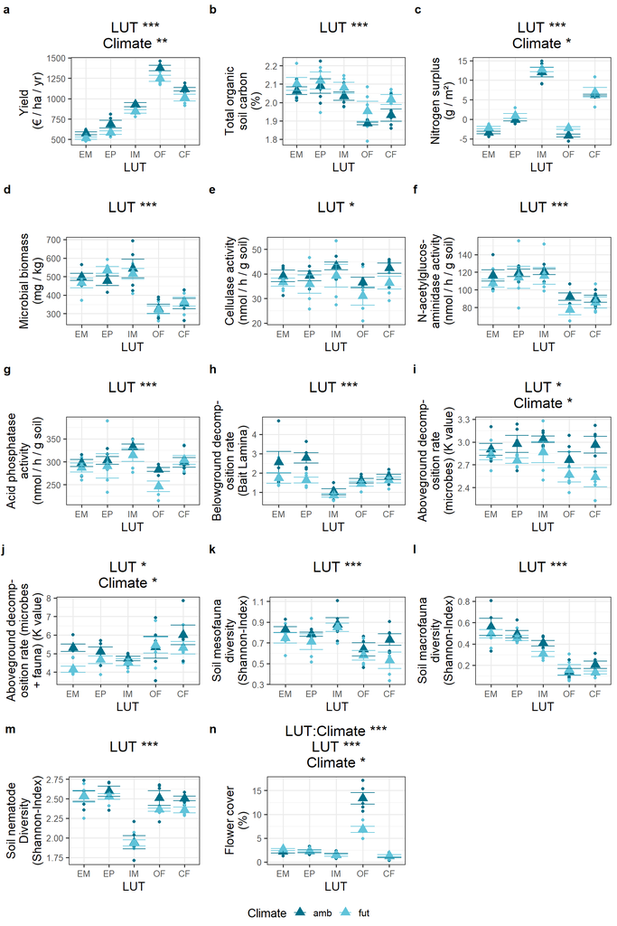

```r
ggarrange(plotlist = lt_performance_meta, ncol = 3, nrow = 5, labels = "auto",common.legend = TRUE, legend = "bottom")
```

Create General linear regression model table of F and p values of the effect of the two treatments on each individual ecosystem function:

```r
table_list_lt <- vector("list", length = 14)

for (a in 1:14){
  table_list_lt[[a]] <- c(round(anova(lmer(mf_data_lt[,(relevant_functions[a]-1)] ~ LUT * Climate + (1 | Mainplot), data = mf_data_lt))$"F value"[1], digits=3),
                          round(anova(lmer(mf_data_lt[,(relevant_functions[a]-1)] ~ LUT * Climate + (1 | Mainplot), data = mf_data_lt))$"Pr(>F)"[1], digits=3),
                          ifelse(anova(lmer(mf_data_lt[,(relevant_functions[a]-1)] ~ LUT * Climate + (1 | Mainplot), data = mf_data_lt))$"Pr(>F)"[1] <= 0.001, "***",
                                 ifelse(anova(lmer(mf_data_lt[,(relevant_functions[a]-1)] ~ LUT * Climate + (1 | Mainplot), data = mf_data_lt))$"Pr(>F)"[1] <= 0.01, "**",
                                        ifelse(anova(lmer(mf_data_lt[,(relevant_functions[a]-1)] ~ LUT * Climate + (1 | Mainplot), data = mf_data_lt))$"Pr(>F)"[1] <= 0.05, "*", ""))),
                          round(anova(lmer(mf_data_lt[,(relevant_functions[a]-1)] ~ LUT * Climate + (1 | Mainplot), data = mf_data_lt))$"F value"[2], digits=3),
                          round(anova(lmer(mf_data_lt[,(relevant_functions[a]-1)] ~ LUT * Climate + (1 | Mainplot), data = mf_data_lt))$"Pr(>F)"[2],digits = 3),
                          ifelse(anova(lmer(mf_data_lt[,(relevant_functions[a]-1)] ~ LUT * Climate + (1 | Mainplot), data = mf_data_lt))$"Pr(>F)"[2] <= 0.001, "***",
                                 ifelse(anova(lmer(mf_data_lt[,(relevant_functions[a]-1)] ~ LUT * Climate + (1 | Mainplot), data = mf_data_lt))$"Pr(>F)"[2] <= 0.01, "**",
                                        ifelse(anova(lmer(mf_data_lt[,(relevant_functions[a]-1)] ~ LUT * Climate + (1 | Mainplot), data = mf_data_lt))$"Pr(>F)"[2] <= 0.05, "*", ""))),
                          round(anova(lmer(mf_data_lt[,(relevant_functions[a]-1)] ~ LUT * Climate + (1 | Mainplot), data = mf_data_lt))$"F value"[3],digits = 3),
                          round(anova(lmer(mf_data_lt[,(relevant_functions[a]-1)] ~ LUT * Climate + (1 | Mainplot), data = mf_data_lt))$"Pr(>F)"[3],digits=3),
                          ifelse(anova(lmer(mf_data_lt[,(relevant_functions[a]-1)] ~ LUT * Climate + (1 | Mainplot), data = mf_data_lt))$"Pr(>F)"[3] <= 0.001, "***",
                                 ifelse(anova(lmer(mf_data_lt[,(relevant_functions[a]-1)] ~ LUT * Climate + (1 | Mainplot), data = mf_data_lt))$"Pr(>F)"[3] <= 0.01, "**",
                                        ifelse(anova(lmer(mf_data_lt[,(relevant_functions[a]-1)] ~ LUT * Climate + (1 | Mainplot), data = mf_data_lt))$"Pr(>F)"[3] <= 0.05, "*", ""))))
}

table_lt <- data.frame(matrix(nrow=13, ncol=9))
colnames(table_lt) <- c("LUT F value", "LUT p value", "LUT sig", "Climate F value", "Climate p value", "Climate sig", "LUT:Climate F value", "LUT:Climate p value", "LUT:Climate sig")

for (i in 1:14){
  table_lt[i,] <- unlist(table_list_lt[i])
}

add_column(table_lt, Function=allVars[1:14], .before=1)
```

```
##               Function LUT F value LUT p value LUT sig Climate F value
## 1                Yield     298.147           0     ***          12.015
## 2                  TOC       11.67           0     ***           4.336
## 3         Nmin_Surplus     213.658           0     ***           5.717
## 4              Mic_Bio      47.251           0     ***               0
## 5                  CEL       3.049       0.031       *           2.265
## 6                  NAG      17.392           0     ***            1.37
## 7                  PHO      10.261           0     ***           1.241
## 8         Decomp_Below      12.605           0     ***           5.186
## 9    Decomp_Above_Fine       2.946       0.035       *           9.069
## 10 Decomp_Above_Coarse       3.498       0.015       *           4.965
## 11         Biodiv_Meso      11.103           0     ***           2.599
## 12        Biodiv_Macro      47.238           0     ***           2.365
## 13     Biodiv_Nematode      35.524           0     ***           3.837
## 14  Percentage_FlowCov     137.935           0     ***           9.564
##    Climate p value Climate sig LUT:Climate F value LUT:Climate p value
## 1            0.008          **               0.495                0.74
## 2            0.071                           0.241               0.913
## 3            0.044           *               0.324                0.86
## 4            0.987                           1.824               0.148
## 5            0.171                           0.199               0.937
## 6            0.276                           0.338               0.851
## 7            0.298                           1.319               0.284
## 8            0.052                           2.503               0.062
## 9            0.017           *               0.991               0.427
## 10           0.032           *               1.027               0.405
## 11           0.146                            1.07               0.388
## 12           0.163                           0.802               0.533
## 13           0.057                           0.701               0.596
## 14           0.015           *               22.04                   0
##    LUT:Climate sig
## 1
## 2
## 3
## 4
## 5
## 6
## 7
## 8
## 9
## 10
## 11
## 12
## 13
## 14             ***
```

```r
write.csv(table_lt,"Table_S3_Regression_table_individual_ecosystem_functions.csv")


# Check the normality of the data using Q-Q Plot (Quantile-Quantile Plot) that compares the quantiles of the residuals against the quantiles of a theoretical normal distribution. If the residuals follow a normal distribution, the points in the Q-Q plot should closely follow a straight line.
# Create a Q-Q plot
#lmm_model <- lmer([Function] ~ LUT * Climate + (1 | Mainplot), data = mf_data_lt)
#qqnorm(residuals(lmm_model))
#qqline(residuals(lmm_model))
```

**Averaging approach:** Normalising the performance of every function based on its (long-term average) min / max values.

```r
temp_vector <- c(1:50)

for (j in 1:length(relevant_functions)){
  for (i in 1:50){
    temp_vector[i] <- (mf_data_lt[,relevant_functions[j]-1][i] - min(mf_data_lt[,relevant_functions[j]-1], na.rm = TRUE)) / (max(mf_data_lt[,relevant_functions[j]-1], na.rm = TRUE) - min(mf_data_lt[,relevant_functions[j]-1], na.rm = TRUE))
    mf_data_lt[,relevant_functions[j]-1+14] <- temp_vector
    names(mf_data_lt)[18+j] <- paste(allVars[j], "_Perf", sep="")
  }
}
# IMPORTANT: As Nirogen surplus is a dys-function, the values are transformed to represent its negative impact in the performance
for (i in 1:50){
  mf_data_lt$Nmin_Surplus_Perf[i]<- 1-(mf_data_lt$Nmin_Surplus[i] - min(mf_data_big$Nmin_Surplus, na.rm = TRUE)) / (max(mf_data_big$Nmin_Surplus, na.rm = TRUE) - min(mf_data_big$Nmin_Surplus, na.rm = TRUE))
}
```

**Calculation of Multidiversity:** From the 3 different classes of soil biodiversity data, soil multidiversity is calculated based on a normalisation according to the respective taxa (or, according to the respective organism size that usually represent certain taxa) following Allan et al. 2014.

```r
for (i in 1:50){
  mf_data_lt$Multidiv[i] <- 1/3*(mf_data_lt$Biodiv_Macro[i]/max(mf_data_big$Biodiv_Macro, na.rm=TRUE))+
    1/3*(mf_data_lt$Biodiv_Meso[i]/max(mf_data_big$Biodiv_Meso, na.rm=TRUE))+
    1/3*(mf_data_lt$Biodiv_Nematode[i]/max(mf_data_big$Biodiv_Nematode, na.rm=TRUE))
}
```

**Calculation of soil health** based on the average performance of the respective / relevant functions:

```r
for (i in 1:50){
  mf_data_lt$Soil_Health[i] <- 1/3*mf_data_lt$Mic_Bio_Perf[i] + 1/9*mf_data_lt$CEL_Perf[i] + 1/9*mf_data_lt$NAG_Perf[i] + 1/9*mf_data_lt$PHO_Perf[i] + 1/9*mf_data_lt$Decomp_Below_Perf[i] + 1/9*mf_data_lt$Decomp_Above_Coarse_Perf[i] + 1/9*mf_data_lt$Decomp_Above_Fine_Perf[i]
}
```

**Calculating of ecosystem multifunctionality (egEMF) using the averaging approach** 4 different weightings scenarios (representing priorities of four different stakeholder groups: farmers, local residents, environmental conservation agencies, tourism sector, derived from the survey of Peter et al., 2021), plus three additional weighting scenarios: an equal weighting of each ecosystem service, an equal weighting of each ecosystem function, and an equal weighting of each ecosystem function excluding the three soil biodiversity functions):

```r
for (i in 1:50){
  mf_data_lt$egEMF_Farmers[i] <- 0.14 * mf_data_lt$Percentage_FlowCov_Perf[i] + 0.17 * mf_data_lt$Multidiv[i] + 0.17 * mf_data_lt$Soil_Health[i] + 0.07 * mf_data_lt$TOC_Perf[i] + 0.07 * mf_data_lt$Nmin_Surplus_Perf[i] + 0.38 * mf_data_lt$Yield_Perf[i]
  mf_data_lt$egEMF_Locals[i] <- 0.22 * mf_data_lt$Percentage_FlowCov_Perf[i] + 0.19 * mf_data_lt$Multidiv[i] + 0.19 * mf_data_lt$Soil_Health[i] + 0.09 * mf_data_lt$TOC_Perf[i] + 0.09 * mf_data_lt$Nmin_Surplus_Perf[i] + 0.22 * mf_data_lt$Yield_Perf[i]
  mf_data_lt$egEMF_Env[i] <- 0.14 * mf_data_lt$Percentage_FlowCov_Perf[i] + 0.24 * mf_data_lt$Multidiv[i] + 0.24 * mf_data_lt$Soil_Health[i] + 0.12 * mf_data_lt$TOC_Perf[i] + 0.12 * mf_data_lt$Nmin_Surplus_Perf[i] + 0.14 * mf_data_lt$Yield_Perf[i]
  mf_data_lt$egEMF_Tourism[i] <- 0.25 * mf_data_lt$Percentage_FlowCov_Perf[i] + 0.21 * mf_data_lt$Multidiv[i] + 0.21 * mf_data_lt$Soil_Health[i] + 0.1 * mf_data_lt$TOC_Perf[i] + 0.1 * mf_data_lt$Nmin_Surplus_Perf[i] + 0.13 * mf_data_lt$Yield_Perf[i]
  mf_data_lt$egEMF_Func[i] <- 1/14* mf_data_lt$Yield_Perf[i] + 1/14* mf_data_lt$TOC_Perf[i] + 1/14* mf_data_lt$Nmin_Surplus_Perf[i] + 1/14* mf_data_lt$Mic_Bio_Perf[i] + 1/14* mf_data_lt$CEL_Perf[i] + 1/14* mf_data_lt$NAG_Perf[i] + 1/14* mf_data_lt$PHO_Perf[i] + 1/14* mf_data_lt$Decomp_Below_Perf[i] + 1/14* mf_data_lt$Decomp_Above_Fine_Perf[i] + 1/14* mf_data_lt$Decomp_Above_Coarse_Perf[i] + 1/14* mf_data_lt$Biodiv_Meso_Perf[i] + 1/14* mf_data_lt$Biodiv_Macro_Perf[i] + 1/14* mf_data_lt$Biodiv_Nematode_Perf[i] + 1/14* mf_data_lt$Percentage_FlowCov_Perf[i]
  mf_data_lt$egEMF_o_Biodiv[i] <- mean(c(mf_data_lt$Yield_Perf[i],
                                      mf_data_lt$TOC_Perf[i],
                                      mf_data_lt$Nmin_Surplus_Perf[i],
                                      mf_data_lt$Mic_Bio_Perf[i],
                                      mf_data_lt$CEL_Perf[i],
                                      mf_data_lt$NAG_Perf[i],
                                      mf_data_lt$PHO_Perf[i],
                                      mf_data_lt$Decomp_Below_Perf[i],
                                      mf_data_lt$Decomp_Above_Coarse_Perf[i],
                                      mf_data_lt$Decomp_Above_Fine_Perf[i],
                                      mf_data_lt$Percentage_FlowCov_Perf[i], na.rm=TRUE))
  mf_data_lt$egEMF_Serv[i] <- 1/6 * mf_data_lt$Percentage_FlowCov_Perf[i] + 1/6 * mf_data_lt$Multidiv[i] + 1/6 * mf_data_lt$Soil_Health[i] + 1/6 * mf_data_lt$TOC_Perf[i] + 1/6 * mf_data_lt$Nmin_Surplus_Perf[i] + 1/6 * mf_data_lt$Yield_Perf[i]
}
```

Visualisation of egEMF performance of the 4 weighting scenarios according to stakeholders priorities in one figure (plus the two additional weighting scenarios equal ecosystem function weighting and equal ecosystem service weighting):

```r
Fig_egEMF_Farmers <- ggplot(aes(y=egEMF_Farmers, x=LUT, color=Climate), data=mf_data_lt)+
  geom_point()+
  scale_colour_manual(values=c("amb" = "#007089", "fut" = "#60c3d9"))+
  ylim(0.3,0.8)+
  stat_summary(
    geom = "point",
    fun.y = "mean",
    size = 5,
    shape = 17)+
  stat_summary(fun.data = mean_se, geom = "errorbar")+ # add errorbar
  ggtitle(paste(paste(paste(ifelse(anova(lmer(egEMF_Farmers ~ LUT * Climate + (1 | Mainplot), data = mf_data_lt))$"Pr(>F)"[3] <= 0.05, "LUT:Climate", ""),
                            ifelse(anova(lmer(egEMF_Farmers ~ LUT * Climate + (1 | Mainplot), data = mf_data_lt))$"Pr(>F)"[3] <= 0.001, "***",
                                   ifelse(anova(lmer(egEMF_Farmers ~ LUT * Climate + (1 | Mainplot), data = mf_data_lt))$"Pr(>F)"[3] <= 0.01, "**",
                                          ifelse(anova(lmer(egEMF_Farmers ~ LUT * Climate + (1 | Mainplot), data = mf_data_lt))$"Pr(>F)"[3] <= 0.05, "*", "")))),  "\n",
                      paste(ifelse(anova(lmer(egEMF_Farmers ~ LUT * Climate + (1 | Mainplot), data = mf_data_lt))$"Pr(>F)"[1] <= 0.05, "LUT", ""),
                            ifelse(anova(lmer(egEMF_Farmers ~ LUT * Climate + (1 | Mainplot), data = mf_data_lt))$"Pr(>F)"[1] <= 0.001, "***",
                                   ifelse(anova(lmer(egEMF_Farmers ~ LUT * Climate + (1 | Mainplot), data = mf_data_lt))$"Pr(>F)"[1] <= 0.01, "**",
                                          ifelse(anova(lmer(egEMF_Farmers ~ LUT * Climate + (1 | Mainplot), data = mf_data_lt))$"Pr(>F)"[1] <= 0.05, "*", ""))),  "\n",
                            sep=" "),paste(ifelse(anova(lmer(egEMF_Farmers ~ LUT * Climate + (1 | Mainplot), data = mf_data_lt))$"Pr(>F)"[2] <= 0.05, "Climate", ""),
                                           ifelse(anova(lmer(egEMF_Farmers ~ LUT * Climate + (1 | Mainplot), data = mf_data_lt))$"Pr(>F)"[2] <= 0.001, "***",
                                                  ifelse(anova(lmer(egEMF_Farmers ~ LUT * Climate + (1 | Mainplot), data = mf_data_lt))$"Pr(>F)"[2] <= 0.01, "**",
                                                         ifelse(anova(lmer(egEMF_Farmers ~ LUT * Climate + (1 | Mainplot), data = mf_data_lt))$"Pr(>F)"[2] <= 0.05, "*", "")))), sep=" ")))+
  ylab("\negEMF\n(farmers' preferences)")+
  theme(text = element_text(size = 22),
        plot.title = element_text(size=18),
        axis.text.y = element_text(size=18),
        axis.text.x = element_text(size=18),
        axis.title.y=element_text(size=17))


Fig_egEMF_Locals <- ggplot(aes(y=egEMF_Locals, x=LUT, color=Climate), data=mf_data_lt)+
  geom_point()+
  scale_colour_manual(values=c("amb" = "#007089", "fut" = "#60c3d9"))+
  ylim(0.3,0.8)+
  stat_summary(
    geom = "point",
    fun.y = "mean",
    size = 5,
    shape = 17)+
  stat_summary(fun.data = mean_se, geom = "errorbar")+ # add errorbar
  ggtitle(paste(paste(paste(ifelse(anova(lmer(egEMF_Locals ~ LUT * Climate + (1 | Mainplot), data = mf_data_lt))$"Pr(>F)"[3] <= 0.05, "LUT:Climate", ""),
                            ifelse(anova(lmer(egEMF_Locals ~ LUT * Climate + (1 | Mainplot), data = mf_data_lt))$"Pr(>F)"[3] <= 0.001, "***",
                                   ifelse(anova(lmer(egEMF_Locals ~ LUT * Climate + (1 | Mainplot), data = mf_data_lt))$"Pr(>F)"[3] <= 0.01, "**",
                                          ifelse(anova(lmer(egEMF_Locals ~ LUT * Climate + (1 | Mainplot), data = mf_data_lt))$"Pr(>F)"[3] <= 0.05, "*", "")))),  "\n",
                      paste(ifelse(anova(lmer(egEMF_Locals ~ LUT * Climate + (1 | Mainplot), data = mf_data_lt))$"Pr(>F)"[1] <= 0.05, "LUT", ""),
                            ifelse(anova(lmer(egEMF_Locals ~ LUT * Climate + (1 | Mainplot), data = mf_data_lt))$"Pr(>F)"[1] <= 0.001, "***",
                                   ifelse(anova(lmer(egEMF_Locals ~ LUT * Climate + (1 | Mainplot), data = mf_data_lt))$"Pr(>F)"[1] <= 0.01, "**",
                                          ifelse(anova(lmer(egEMF_Locals ~ LUT * Climate + (1 | Mainplot), data = mf_data_lt))$"Pr(>F)"[1] <= 0.05, "*", ""))),   "\n",
                            sep=" "),paste(ifelse(anova(lmer(egEMF_Locals ~ LUT * Climate + (1 | Mainplot), data = mf_data_lt))$"Pr(>F)"[2] <= 0.05, "Climate", ""),
                                           ifelse(anova(lmer(egEMF_Locals ~ LUT * Climate + (1 | Mainplot), data = mf_data_lt))$"Pr(>F)"[2] <= 0.001, "***",
                                                  ifelse(anova(lmer(egEMF_Locals ~ LUT * Climate + (1 | Mainplot), data = mf_data_lt))$"Pr(>F)"[2] <= 0.01, "**",
                                                         ifelse(anova(lmer(egEMF_Locals ~ LUT * Climate + (1 | Mainplot), data = mf_data_lt))$"Pr(>F)"[2] <= 0.05, "*", "")))), sep=" ")))+
  ylab("\negEMF\n(locals' preferences)")+
  theme(text = element_text(size = 22),
        plot.title = element_text(size=18),
        axis.text.y = element_text(size=18),
        axis.text.x = element_text(size=18),
        axis.title.y=element_text(size=17))





Fig_egEMF_Env <- ggplot(aes(y=egEMF_Env, x=LUT, color=Climate), data=mf_data_lt)+
  geom_point()+
  scale_colour_manual(values=c("amb" = "#007089", "fut" = "#60c3d9"))+
  ylim(0.3,0.8)+
  stat_summary(
    geom = "point",
    fun.y = "mean",
    size = 5,
    shape = 17)+
  stat_summary(fun.data = mean_se, geom = "errorbar")+ # add errorbar
  ggtitle(paste(paste(paste(ifelse(anova(lmer(egEMF_Env ~ LUT * Climate + (1 | Mainplot), data = mf_data_lt))$"Pr(>F)"[3] <= 0.05, "LUT:Climate", ""),
                            ifelse(anova(lmer(egEMF_Env ~ LUT * Climate + (1 | Mainplot), data = mf_data_lt))$"Pr(>F)"[3] <= 0.001, "***",
                                   ifelse(anova(lmer(egEMF_Env ~ LUT * Climate + (1 | Mainplot), data = mf_data_lt))$"Pr(>F)"[3] <= 0.01, "**",
                                          ifelse(anova(lmer(egEMF_Env ~ LUT * Climate + (1 | Mainplot), data = mf_data_lt))$"Pr(>F)"[3] <= 0.05, "*", "")))),  "\n",
                      paste(ifelse(anova(lmer(egEMF_Env ~ LUT * Climate + (1 | Mainplot), data = mf_data_lt))$"Pr(>F)"[1] <= 0.05, "LUT", ""),
                            ifelse(anova(lmer(egEMF_Env ~ LUT * Climate + (1 | Mainplot), data = mf_data_lt))$"Pr(>F)"[1] <= 0.001, "***",
                                   ifelse(anova(lmer(egEMF_Env ~ LUT * Climate + (1 | Mainplot), data = mf_data_lt))$"Pr(>F)"[1] <= 0.01, "**",
                                          ifelse(anova(lmer(egEMF_Env ~ LUT * Climate + (1 | Mainplot), data = mf_data_lt))$"Pr(>F)"[1] <= 0.05, "*", ""))),  "\n",
                            sep=" "),paste(ifelse(anova(lmer(egEMF_Env ~ LUT * Climate + (1 | Mainplot), data = mf_data_lt))$"Pr(>F)"[2] <= 0.05, "Climate", ""),
                                           ifelse(anova(lmer(egEMF_Env ~ LUT * Climate + (1 | Mainplot), data = mf_data_lt))$"Pr(>F)"[2] <= 0.001, "***",
                                                  ifelse(anova(lmer(egEMF_Env ~ LUT * Climate + (1 | Mainplot), data = mf_data_lt))$"Pr(>F)"[2] <= 0.01, "**",
                                                         ifelse(anova(lmer(egEMF_Env ~ LUT * Climate + (1 | Mainplot), data = mf_data_lt))$"Pr(>F)"[2] <= 0.05, "*", "")))), sep=" ")))+
  ylab("egEMF\n(environmental conservation\nagencies' preferences)")+
  theme(text = element_text(size = 22),
        plot.title = element_text(size=18),
        axis.text.y = element_text(size=18),
        axis.text.x = element_text(size=18),
        axis.title.y=element_text(size=17))
```

```r
Fig_egEMF_Tourism <- ggplot(aes(y=egEMF_Tourism, x=LUT, color=Climate), data=mf_data_lt)+
  geom_point()+
  scale_colour_manual(values=c("amb" = "#007089", "fut" = "#60c3d9"))+
  ylim(0.3,0.8)+
  stat_summary(
    geom = "point",
    fun.y = "mean",
    size = 5,
    shape = 17)+
  stat_summary(fun.data = mean_se, geom = "errorbar")+ # add errorbar
  ggtitle(paste(paste(paste(ifelse(anova(lmer(egEMF_Tourism ~ LUT * Climate + (1 | Mainplot), data = mf_data_lt))$"Pr(>F)"[3] <= 0.05, "LUT:Climate", ""),
                            ifelse(anova(lmer(egEMF_Tourism ~ LUT * Climate + (1 | Mainplot), data = mf_data_lt))$"Pr(>F)"[3] <= 0.001, "***",
                                   ifelse(anova(lmer(egEMF_Tourism ~ LUT * Climate + (1 | Mainplot), data = mf_data_lt))$"Pr(>F)"[3] <= 0.01, "**",
                                          ifelse(anova(lmer(egEMF_Tourism ~ LUT * Climate + (1 | Mainplot), data = mf_data_lt))$"Pr(>F)"[3] <= 0.05, "*", "")))),  "\n",
                      paste(ifelse(anova(lmer(egEMF_Tourism ~ LUT * Climate + (1 | Mainplot), data = mf_data_lt))$"Pr(>F)"[1] <= 0.05, "LUT", ""),
                            ifelse(anova(lmer(egEMF_Tourism ~ LUT * Climate + (1 | Mainplot), data = mf_data_lt))$"Pr(>F)"[1] <= 0.001, "***",
                                   ifelse(anova(lmer(egEMF_Tourism ~ LUT * Climate + (1 | Mainplot), data = mf_data_lt))$"Pr(>F)"[1] <= 0.01, "**",
                                          ifelse(anova(lmer(egEMF_Tourism ~ LUT * Climate + (1 | Mainplot), data = mf_data_lt))$"Pr(>F)"[1] <= 0.05, "*", ""))),  "\n",
                            sep=" "),paste(ifelse(anova(lmer(egEMF_Tourism ~ LUT * Climate + (1 | Mainplot), data = mf_data_lt))$"Pr(>F)"[2] <= 0.05, "Climate", ""),
                                           ifelse(anova(lmer(egEMF_Tourism ~ LUT * Climate + (1 | Mainplot), data = mf_data_lt))$"Pr(>F)"[2] <= 0.001, "***",
                                                  ifelse(anova(lmer(egEMF_Tourism ~ LUT * Climate + (1 | Mainplot), data = mf_data_lt))$"Pr(>F)"[2] <= 0.01, "**",
                                                         ifelse(anova(lmer(egEMF_Tourism ~ LUT * Climate + (1 | Mainplot), data = mf_data_lt))$"Pr(>F)"[2] <= 0.05, "*", "")))), sep=" ")))+
  ylab("egEMF\n(tourism sector's\npreferences)")+
  theme(text = element_text(size = 22),
        plot.title = element_text(size=18),
        axis.text.y = element_text(size=18),
        axis.text.x = element_text(size=18),
        axis.title.y=element_text(size=17))

Figure_3_egEMF <- ggarrange(Fig_egEMF_Farmers, Fig_egEMF_Locals, Fig_egEMF_Env, Fig_egEMF_Tourism, ncol = 2, nrow = 2, labels = "auto", font.label = list(size = 24), common.legend = TRUE, legend = "bottom")

ggsave("Figure_3_egEMF.pdf", Figure_3_egEMF, scale = 1, width = 10, height = 10, dpi=500, units="in")



Fig_egEMF_Func <- ggplot(aes(y=egEMF_Func, x=LUT, color=Climate), data=mf_data_lt)+
  geom_point()+
  scale_colour_manual(values=c("amb" = "#007089", "fut" = "#60c3d9"))+
  ylim(0.3,0.8)+
  stat_summary(
    geom = "point",
    fun.y = "mean",
    size = 5,
    shape = 17)+
  stat_summary(fun.data = mean_se, geom = "errorbar")+ # add errorbar
  ggtitle(paste(paste(paste(ifelse(anova(lmer(egEMF_Func ~ LUT * Climate + (1 | Mainplot), data = mf_data_lt))$"Pr(>F)"[3] <= 0.05, "LUT:Climate", ""),
                            ifelse(anova(lmer(egEMF_Func ~ LUT * Climate + (1 | Mainplot), data = mf_data_lt))$"Pr(>F)"[3] <= 0.001, "***",
                                   ifelse(anova(lmer(egEMF_Func ~ LUT * Climate + (1 | Mainplot), data = mf_data_lt))$"Pr(>F)"[3] <= 0.01, "**",
                                          ifelse(anova(lmer(egEMF_Func ~ LUT * Climate + (1 | Mainplot), data = mf_data_lt))$"Pr(>F)"[3] <= 0.05, "*", "")))),  "\n",
                      paste(ifelse(anova(lmer(egEMF_Func ~ LUT * Climate + (1 | Mainplot), data = mf_data_lt))$"Pr(>F)"[1] <= 0.05, "LUT", ""),
                            ifelse(anova(lmer(egEMF_Func ~ LUT * Climate + (1 | Mainplot), data = mf_data_lt))$"Pr(>F)"[1] <= 0.001, "***",
                                   ifelse(anova(lmer(egEMF_Func ~ LUT * Climate + (1 | Mainplot), data = mf_data_lt))$"Pr(>F)"[1] <= 0.01, "**",
                                          ifelse(anova(lmer(egEMF_Func ~ LUT * Climate + (1 | Mainplot), data = mf_data_lt))$"Pr(>F)"[1] <= 0.05, "*", ""))),  "\n",
                            sep=" "),paste(ifelse(anova(lmer(egEMF_Func ~ LUT * Climate + (1 | Mainplot), data = mf_data_lt))$"Pr(>F)"[2] <= 0.05, "Climate", ""),
                                           ifelse(anova(lmer(egEMF_Func ~ LUT * Climate + (1 | Mainplot), data = mf_data_lt))$"Pr(>F)"[2] <= 0.001, "***",
                                                  ifelse(anova(lmer(egEMF_Func ~ LUT * Climate + (1 | Mainplot), data = mf_data_lt))$"Pr(>F)"[2] <= 0.01, "**",
                                                         ifelse(anova(lmer(egEMF_Func ~ LUT * Climate + (1 | Mainplot), data = mf_data_lt))$"Pr(>F)"[2] <= 0.05, "*", "")))), sep=" ")))+
  ylab("\negEMF (equal ecosystem\nfunction weighting)")+
  theme(text = element_text(size = 22),
        plot.title = element_text(size=18),
        axis.text.y = element_text(size=18),
        axis.text.x = element_text(size=18),
        axis.title.y=element_text(size=17))

Fig_egEMF_Serv <- ggplot(aes(y=egEMF_Serv, x=LUT, color=Climate), data=mf_data_lt)+
  geom_point()+
  scale_colour_manual(values=c("amb" = "#007089", "fut" = "#60c3d9"))+
  ylim(0.3,0.8)+
  stat_summary(
    geom = "point",
    fun.y = "mean",
    size = 5,
    shape = 17)+
  stat_summary(fun.data = mean_se, geom = "errorbar")+ # add errorbar
  ggtitle(paste(paste(paste(ifelse(anova(lmer(egEMF_Serv ~ LUT * Climate + (1 | Mainplot), data = mf_data_lt))$"Pr(>F)"[3] <= 0.05, "LUT:Climate", ""),
                            ifelse(anova(lmer(egEMF_Serv ~ LUT * Climate + (1 | Mainplot), data = mf_data_lt))$"Pr(>F)"[3] <= 0.001, "***",
                                   ifelse(anova(lmer(egEMF_Serv ~ LUT * Climate + (1 | Mainplot), data = mf_data_lt))$"Pr(>F)"[3] <= 0.01, "**",
                                          ifelse(anova(lmer(egEMF_Serv ~ LUT * Climate + (1 | Mainplot), data = mf_data_lt))$"Pr(>F)"[3] <= 0.05, "*", "")))),  "\n",
                      paste(ifelse(anova(lmer(egEMF_Serv ~ LUT * Climate + (1 | Mainplot), data = mf_data_lt))$"Pr(>F)"[1] <= 0.05, "LUT", ""),
                            ifelse(anova(lmer(egEMF_Serv ~ LUT * Climate + (1 | Mainplot), data = mf_data_lt))$"Pr(>F)"[1] <= 0.001, "***",
                                   ifelse(anova(lmer(egEMF_Serv ~ LUT * Climate + (1 | Mainplot), data = mf_data_lt))$"Pr(>F)"[1] <= 0.01, "**",
                                          ifelse(anova(lmer(egEMF_Serv ~ LUT * Climate + (1 | Mainplot), data = mf_data_lt))$"Pr(>F)"[1] <= 0.05, "*", ""))),  "\n",
                            sep=" "),paste(ifelse(anova(lmer(egEMF_Serv ~ LUT * Climate + (1 | Mainplot), data = mf_data_lt))$"Pr(>F)"[2] <= 0.05, "Climate", ""),
                                           ifelse(anova(lmer(egEMF_Serv ~ LUT * Climate + (1 | Mainplot), data = mf_data_lt))$"Pr(>F)"[2] <= 0.001, "***",
                                                  ifelse(anova(lmer(egEMF_Serv ~ LUT * Climate + (1 | Mainplot), data = mf_data_lt))$"Pr(>F)"[2] <= 0.01, "**",
                                                         ifelse(anova(lmer(egEMF_Serv ~ LUT * Climate + (1 | Mainplot), data = mf_data_lt))$"Pr(>F)"[2] <= 0.05, "*", "")))), sep=" ")))+
  ylab("\negEMF (equal ecosystem\nservice weighting)")+
  theme(text = element_text(size = 22),
        plot.title = element_text(size=18),
        axis.text.y = element_text(size=18),
        axis.text.x = element_text(size=18),
        axis.title.y=element_text(size=17))
```

```r
Figure_S2_egEMF_equal_ecosyste_function_and_service_weighting <- ggarrange(Fig_egEMF_Func, Fig_egEMF_Serv, ncol = 2, nrow = 1, labels = "auto", font.label = list(size = 24), common.legend = TRUE, legend = "bottom")

ggsave("Figure_S2_egEMF_equal_ecosyste_function_and_service_weighting.pdf", Figure_S2_egEMF_equal_ecosyste_function_and_service_weighting, scale = 1, width = 10, height = 5, dpi=500, units="in")
```

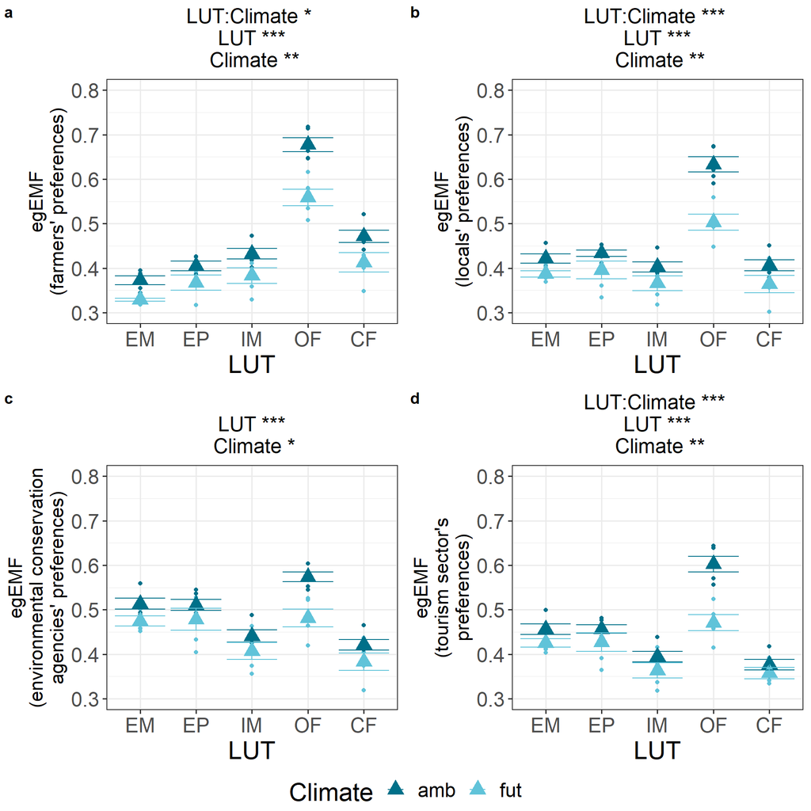

```r
ggarrange(Fig_egEMF_Farmers, Fig_egEMF_Locals, Fig_egEMF_Env, Fig_egEMF_Tourism, ncol = 2, nrow = 2, labels = "auto",common.legend = TRUE, legend = "bottom")
```

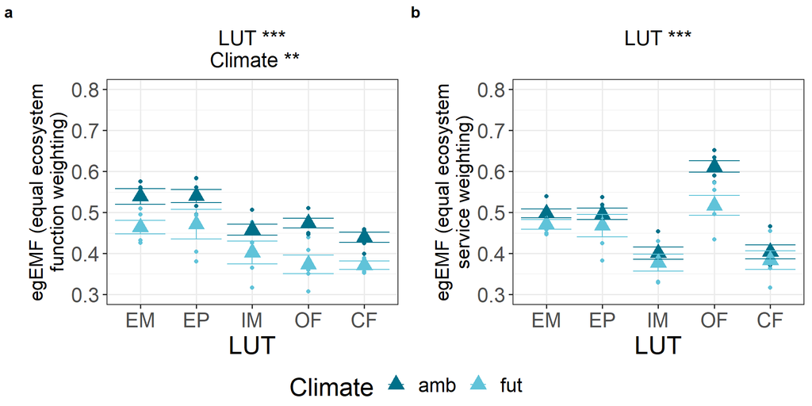

```r
ggarrange(Fig_egEMF_Func, Fig_egEMF_Serv, ncol = 2, nrow = 1, labels = "auto",common.legend = TRUE, legend = "bottom")
```

Create General linear regression model table of F and p values of the effect of the two treatments on ecological ecosystem multifunctionality egEMF for each of the six weighting scenarios:

```r
Reg_table_egEMF_Farmers <- c(round(anova(lmer(egEMF_Farmers ~ LUT * Climate + (1 | Mainplot), data = mf_data_lt))$"F value"[1], digits=3),
                              anova(lmer(egEMF_Farmers ~ LUT * Climate + (1 | Mainplot), data = mf_data_lt))$"Pr(>F)"[1],
                              ifelse(anova(lmer(egEMF_Farmers ~ LUT * Climate + (1 | Mainplot), data = mf_data_lt))$"Pr(>F)"[1] <= 0.001, "***",
                                     ifelse(anova(lmer(egEMF_Farmers ~ LUT * Climate + (1 | Mainplot), data = mf_data_lt))$"Pr(>F)"[1] <= 0.01, "**",
                                            ifelse(anova(lmer(egEMF_Farmers ~ LUT * Climate + (1 | Mainplot), data = mf_data_lt))$"Pr(>F)"[1] <= 0.05, "*", ""))),
                              round(anova(lmer(egEMF_Farmers ~ LUT * Climate + (1 | Mainplot), data = mf_data_lt))$"F value"[2], digits=3),
                              round(anova(lmer(egEMF_Farmers ~ LUT * Climate + (1 | Mainplot), data = mf_data_lt))$"Pr(>F)"[2],digits = 3),
                              ifelse(anova(lmer(egEMF_Farmers ~ LUT * Climate + (1 | Mainplot), data = mf_data_lt))$"Pr(>F)"[2] <= 0.001, "***",
                                     ifelse(anova(lmer(egEMF_Farmers ~ LUT * Climate + (1 | Mainplot), data = mf_data_lt))$"Pr(>F)"[2] <= 0.01, "**",
                                            ifelse(anova(lmer(egEMF_Farmers ~ LUT * Climate + (1 | Mainplot), data = mf_data_lt))$"Pr(>F)"[2] <= 0.05, "*", ""))),
                              round(anova(lmer(egEMF_Farmers ~ LUT * Climate + (1 | Mainplot), data = mf_data_lt))$"F value"[3],digits = 3),
                              round(anova(lmer(egEMF_Farmers ~ LUT * Climate + (1 | Mainplot), data = mf_data_lt))$"Pr(>F)"[3],digits=3),
                              ifelse(anova(lmer(egEMF_Farmers ~ LUT * Climate + (1 | Mainplot), data = mf_data_lt))$"Pr(>F)"[3] <= 0.001, "***",
                                     ifelse(anova(lmer(egEMF_Farmers ~ LUT * Climate + (1 | Mainplot), data = mf_data_lt))$"Pr(>F)"[3] <= 0.01, "**",
                                            ifelse(anova(lmer(egEMF_Farmers ~ LUT * Climate + (1 | Mainplot), data = mf_data_lt))$"Pr(>F)"[3] <= 0.05, "*", ""))))



Reg_table_egEMF_Locals <- c(round(anova(lmer(egEMF_Locals ~ LUT * Climate + (1 | Mainplot), data = mf_data_lt))$"F value"[1], digits=3),
                                 round(anova(lmer(egEMF_Locals ~ LUT * Climate + (1 | Mainplot), data = mf_data_lt))$"Pr(>F)"[1], digits=3),
                                 ifelse(anova(lmer(egEMF_Locals ~ LUT * Climate + (1 | Mainplot), data = mf_data_lt))$"Pr(>F)"[1] <= 0.001, "***",
                                        ifelse(anova(lmer(egEMF_Locals ~ LUT * Climate + (1 | Mainplot), data = mf_data_lt))$"Pr(>F)"[1] <= 0.01, "**",
                                               ifelse(anova(lmer(egEMF_Locals ~ LUT * Climate + (1 | Mainplot), data = mf_data_lt))$"Pr(>F)"[1] <= 0.05, "*", ""))),
                                 round(anova(lmer(egEMF_Locals ~ LUT * Climate + (1 | Mainplot), data = mf_data_lt))$"F value"[2], digits=3),
                                 round(anova(lmer(egEMF_Locals ~ LUT * Climate + (1 | Mainplot), data = mf_data_lt))$"Pr(>F)"[2],digits = 3),
                                 ifelse(anova(lmer(egEMF_Locals ~ LUT * Climate + (1 | Mainplot), data = mf_data_lt))$"Pr(>F)"[2] <= 0.001, "***",
                                        ifelse(anova(lmer(egEMF_Locals ~ LUT * Climate + (1 | Mainplot), data = mf_data_lt))$"Pr(>F)"[2] <= 0.01, "**",
                                               ifelse(anova(lmer(egEMF_Locals ~ LUT * Climate + (1 | Mainplot), data = mf_data_lt))$"Pr(>F)"[2] <= 0.05, "*", ""))),
                                 round(anova(lmer(egEMF_Locals ~ LUT * Climate + (1 | Mainplot), data = mf_data_lt))$"F value"[3],digits = 3),
                                 round(anova(lmer(egEMF_Locals ~ LUT * Climate + (1 | Mainplot), data = mf_data_lt))$"Pr(>F)"[3],digits=3),
                                 ifelse(anova(lmer(egEMF_Locals ~ LUT * Climate + (1 | Mainplot), data = mf_data_lt))$"Pr(>F)"[3] <= 0.001, "***",
                                        ifelse(anova(lmer(egEMF_Locals ~ LUT * Climate + (1 | Mainplot), data = mf_data_lt))$"Pr(>F)"[3] <= 0.01, "**",
                                               ifelse(anova(lmer(egEMF_Locals ~ LUT * Climate + (1 | Mainplot), data = mf_data_lt))$"Pr(>F)"[3] <= 0.05, "*", ""))))


Reg_table_egEMF_Env <- c(round(anova(lmer(egEMF_Env ~ LUT * Climate + (1 | Mainplot), data = mf_data_lt))$"F value"[1], digits=3),
                                 round(anova(lmer(egEMF_Env ~ LUT * Climate + (1 | Mainplot), data = mf_data_lt))$"Pr(>F)"[1], digits=3),
                                 ifelse(anova(lmer(egEMF_Env ~ LUT * Climate + (1 | Mainplot), data = mf_data_lt))$"Pr(>F)"[1] <= 0.001, "***",
                                        ifelse(anova(lmer(egEMF_Env ~ LUT * Climate + (1 | Mainplot), data = mf_data_lt))$"Pr(>F)"[1] <= 0.01, "**",
                                               ifelse(anova(lmer(egEMF_Env ~ LUT * Climate + (1 | Mainplot), data = mf_data_lt))$"Pr(>F)"[1] <= 0.05, "*", ""))),
                                 round(anova(lmer(egEMF_Env ~ LUT * Climate + (1 | Mainplot), data = mf_data_lt))$"F value"[2], digits=3),
                                 round(anova(lmer(egEMF_Env ~ LUT * Climate + (1 | Mainplot), data = mf_data_lt))$"Pr(>F)"[2],digits = 3),
                                 ifelse(anova(lmer(egEMF_Env ~ LUT * Climate + (1 | Mainplot), data = mf_data_lt))$"Pr(>F)"[2] <= 0.001, "***",
                                        ifelse(anova(lmer(egEMF_Env ~ LUT * Climate + (1 | Mainplot), data = mf_data_lt))$"Pr(>F)"[2] <= 0.01, "**",
                                               ifelse(anova(lmer(egEMF_Env ~ LUT * Climate + (1 | Mainplot), data = mf_data_lt))$"Pr(>F)"[2] <= 0.05, "*", ""))),
                                 round(anova(lmer(egEMF_Env ~ LUT * Climate + (1 | Mainplot), data = mf_data_lt))$"F value"[3],digits = 3),
                                 round(anova(lmer(egEMF_Env ~ LUT * Climate + (1 | Mainplot), data = mf_data_lt))$"Pr(>F)"[3],digits=3),
                                 ifelse(anova(lmer(egEMF_Env ~ LUT * Climate + (1 | Mainplot), data = mf_data_lt))$"Pr(>F)"[3] <= 0.001, "***",
                                        ifelse(anova(lmer(egEMF_Env ~ LUT * Climate + (1 | Mainplot), data = mf_data_lt))$"Pr(>F)"[3] <= 0.01, "**",
                                               ifelse(anova(lmer(egEMF_Env ~ LUT * Climate + (1 | Mainplot), data = mf_data_lt))$"Pr(>F)"[3] <= 0.05, "*", ""))))
```

```r
Reg_table_egEMF_Tourism <- c(round(anova(lmer(egEMF_Tourism ~ LUT * Climate + (1 | Mainplot), data = mf_data_lt))$"F value"[1], digits=3),
                             round(anova(lmer(egEMF_Tourism ~ LUT * Climate + (1 | Mainplot), data = mf_data_lt))$"Pr(>F)"[1], digits=3),
                             ifelse(anova(lmer(egEMF_Tourism ~ LUT * Climate + (1 | Mainplot), data = mf_data_lt))$"Pr(>F)"[1] <= 0.001, "***",
                                    ifelse(anova(lmer(egEMF_Tourism ~ LUT * Climate + (1 | Mainplot), data = mf_data_lt))$"Pr(>F)"[1] <= 0.01, "**",
                                           ifelse(anova(lmer(egEMF_Tourism ~ LUT * Climate + (1 | Mainplot), data = mf_data_lt))$"Pr(>F)"[1] <= 0.05, "*", ""))),
                             round(anova(lmer(egEMF_Tourism ~ LUT * Climate + (1 | Mainplot), data = mf_data_lt))$"F value"[2], digits=3),
                             round(anova(lmer(egEMF_Tourism ~ LUT * Climate + (1 | Mainplot), data = mf_data_lt))$"Pr(>F)"[2],digits = 3),
                             ifelse(anova(lmer(egEMF_Tourism ~ LUT * Climate + (1 | Mainplot), data = mf_data_lt))$"Pr(>F)"[2] <= 0.001, "***",
                                    ifelse(anova(lmer(egEMF_Tourism ~ LUT * Climate + (1 | Mainplot), data = mf_data_lt))$"Pr(>F)"[2] <= 0.01, "**",
                                           ifelse(anova(lmer(egEMF_Tourism ~ LUT * Climate + (1 | Mainplot), data = mf_data_lt))$"Pr(>F)"[2] <= 0.05, "*", ""))),
                             round(anova(lmer(egEMF_Tourism ~ LUT * Climate + (1 | Mainplot), data = mf_data_lt))$"F value"[3],digits = 3),
                             round(anova(lmer(egEMF_Tourism ~ LUT * Climate + (1 | Mainplot), data = mf_data_lt))$"Pr(>F)"[3],digits=3),
                             ifelse(anova(lmer(egEMF_Tourism ~ LUT * Climate + (1 | Mainplot), data = mf_data_lt))$"Pr(>F)"[3] <= 0.001, "***",
                                    ifelse(anova(lmer(egEMF_Tourism ~ LUT * Climate + (1 | Mainplot), data = mf_data_lt))$"Pr(>F)"[3] <= 0.01, "**",
                                           ifelse(anova(lmer(egEMF_Tourism ~ LUT * Climate + (1 | Mainplot), data = mf_data_lt))$"Pr(>F)"[3] <= 0.05, "*", ""))))


Reg_table_egEMF_Func <- c(round(anova(lmer(egEMF_Func ~ LUT * Climate + (1 | Mainplot), data = mf_data_lt))$"F value"[1], digits=3),
                              round(anova(lmer(egEMF_Func ~ LUT * Climate + (1 | Mainplot), data = mf_data_lt))$"Pr(>F)"[1], digits=3),
                              ifelse(anova(lmer(egEMF_Func ~ LUT * Climate + (1 | Mainplot), data = mf_data_lt))$"Pr(>F)"[1] <= 0.001, "***",
                                     ifelse(anova(lmer(egEMF_Func ~ LUT * Climate + (1 | Mainplot), data = mf_data_lt))$"Pr(>F)"[1] <= 0.01, "**",
                                            ifelse(anova(lmer(egEMF_Func ~ LUT * Climate + (1 | Mainplot), data = mf_data_lt))$"Pr(>F)"[1] <= 0.05, "*", ""))),
                              round(anova(lmer(egEMF_Func ~ LUT * Climate + (1 | Mainplot), data = mf_data_lt))$"F value"[2], digits=3),
                              round(anova(lmer(egEMF_Func ~ LUT * Climate + (1 | Mainplot), data = mf_data_lt))$"Pr(>F)"[2],digits = 3),
                              ifelse(anova(lmer(egEMF_Func ~ LUT * Climate + (1 | Mainplot), data = mf_data_lt))$"Pr(>F)"[2] <= 0.001, "***",
                                     ifelse(anova(lmer(egEMF_Func ~ LUT * Climate + (1 | Mainplot), data = mf_data_lt))$"Pr(>F)"[2] <= 0.01, "**",
                                            ifelse(anova(lmer(egEMF_Func ~ LUT * Climate + (1 | Mainplot), data = mf_data_lt))$"Pr(>F)"[2] <= 0.05, "*", ""))),
                              round(anova(lmer(egEMF_Func ~ LUT * Climate + (1 | Mainplot), data = mf_data_lt))$"F value"[3],digits = 3),
                              round(anova(lmer(egEMF_Func ~ LUT * Climate + (1 | Mainplot), data = mf_data_lt))$"Pr(>F)"[3],digits=3),
                              ifelse(anova(lmer(egEMF_Func ~ LUT * Climate + (1 | Mainplot), data = mf_data_lt))$"Pr(>F)"[3] <= 0.001, "***",
                                     ifelse(anova(lmer(egEMF_Func ~ LUT * Climate + (1 | Mainplot), data = mf_data_lt))$"Pr(>F)"[3] <= 0.01, "**",
                                            ifelse(anova(lmer(egEMF_Func ~ LUT * Climate + (1 | Mainplot), data = mf_data_lt))$"Pr(>F)"[3] <= 0.05, "*", ""))))



Reg_table_egEMF_Serv <- c(round(anova(lmer(egEMF_Serv ~ LUT * Climate + (1 | Mainplot), data = mf_data_lt))$"F value"[1], digits=3),
                              round(anova(lmer(egEMF_Serv ~ LUT * Climate + (1 | Mainplot), data = mf_data_lt))$"Pr(>F)"[1], digits=3),
                              ifelse(anova(lmer(egEMF_Serv ~ LUT * Climate + (1 | Mainplot), data = mf_data_lt))$"Pr(>F)"[1] <= 0.001, "***",
                                     ifelse(anova(lmer(egEMF_Serv ~ LUT * Climate + (1 | Mainplot), data = mf_data_lt))$"Pr(>F)"[1] <= 0.01, "**",
                                            ifelse(anova(lmer(egEMF_Serv ~ LUT * Climate + (1 | Mainplot), data = mf_data_lt))$"Pr(>F)"[1] <= 0.05, "*", ""))),
                              round(anova(lmer(egEMF_Serv ~ LUT * Climate + (1 | Mainplot), data = mf_data_lt))$"F value"[2], digits=3),
                              round(anova(lmer(egEMF_Serv ~ LUT * Climate + (1 | Mainplot), data = mf_data_lt))$"Pr(>F)"[2],digits = 3),
                              ifelse(anova(lmer(egEMF_Serv ~ LUT * Climate + (1 | Mainplot), data = mf_data_lt))$"Pr(>F)"[2] <= 0.001, "***",
                                     ifelse(anova(lmer(egEMF_Serv ~ LUT * Climate + (1 | Mainplot), data = mf_data_lt))$"Pr(>F)"[2] <= 0.01, "**",
                                            ifelse(anova(lmer(egEMF_Serv ~ LUT * Climate + (1 | Mainplot), data = mf_data_lt))$"Pr(>F)"[2] <= 0.05, "*", ""))),
                              round(anova(lmer(egEMF_Serv ~ LUT * Climate + (1 | Mainplot), data = mf_data_lt))$"F value"[3],digits = 3),
                              round(anova(lmer(egEMF_Serv ~ LUT * Climate + (1 | Mainplot), data = mf_data_lt))$"Pr(>F)"[3],digits=3),
                              ifelse(anova(lmer(egEMF_Serv ~ LUT * Climate + (1 | Mainplot), data = mf_data_lt))$"Pr(>F)"[3] <= 0.001, "***",
                                     ifelse(anova(lmer(egEMF_Serv ~ LUT * Climate + (1 | Mainplot), data = mf_data_lt))$"Pr(>F)"[3] <= 0.01, "**",
                                            ifelse(anova(lmer(egEMF_Serv ~ LUT * Climate + (1 | Mainplot), data = mf_data_lt))$"Pr(>F)"[3] <= 0.05, "*", ""))))
```

```r
Reg_table_egEMF <- data.frame(matrix(nrow=1, ncol=10))
colnames(Reg_table_egEMF) <- c("Weighting_Scenario", "LUT F value", "LUT p value", "LUT sig", "Climate F value", "Climate p value", "Climate sig", "LUT:Climate F value", "LUT:Climate p value", "LUT:Climate sig")
Reg_table_egEMF[1,2:10] <- Reg_table_egEMF_Farmers
Reg_table_egEMF[2,2:10] <- Reg_table_egEMF_Locals
Reg_table_egEMF[3,2:10] <- Reg_table_egEMF_Env
Reg_table_egEMF[4,2:10] <- Reg_table_egEMF_Tourism
Reg_table_egEMF$Weighting_Scenario <- c("Farmers", "Local residents", "Environmental conservation agencies", "Tourism sector")

write.csv(Reg_table_egEMF, "Table_S4_Regression_table_egEMF.csv")
Reg_table_egEMF
```

```
##                    Weighting_Scenario LUT F value          LUT p value LUT sig
## 1                             Farmers     140.798 7.86674889321747e-20     ***
## 2                     Local residents      84.727                    0     ***
## 3 Environmental conservation agencies      29.306                    0     ***
## 4                      Tourism sector      62.927                    0     ***
##   Climate F value Climate p value Climate sig LUT:Climate F value
## 1          19.047           0.002          **               2.961
## 2          15.049           0.005          **               6.036
## 3           9.955           0.013           *               1.692
## 4           12.34           0.008          **               6.606
##   LUT:Climate p value LUT:Climate sig
## 1               0.035               *
## 2               0.001             ***
## 3               0.176
## 4               0.001             ***
```

```r
Reg_table_egEMF_equal_function_service_weighting <- data.frame(matrix(nrow=1, ncol=10))
colnames(Reg_table_egEMF_equal_function_service_weighting) <- c("Weighting_Scenario", "LUT F value", "LUT p value", "LUT sig", "Climate F value", "Climate p value", "Climate sig", "LUT:Climate F value", "LUT:Climate p value", "LUT:Climate sig")
Reg_table_egEMF_equal_function_service_weighting[1,2:10] <- Reg_table_egEMF_Func
Reg_table_egEMF_equal_function_service_weighting[2,2:10] <- Reg_table_egEMF_Serv
Reg_table_egEMF_equal_function_service_weighting$Weighting_Scenario <- c("Equal function weighting", "Equal service weighting")

write.csv(Reg_table_egEMF_equal_function_service_weighting, "Table_S2_Regression_table_egEMF_equal_function_service_weighting.csv")
Reg_table_egEMF_equal_function_service_weighting
```

```
##         Weighting_Scenario LUT F value LUT p value LUT sig Climate F value
## 1 Equal function weighting      14.066           0     ***          18.698
## 2  Equal service weighting      46.268           0     ***           4.707
##   Climate p value Climate sig LUT:Climate F value LUT:Climate p value
## 1           0.003          **               0.423               0.791
## 2           0.062                           2.176               0.094
##   LUT:Climate sig
## 1
## 2
```

** Tukey post hoc analysis of anova results **

```r
# Check for interaction effect
anova(lmer(egEMF_Farmers ~ LUT * Climate + (1 | Mainplot), data = mf_data_lt))
```

```
## Type III Analysis of Variance Table with Satterthwaite's method
##              Sum Sq  Mean Sq NumDF DenDF  F value    Pr(>F)
## LUT         0.44626 0.111566     4    32 140.7977 < 2.2e-16 ***
## Climate     0.01509 0.015093     1     8  19.0472  0.002399 **
## LUT:Climate 0.00938 0.002346     4    32   2.9606  0.034528 *
## ---
## Signif. codes:  0 '***' 0.001 '**' 0.01 '*' 0.05 '.' 0.1 ' ' 1
```

```r
anova(lmer(egEMF_Locals ~ LUT * Climate + (1 | Mainplot), data = mf_data_lt))
```

```
## Type III Analysis of Variance Table with Satterthwaite's method
##               Sum Sq  Mean Sq NumDF DenDF F value    Pr(>F)
## LUT         0.240523 0.060131     4    32 84.7268 < 2.2e-16 ***
## Climate     0.010680 0.010680     1     8 15.0490 0.0046794 **
## LUT:Climate 0.017135 0.004284     4    32  6.0359 0.0009776 ***
## ---
## Signif. codes:  0 '***' 0.001 '**' 0.01 '*' 0.05 '.' 0.1 ' ' 1
```

```r
anova(lmer(egEMF_Env ~ LUT * Climate + (1 | Mainplot), data = mf_data_lt))
```

```
## Type III Analysis of Variance Table with Satterthwaite's method
##               Sum Sq   Mean Sq NumDF DenDF F value    Pr(>F)
## LUT         0.112199 0.0280497     4    32 29.3057 2.714e-10 ***
## Climate     0.009528 0.0095281     1     8  9.9547   0.01349 *
## LUT:Climate 0.006479 0.0016197     4    32  1.6922   0.17608
## ---
## Signif. codes:  0 '***' 0.001 '**' 0.01 '*' 0.05 '.' 0.1 ' ' 1
```

```r
anova(lmer(egEMF_Tourism ~ LUT * Climate + (1 | Mainplot), data = mf_data_lt))
```

```
## Type III Analysis of Variance Table with Satterthwaite's method
##               Sum Sq  Mean Sq NumDF DenDF F value    Pr(>F)
## LUT         0.191769 0.047942     4    32 62.9267 1.043e-14 ***
## Climate     0.009401 0.009401     1     8 12.3397 0.0079291 **
## LUT:Climate 0.020133 0.005033     4    32  6.6063 0.0005402 ***
## ---
## Signif. codes:  0 '***' 0.001 '**' 0.01 '*' 0.05 '.' 0.1 ' ' 1
```

```r
# The models reveal an LUT:Climate interaction effect for weighting according to preferences of Farmers, Local Residents, and the Tourism sector.
# Tukey post hoc analysis is performed and visualised in an effect matrix accordingly (comparing all LUT:Climate combination with each other for weighting scenarios with interaction effect; comparing only all LUT types with each other for weighting scenarios without a significant interaction effect)

model_egEMF_Farmers <- lmer(egEMF_Farmers ~ LUT + Climate + (1 | Mainplot), data = mf_data_lt)
model_egEMF_Locals <- lmer(egEMF_Locals ~ LUT * Climate + (1 | Mainplot), data = mf_data_lt)
model_egEMF_Env <- lmer(egEMF_Env ~ LUT + Climate + (1 | Mainplot), data = mf_data_lt) # adapted model (+ instead of *)
model_egEMF_Tourism <- lmer(egEMF_Tourism ~ LUT * Climate + (1 | Mainplot), data = mf_data_lt)


# Obtain the estimated marginal means (EMMs)
emm_Farmers <- lsmeans(model_egEMF_Farmers, ~ LUT * Climate)
emm_Locals <- lsmeans(model_egEMF_Locals, ~ LUT * Climate)
emm_Env <- lsmeans(model_egEMF_Env, ~ LUT) # only for LUTs (Climate removed)
emm_Tourism <- lsmeans(model_egEMF_Tourism, ~ LUT * Climate)


# Perform pairwise comparisons
pairwise_comp_Farmers <- pairs(emm_Farmers, adjust = "tukey")
pairwise_comp_Locals <- pairs(emm_Locals, adjust = "tukey")
pairwise_comp_Env <- pairs(emm_Env, adjust = "tukey")
pairwise_comp_Tourism <- pairs(emm_Tourism, adjust = "tukey")


summary(pairwise_comp_Farmers)
```

```
##  contrast         estimate     SE   df t.ratio p.value
##  EM amb - EP amb -0.027489 0.0139 36.0  -1.979 0.6183
##  EM amb - IM amb -0.057079 0.0139 36.0  -4.109 0.0073
##  EM amb - OF amb -0.267601 0.0139 36.0 -19.262 <.0001
##  EM amb - CF amb -0.091206 0.0139 36.0  -6.565 <.0001
##  EM amb - EM fut  0.064506 0.0148  8.0   4.364 0.0402
##  EM amb - EP fut  0.037017 0.0203 24.2   1.825 0.7145
##  EM amb - IM fut  0.007427 0.0203 24.2   0.366 1.0000
##  EM amb - OF fut -0.203096 0.0203 24.2 -10.012 <.0001
##  EM amb - CF fut -0.026701 0.0203 24.2  -1.316 0.9400
##  EP amb - IM amb -0.029590 0.0139 36.0  -2.130 0.5198
##  EP amb - OF amb -0.240112 0.0139 36.0 -17.284 <.0001
##  EP amb - CF amb -0.063718 0.0139 36.0  -4.587 0.0019
##  EP amb - EM fut  0.091995 0.0203 24.2   4.535 0.0043
##  EP amb - EP fut  0.064506 0.0148  8.0   4.364 0.0402
##  EP amb - IM fut  0.034916 0.0203 24.2   1.721 0.7736
##  EP amb - OF fut -0.175607 0.0203 24.2  -8.657 <.0001
##  EP amb - CF fut  0.000788 0.0203 24.2   0.039 1.0000
##  IM amb - OF amb -0.210523 0.0139 36.0 -15.154 <.0001
##  IM amb - CF amb -0.034128 0.0139 36.0  -2.457 0.3247
##  IM amb - EM fut  0.121584 0.0203 24.2   5.994 0.0001
##  IM amb - EP fut  0.094095 0.0203 24.2   4.639 0.0033
##  IM amb - IM fut  0.064506 0.0148  8.0   4.364 0.0402
##  IM amb - OF fut -0.146017 0.0203 24.2  -7.198 <.0001
##  IM amb - CF fut  0.030378 0.0203 24.2   1.498 0.8804
##  OF amb - CF amb  0.176395 0.0139 36.0  12.697 <.0001
##  OF amb - EM fut  0.332107 0.0203 24.2  16.373 <.0001
##  OF amb - EP fut  0.304618 0.0203 24.2  15.017 <.0001
##  OF amb - IM fut  0.275028 0.0203 24.2  13.559 <.0001
##  OF amb - OF fut  0.064506 0.0148  8.0   4.364 0.0402
##  OF amb - CF fut  0.240900 0.0203 24.2  11.876 <.0001
##  CF amb - EM fut  0.155712 0.0203 24.2   7.676 <.0001
##  CF amb - EP fut  0.128223 0.0203 24.2   6.321 0.0001
##  CF amb - IM fut  0.098634 0.0203 24.2   4.863 0.0019
##  CF amb - OF fut -0.111889 0.0203 24.2  -5.516 0.0004
##  CF amb - CF fut  0.064506 0.0148  8.0   4.364 0.0402
##  EM fut - EP fut -0.027489 0.0139 36.0  -1.979 0.6183
##  EM fut - IM fut -0.057079 0.0139 36.0  -4.109 0.0073
##  EM fut - OF fut -0.267601 0.0139 36.0 -19.262 <.0001
##  EM fut - CF fut -0.091206 0.0139 36.0  -6.565 <.0001
##  EP fut - IM fut -0.029590 0.0139 36.0  -2.130 0.5198
##  EP fut - OF fut -0.240112 0.0139 36.0 -17.284 <.0001
##  EP fut - CF fut -0.063718 0.0139 36.0  -4.587 0.0019
##  IM fut - OF fut -0.210523 0.0139 36.0 -15.154 <.0001
##  IM fut - CF fut -0.034128 0.0139 36.0  -2.457 0.3247
##  OF fut - CF fut  0.176395 0.0139 36.0  12.697 <.0001
##
## Degrees-of-freedom method: kenward-roger
## P value adjustment: tukey method for comparing a family of 10 estimates
```

```r
summary(pairwise_comp_Locals)
```

```
##  contrast        estimate     SE   df t.ratio p.value
##  EM amb - EP amb -0.01178 0.0168 32.0  -0.699 0.9993
##  EM amb - IM amb  0.01890 0.0168 32.0   1.122 0.9786
##  EM amb - OF amb -0.21161 0.0168 32.0 -12.559 <.0001
##  EM amb - CF amb  0.01515 0.0168 32.0   0.899 0.9954
##  EM amb - EM fut  0.03437 0.0209 26.9   1.647 0.8138
##  EM amb - EP fut  0.02547 0.0209 26.9   1.221 0.9623
##  EM amb - IM fut  0.05547 0.0209 26.9   2.658 0.2401
##  EM amb - OF fut -0.08172 0.0209 26.9  -3.916 0.0165
##  EM amb - CF fut  0.05706 0.0209 26.9   2.735 0.2099
##  EP amb - IM amb  0.03068 0.0168 32.0   1.821 0.7180
##  EP amb - OF amb -0.19983 0.0168 32.0 -11.860 <.0001
##  EP amb - CF amb  0.02693 0.0168 32.0   1.598 0.8393
##  EP amb - EM fut  0.04614 0.0209 26.9   2.211 0.4734
##  EP amb - EP fut  0.03725 0.0209 26.9   1.785 0.7384
##  EP amb - IM fut  0.06725 0.0209 26.9   3.223 0.0804
##  EP amb - OF fut -0.06995 0.0209 26.9  -3.352 0.0608
##  EP amb - CF fut  0.06884 0.0209 26.9   3.299 0.0682
##  IM amb - OF amb -0.23051 0.0168 32.0 -13.681 <.0001
##  IM amb - CF amb -0.00375 0.0168 32.0  -0.223 1.0000
##  IM amb - EM fut  0.01547 0.0209 26.9   0.741 0.9989
##  IM amb - EP fut  0.00657 0.0209 26.9   0.315 1.0000
##  IM amb - IM fut  0.03657 0.0209 26.9   1.753 0.7570
##  IM amb - OF fut -0.10062 0.0209 26.9  -4.822 0.0017
##  IM amb - CF fut  0.03816 0.0209 26.9   1.829 0.7125
##  OF amb - CF amb  0.22676 0.0168 32.0  13.458 <.0001
##  OF amb - EM fut  0.24597 0.0209 26.9  11.787 <.0001
##  OF amb - EP fut  0.23708 0.0209 26.9  11.361 <.0001
##  OF amb - IM fut  0.26708 0.0209 26.9  12.798 <.0001
##  OF amb - OF fut  0.12988 0.0209 26.9   6.224 <.0001
##  OF amb - CF fut  0.26867 0.0209 26.9  12.875 <.0001
##  CF amb - EM fut  0.01922 0.0209 26.9   0.921 0.9943
##  CF amb - EP fut  0.01032 0.0209 26.9   0.495 1.0000
##  CF amb - IM fut  0.04032 0.0209 26.9   1.932 0.6489
##  CF amb - OF fut -0.09687 0.0209 26.9  -4.642 0.0027
##  CF amb - CF fut  0.04191 0.0209 26.9   2.009 0.6007
##  EM fut - EP fut -0.00889 0.0168 32.0  -0.528 0.9999
##  EM fut - IM fut  0.02110 0.0168 32.0   1.253 0.9571
##  EM fut - OF fut -0.11609 0.0168 32.0  -6.890 <.0001
##  EM fut - CF fut  0.02270 0.0168 32.0   1.347 0.9342
##  EP fut - IM fut  0.03000 0.0168 32.0   1.781 0.7419
##  EP fut - OF fut -0.10720 0.0168 32.0  -6.362 <.0001
##  EP fut - CF fut  0.03159 0.0168 32.0   1.875 0.6847
##  IM fut - OF fut -0.13720 0.0168 32.0  -8.143 <.0001
##  IM fut - CF fut  0.00159 0.0168 32.0   0.094 1.0000
##  OF fut - CF fut  0.13879 0.0168 32.0   8.237 <.0001
##
## Degrees-of-freedom method: kenward-roger
## P value adjustment: tukey method for comparing a family of 10 estimates
```

```r
summary(pairwise_comp_Env)
```

```
##  contrast  estimate     SE df t.ratio p.value
##  EM - EP  -0.000644 0.0144 36 -0.045  1.0000
##  EM - IM   0.070145 0.0144 36  4.885  0.0002
##  EM - OF  -0.033465 0.0144 36 -2.331  0.1587
##  EM - CF   0.091954 0.0144 36  6.404  <.0001
##  EP - IM   0.070789 0.0144 36  4.930  0.0002
##  EP - OF  -0.032821 0.0144 36 -2.286  0.1730
##  EP - CF   0.092598 0.0144 36  6.449  <.0001
##  IM - OF  -0.103610 0.0144 36 -7.216  <.0001
##  IM - CF   0.021808 0.0144 36  1.519  0.5573
##  OF - CF   0.125419 0.0144 36  8.735  <.0001
##
## Results are averaged over the levels of: Climate
## Degrees-of-freedom method: kenward-roger
## P value adjustment: tukey method for comparing a family of 5 estimates
```

```r
summary(pairwise_comp_Tourism)
```

```
##  contrast         estimate     SE   df t.ratio p.value
##  EM amb - EP amb  2.25e-05 0.0175 32.0   0.001 1.0000
##  EM amb - IM amb  6.22e-02 0.0175 32.0   3.560 0.0338
##  EM amb - OF amb -1.46e-01 0.0175 32.0  -8.349 <.0001
##  EM amb - CF amb  7.99e-02 0.0175 32.0   4.576 0.0024
##  EM amb - EM fut  3.10e-02 0.0214 27.6   1.450 0.9000
##  EM amb - EP fut  2.91e-02 0.0214 27.6   1.360 0.9293
##  EM amb - IM fut  9.30e-02 0.0214 27.6   4.345 0.0055
##  EM amb - OF fut -1.42e-02 0.0214 27.6  -0.663 0.9995
##  EM amb - CF fut  1.14e-01 0.0214 27.6   5.343 0.0004
##  EP amb - IM amb  6.21e-02 0.0175 32.0   3.559 0.0339
##  EP amb - OF amb -1.46e-01 0.0175 32.0  -8.350 <.0001
##  EP amb - CF amb  7.99e-02 0.0175 32.0   4.575 0.0024
##  EP amb - EM fut  3.10e-02 0.0214 27.6   1.449 0.9004
##  EP amb - EP fut  2.91e-02 0.0214 27.6   1.359 0.9296
##  EP amb - IM fut  9.29e-02 0.0214 27.6   4.344 0.0055
##  EP amb - OF fut -1.42e-02 0.0214 27.6  -0.664 0.9995
##  EP amb - CF fut  1.14e-01 0.0214 27.6   5.342 0.0004
##  IM amb - OF amb -2.08e-01 0.0175 32.0 -11.909 <.0001
##  IM amb - CF amb  1.77e-02 0.0175 32.0   1.016 0.9890
##  IM amb - EM fut -3.11e-02 0.0214 27.6  -1.455 0.8981
##  IM amb - EP fut -3.31e-02 0.0214 27.6  -1.545 0.8620
##  IM amb - IM fut  3.08e-02 0.0214 27.6   1.440 0.9036
##  IM amb - OF fut -7.63e-02 0.0214 27.6  -3.568 0.0368
##  IM amb - CF fut  5.22e-02 0.0214 27.6   2.438 0.3427
##  OF amb - CF amb  2.26e-01 0.0175 32.0  12.925 <.0001
##  OF amb - EM fut  1.77e-01 0.0214 27.6   8.262 <.0001
##  OF amb - EP fut  1.75e-01 0.0214 27.6   8.172 <.0001
##  OF amb - IM fut  2.39e-01 0.0214 27.6  11.157 <.0001
##  OF amb - OF fut  1.32e-01 0.0214 27.6   6.150 <.0001
##  OF amb - CF fut  2.60e-01 0.0214 27.6  12.156 <.0001
##  CF amb - EM fut -4.89e-02 0.0214 27.6  -2.284 0.4290
##  CF amb - EP fut -5.08e-02 0.0214 27.6  -2.374 0.3774
##  CF amb - IM fut  1.31e-02 0.0214 27.6   0.611 0.9998
##  CF amb - OF fut -9.41e-02 0.0214 27.6  -4.397 0.0048
##  CF amb - CF fut  3.44e-02 0.0214 27.6   1.609 0.8326
##  EM fut - EP fut -1.93e-03 0.0175 32.0  -0.110 1.0000
##  EM fut - IM fut  6.19e-02 0.0175 32.0   3.548 0.0348
##  EM fut - OF fut -4.52e-02 0.0175 32.0  -2.589 0.2634
##  EM fut - CF fut  8.33e-02 0.0175 32.0   4.772 0.0014
##  EP fut - IM fut  6.39e-02 0.0175 32.0   3.658 0.0266
##  EP fut - OF fut -4.33e-02 0.0175 32.0  -2.479 0.3169
##  EP fut - CF fut  8.52e-02 0.0175 32.0   4.882 0.0010
##  IM fut - OF fut -1.07e-01 0.0175 32.0  -6.137 <.0001
##  IM fut - CF fut  2.14e-02 0.0175 32.0   1.224 0.9628
##  OF fut - CF fut  1.28e-01 0.0175 32.0   7.361 <.0001
##
## Degrees-of-freedom method: kenward-roger
## P value adjustment: tukey method for comparing a family of 10 estimates
```

```r
write.csv(summary(pairwise_comp_Farmers), "Supplementary_Data_File_1_post_hoc_tukey_Farmers.csv")
write.csv(summary(pairwise_comp_Locals), "Supplementary_Data_File_2_post_hoc_tukey_Locals.csv")
write.csv(summary(pairwise_comp_Env), "Table_S5_post_hoc_tukey_Env.csv")
write.csv(summary(pairwise_comp_Tourism), "Supplementary_Data_File_3_post_hoc_tukey_Tourism.csv")


# significance codes are generated in excel: =IF(A2<0.001,"***",IF(A2<0.01,"**",IF(A2<0.05,"*","")))
```

```r
# investigate the LUT:Climate interaction effect within the ecosystem function '% flower cover' (= ecosystem service 'landscape aesthetics' which was the only ecosystem service showing an interaction effect, and, by that, must be responsible for the interection effect within egEMF (Farmers), egEMF (Locals), and egEMF (Tourism))
anova(lmer(Percentage_FlowCov ~ LUT * Climate + (1 | Mainplot), data = mf_data_lt))
```

```
## Type III Analysis of Variance Table with Satterthwaite's method
##             Sum Sq Mean Sq NumDF DenDF  F value    Pr(>F)
## LUT         554.16 138.540     4    32 137.9348 < 2.2e-16 ***
## Climate       9.61   9.606     1     8   9.5643   0.01483 *
## LUT:Climate  88.55  22.137     4    32  22.0404 8.153e-09 ***
## ---
## Signif. codes:  0 '***' 0.001 '**' 0.01 '*' 0.05 '.' 0.1 ' ' 1
```

```r
model_Percentage_FlowCov <- lmer(Percentage_FlowCov ~ LUT * Climate + (1 | Mainplot), data = mf_data_lt)


# Obtain the estimated marginal means (EMMs)
emm_Percentage_FlowCov <- lsmeans(model_Percentage_FlowCov, ~ LUT * Climate)


# Perform pairwise comparisons
pairwise_comp_Percentage_FlowCov <- pairs(emm_Percentage_FlowCov, adjust = "tukey")


summary(pairwise_comp_Percentage_FlowCov)
```

```
##  contrast        estimate    SE   df t.ratio p.value
##  EM amb - EP amb  -0.1052 0.634 32.0  -0.166 1.0000
##  EM amb - IM amb   0.6801 0.634 32.0   1.073 0.9841
##  EM amb - OF amb -11.1907 0.634 32.0 -17.655 <.0001
##  EM amb - CF amb   0.9265 0.634 32.0   1.462 0.8971
##  EM amb - EM fut  -0.4741 0.687 36.7  -0.690 0.9994
##  EM amb - EP fut  -0.1547 0.687 36.7  -0.225 1.0000
##  EM amb - IM fut   0.7536 0.687 36.7   1.097 0.9820
##  EM amb - OF fut  -4.6800 0.687 36.7  -6.811 <.0001
##  EM amb - CF fut   0.8683 0.687 36.7   1.264 0.9556
##  EP amb - IM amb   0.7853 0.634 32.0   1.239 0.9598
##  EP amb - OF amb -11.0855 0.634 32.0 -17.489 <.0001
##  EP amb - CF amb   1.0317 0.634 32.0   1.628 0.8250
##  EP amb - EM fut  -0.3689 0.687 36.7  -0.537 0.9999
##  EP amb - EP fut  -0.0495 0.687 36.7  -0.072 1.0000
##  EP amb - IM fut   0.8588 0.687 36.7   1.250 0.9584
##  EP amb - OF fut  -4.5748 0.687 36.7  -6.658 <.0001
##  EP amb - CF fut   0.9734 0.687 36.7   1.417 0.9140
##  IM amb - OF amb -11.8708 0.634 32.0 -18.728 <.0001
##  IM amb - CF amb   0.2464 0.634 32.0   0.389 1.0000
##  IM amb - EM fut  -1.1542 0.687 36.7  -1.680 0.7992
##  IM amb - EP fut  -0.8348 0.687 36.7  -1.215 0.9651
##  IM amb - IM fut   0.0735 0.687 36.7   0.107 1.0000
##  IM amb - OF fut  -5.3601 0.687 36.7  -7.801 <.0001
##  IM amb - CF fut   0.1881 0.687 36.7   0.274 1.0000
##  OF amb - CF amb  12.1172 0.634 32.0  19.117 <.0001
##  OF amb - EM fut  10.7166 0.687 36.7  15.597 <.0001
##  OF amb - EP fut  11.0360 0.687 36.7  16.062 <.0001
##  OF amb - IM fut  11.9443 0.687 36.7  17.384 <.0001
##  OF amb - OF fut   6.5107 0.687 36.7   9.476 <.0001
##  OF amb - CF fut  12.0589 0.687 36.7  17.551 <.0001
##  CF amb - EM fut  -1.4006 0.687 36.7  -2.038 0.5792
##  CF amb - EP fut  -1.0812 0.687 36.7  -1.574 0.8520
##  CF amb - IM fut  -0.1729 0.687 36.7  -0.252 1.0000
##  CF amb - OF fut  -5.6065 0.687 36.7  -8.160 <.0001
##  CF amb - CF fut  -0.0583 0.687 36.7  -0.085 1.0000
##  EM fut - EP fut   0.3194 0.634 32.0   0.504 1.0000
##  EM fut - IM fut   1.2277 0.634 32.0   1.937 0.6456
##  EM fut - OF fut  -4.2059 0.634 32.0  -6.636 <.0001
##  EM fut - CF fut   1.3423 0.634 32.0   2.118 0.5291
##  EP fut - IM fut   0.9083 0.634 32.0   1.433 0.9073
##  EP fut - OF fut  -4.5253 0.634 32.0  -7.140 <.0001
##  EP fut - CF fut   1.0230 0.634 32.0   1.614 0.8318
##  IM fut - OF fut  -5.4336 0.634 32.0  -8.573 <.0001
##  IM fut - CF fut   0.1146 0.634 32.0   0.181 1.0000
##  OF fut - CF fut   5.5483 0.634 32.0   8.753 <.0001
##
## Degrees-of-freedom method: kenward-roger
## P value adjustment: tukey method for comparing a family of 10 estimates
```

```r
write.csv(summary(pairwise_comp_Percentage_FlowCov), "post_hoc_tukey_Percentage_FlowCov.csv")

# significance codes are generated in excel: =IF(A2<0.001,"***",IF(A2<0.01,"**",IF(A2<0.05,"*","")))
```

**Investigate the soil multdiversity-multifunctionality relationship:** Therefore, another egEMF index (multifunctionality without biodiversity “egEMF_o_Biodiv”) was before constructed only from 11 functions (the three soil biodiversity-related functions are neglected), averaged with equal weight. A positive relation between soil biodiversity (here: soil multidiversity) and ecosystem multifunctionality (egEMF_o_Biodiv) can be shown:

```r
# Check if interaction Multidiv x Climate is significant by fitting a linear regression model with interaction
model <- lm(egEMF_o_Biodiv ~ Multidiv * Climate, data = mf_data_lt)
# View the summary of the model
summary(model)
```

```
##
## Call:
## lm(formula = egEMF_o_Biodiv ~ Multidiv * Climate, data = mf_data_lt)
##
## Residuals:
##      Min       1Q   Median       3Q      Max
## -0.12089 -0.02320  0.00231  0.02496  0.15207
##
## Coefficients:
##                     Estimate Std. Error t value Pr(>|t|)
## (Intercept)          0.46550    0.06833   6.812 1.74e-08 ***
## Multidiv             0.08173    0.10852   0.753   0.4552
## Climatefut          -0.16620    0.09464  -1.756   0.0857 .
## Multidiv:Climatefut  0.17695    0.15679   1.129   0.2649
## ---
## Signif. codes:  0 '***' 0.001 '**' 0.01 '*' 0.05 '.' 0.1 ' ' 1
##
## Residual standard error: 0.05171 on 46 degrees of freedom
## Multiple R-squared:  0.3804, Adjusted R-squared:  0.3399
## F-statistic: 9.412 on 3 and 46 DF,  p-value: 5.805e-05
```

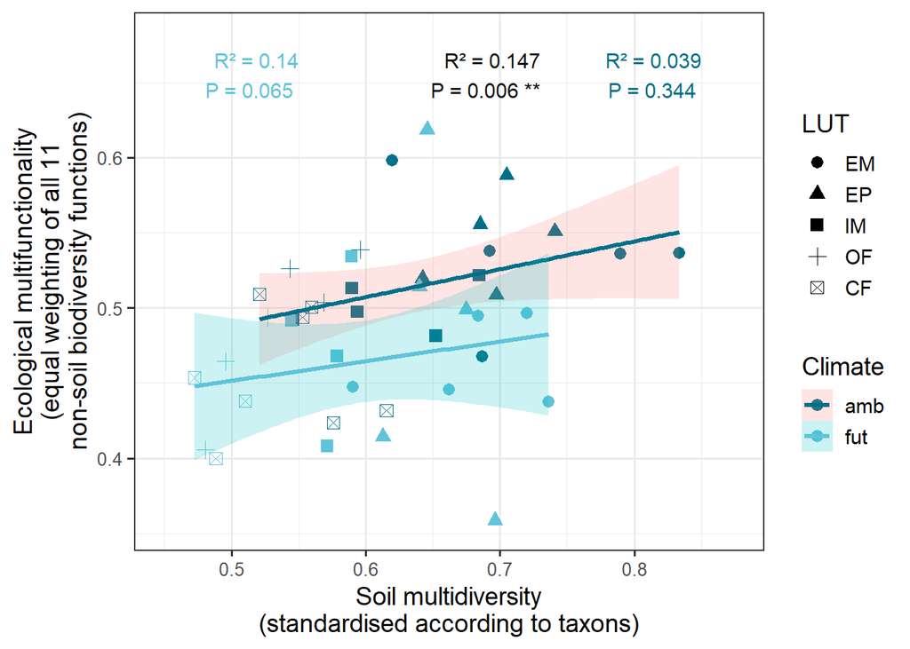

```r
Figure_6_Biodiv_egEMF_o_Biodiv_Correlation <- ggplot(aes_string(x="Multidiv", y="egEMF_o_Biodiv", color="Climate"), data = mf_data_lt)+
  geom_point(aes(shape=LUT),size=2.9)+ # for now, differentiation according to LUT excluded: geom_point(aes(shape=LUT), size=2.9)
  scale_colour_manual(values=c("amb" = "#007089", "fut" = "#60c3d9"))+
  geom_smooth(method="lm", level=0.95, aes(fill=Climate), alpha=0.2, size=1.1) +  # Add confidence intervals
  #geom_abline(slope = summary(lm(egEMF_o_Biodiv ~ Multidiv, data=mf_data_lt[mf_data_lt$Climate == "amb", ]))$coefficients[2,1], # pull out slope of linear regression
  #            intercept=summary(lm(egEMF_o_Biodiv ~ Multidiv, data=mf_data_lt[mf_data_lt$Climate == "amb", ]))$coefficients[1,1], color = "#007089", size=1.1)+ # pull out intercept of linear regression
  #geom_abline(slope = summary(lm(egEMF_o_Biodiv ~ Multidiv, data=mf_data_lt[mf_data_lt$Climate == "fut", ]))$coefficients[2,1], # pull out slope of linear regression
  #            intercept=summary(lm(egEMF_o_Biodiv ~ Multidiv, data=mf_data_lt[mf_data_lt$Climate == "fut", ]))$coefficients[1,1], color = "#60c3d9", size=1.1)+ # pull out intercept of linear regression
  #geom_abline(slope = summary(lm(egEMF_o_Biodiv ~ Multidiv, data=mf_data_lt))$coefficients[2,1], # pull out slope of linear regression
  #            intercept=summary(lm(egEMF_o_Biodiv ~ Multidiv, data=mf_data_lt))$coefficients[1,1], size=1.1)+ # pull out intercept of linear regression
  ylab("Ecological multifunctionality\n(equal weighting of all 11\nnon-soil biodiversity functions)")+
  xlab("Soil multidiversity\n(standardised according to taxons)")+
  #ggtitle(paste("R² = ",
  #              round(summary(lm(egEMF_o_Biodiv ~ Multidiv, data=mf_data_lt))$r.squared,3), # pull out R² of linear regression
  #              "\nP = ",
  #              round(summary(lm(egEMF_o_Biodiv ~ Multidiv, data=mf_data_lt))$coefficients[2,4],3),# pull out p value of linear regression
  #              " ",
  #              ifelse(summary(lm(egEMF_o_Biodiv ~ Multidiv, data=mf_data_lt))$coefficients[2,4] <= 0.001, "***",
  #                     ifelse(summary(lm(egEMF_o_Biodiv ~ Multidiv, data=mf_data_lt))$coefficients[2,4] <= 0.01, "**",
  #                            ifelse(summary(lm(egEMF_o_Biodiv ~ Multidiv, data=mf_data_lt))$coefficients[2,4] <= 0.05, "*", ""))),
  #              sep=""))+
  ylim(1.05* min(mf_data_lt$egEMF_o_Biodiv, na.rm = TRUE), 1.1 * max(mf_data_lt$egEMF_o_Biodiv, na.rm = TRUE))+
  xlim(1.05* min(mf_data_lt$Multidiv, na.rm = TRUE), 1.05 * max(mf_data_lt$Multidiv, na.rm = TRUE))+
  theme(plot.title = element_text(size=12,hjust=1),
        axis.text=element_text(size = 5),
        axis.text.x = element_text(size=10),
        axis.text.y = element_text(size=10))+
  annotate("text", x = 0.85, y = 0.67, label = paste("R² = ",
                                                   round(summary(lm(egEMF_o_Biodiv ~ Multidiv, data=mf_data_lt[mf_data_lt$Climate == "amb", ]))$r.squared,3), # pull out R² of linear regression
                                                   "\nP = ",
                                                   round(summary(lm(egEMF_o_Biodiv ~ Multidiv, data=mf_data_lt[mf_data_lt$Climate == "amb", ]))$coefficients[2,4],3),# pull out p value of linear regression
                                                   " ",
                                                   ifelse(summary(lm(egEMF_o_Biodiv ~ Multidiv, data=mf_data_lt[mf_data_lt$Climate == "amb", ]))$coefficients[2,4] <= 0.001, "***",
                                                          ifelse(summary(lm(egEMF_o_Biodiv ~ Multidiv, data=mf_data_lt[mf_data_lt$Climate == "amb", ]))$coefficients[2,4] <= 0.01, "**",
                                                                 ifelse(summary(lm(egEMF_o_Biodiv ~ Multidiv, data=mf_data_lt[mf_data_lt$Climate == "amb", ]))$coefficients[2,4] <= 0.05, "*", ""))),
                                                   sep=""), hjust = 1, vjust = 1, size = 4, color = "#007089")+
  annotate("text", x = 0.55, y = 0.67, label = paste("R² = ",
                                                   round(summary(lm(egEMF_o_Biodiv ~ Multidiv, data=mf_data_lt[mf_data_lt$Climate == "fut", ]))$r.squared,3), # pull out R² of linear regression
                                                   "\nP = ",
                                                   round(summary(lm(egEMF_o_Biodiv ~ Multidiv, data=mf_data_lt[mf_data_lt$Climate == "fut", ]))$coefficients[2,4],3),# pull out p value of linear regression
                                                   " ",
                                                   ifelse(summary(lm(egEMF_o_Biodiv ~ Multidiv, data=mf_data_lt[mf_data_lt$Climate == "fut", ]))$coefficients[2,4] <= 0.001, "***",
                                                          ifelse(summary(lm(egEMF_o_Biodiv ~ Multidiv, data=mf_data_lt[mf_data_lt$Climate == "fut", ]))$coefficients[2,4] <= 0.01, "**",
                                                                 ifelse(summary(lm(egEMF_o_Biodiv ~ Multidiv, data=mf_data_lt[mf_data_lt$Climate == "fut", ]))$coefficients[2,4] <= 0.05, "*", ""))),
                                                   sep=""), hjust = 1, vjust = 1, size = 4, color = "#60c3d9")+
  annotate("text", x = 0.73, y = 0.67, label = paste("R² = ",
                                                   round(summary(lm(egEMF_o_Biodiv ~ Multidiv, data=mf_data_lt))$r.squared,3), # pull out R² of linear regression
                                                   "\nP = ",
                                                   round(summary(lm(egEMF_o_Biodiv ~ Multidiv, data=mf_data_lt))$coefficients[2,4],3),# pull out p value of linear regression
                                                   " ",
                                                   ifelse(summary(lm(egEMF_o_Biodiv ~ Multidiv, data=mf_data_lt))$coefficients[2,4] <= 0.001, "***",
                                                          ifelse(summary(lm(egEMF_o_Biodiv ~ Multidiv, data=mf_data_lt))$coefficients[2,4] <= 0.01, "**",
                                                                 ifelse(summary(lm(egEMF_o_Biodiv ~ Multidiv, data=mf_data_lt))$coefficients[2,4] <= 0.05, "*", ""))),
                                                   sep=""), hjust = 1, vjust = 1, size = 4, color = "#111111")


ggsave("Figure_6_Biodiv_egEMF_o_Biodiv_Correlation.pdf", Figure_6_Biodiv_egEMF_o_Biodiv_Correlation, scale = 1, width = 6, height = 5, dpi=500, units="in")

Figure_6_Biodiv_egEMF_o_Biodiv_Correlation
```

**Part 2: Economic approach**

Calculating the insurance value of soil health and biodiversity:

A: Prove that soil health and multidiversity correlate with yield stability (given as the inverse of the yield coefficient of variation):

```r
for (i in 1:50){
  mf_data_lt$Yield_Stability[i] <- (cv(mf_data_big$Yield[mf_data_big$Plot==mf_data_lt$Plot[i]])^(-1))
}

# linear regression across all climate and land use types

# For soil multidiversity:
Yield_Stability_M <- ggplot(aes_string(x="Multidiv", y="Yield_Stability", color="Climate"), data = mf_data_lt)+
  geom_point(aes(shape=LUT), size =2.5)+
  scale_colour_manual(values=c("amb" = "#007089", "fut" = "#60c3d9"))+
  geom_abline(slope = summary(lm(Yield_Stability ~ Multidiv, data=mf_data_lt))$coefficients[2,1],
              intercept=summary(lm(Yield_Stability ~ Multidiv, data=mf_data_lt))$coefficients[1,1])+
  ylab("Yield stability as\ncoefficient of variation")+
  xlab("Soil multidiversity\n(standardised according to taxons)")+
  ggtitle(paste("R² = ",
                round(summary(lm(Yield_Stability ~ Multidiv, data=mf_data_lt))$r.squared,3), # pull out R² of linear regression
                "\nP = ",
                round(summary(lm(Yield_Stability ~ Multidiv, data=mf_data_lt))$coefficients[2,4],3),# pull out p value of linear regression
                " ",
                ifelse(summary(lm(Yield_Stability ~ Multidiv, data=mf_data_lt))$coefficients[2,4]<0.001,"***",
                       ifelse(summary(lm(Yield_Stability ~ Multidiv, data=mf_data_lt))$coefficients[2,4]<0.01,"**",
                              ifelse(summary(lm(Yield_Stability ~ Multidiv, data=mf_data_lt))$coefficients[2,4]<0.05,"**", " "))),
                sep=""))+
  theme(plot.title = element_text(size=12,hjust=1),
        axis.text=element_text(size = 5),
        axis.text.x = element_text(size=8),
        axis.text.y = element_text(size=8))


# For soil health:
Yield_Stability_SH <- ggplot(aes_string(x="Soil_Health", y="Yield_Stability", color="Climate"), data = mf_data_lt)+
  geom_point(aes(shape=LUT), size =2.5)+
  scale_colour_manual(values=c("amb" = "#007089", "fut" = "#60c3d9"))+
  geom_abline(slope = summary(lm(Yield_Stability ~ Soil_Health, data=mf_data_lt))$coefficients[2,1],
              intercept=summary(lm(Yield_Stability ~ Soil_Health, data=mf_data_lt))$coefficients[1,1])+
  ylab("Yield stability as\ncoefficient of variation")+
  xlab("Soil Health\n(fraction of max)")+
  ggtitle(paste("R² = ",
                round(summary(lm(Yield_Stability ~ Soil_Health, data=mf_data_lt))$r.squared,3), # pull out R² of linear regression
                "\nP = ",
                round(summary(lm(Yield_Stability ~ Soil_Health, data=mf_data_lt))$coefficients[2,4],3),# pull out p value of linear regression
                " ",
                ifelse(summary(lm(Yield_Stability ~ Soil_Health, data=mf_data_lt))$coefficients[2,4]<0.001,"***",
                       ifelse(summary(lm(Yield_Stability ~ Soil_Health, data=mf_data_lt))$coefficients[2,4]<0.01,"**",
                              ifelse(summary(lm(Yield_Stability ~ Soil_Health, data=mf_data_lt))$coefficients[2,4]<0.05,"**", " "))),
                sep=""))+
  theme(plot.title = element_text(size=12,hjust=1),
        axis.text=element_text(size = 5),
        axis.text.x = element_text(size=8),
        axis.text.y = element_text(size=8))

Fig_Yield_Stability_M_SH <- ggarrange(Yield_Stability_M, Yield_Stability_SH, ncol = 2, nrow = 1, labels = "auto", font.label = list(size = 24), common.legend = TRUE, legend = "right")

ggsave("Fig_Yield_Stability_M_SH.pdf", Fig_Yield_Stability_M_SH, scale = 1, width = 9, height = 4, dpi=500, units="in")
```

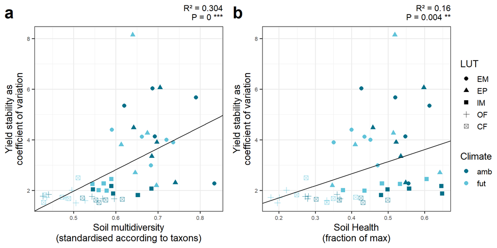

```r
Fig_Yield_Stability_M_SH
```

Get information about the correlation between yield stability and multidiversity / soil health:

```r
print(paste("Yield stability (inverse of coefficient of variation) correlates with biodiversity (For all land use types: R² = ",
            round(summary(lm(Yield_Stability ~ Multidiv, data=mf_data_lt))$r.squared,3),
            ", P = ",
            round(summary(lm(Yield_Stability ~ Multidiv, data=mf_data_lt))$coefficients[2,4],3), " (",
            ifelse(summary(lm(Yield_Stability ~ Multidiv, data=mf_data_lt))$coefficients[2,4]<0.001,"***",
                   ifelse(summary(lm(Yield_Stability ~ Multidiv, data=mf_data_lt))$coefficients[2,4]<0.01,"**",
                          ifelse(summary(lm(Yield_Stability ~ Multidiv, data=mf_data_lt))$coefficients[2,4]<0.05,"**", " "))), "); for grassland only: R² = ",
            round(summary(lm(Yield_Stability ~ Multidiv, data=mf_data_lt[mf_data_lt$LUT=="EM" | mf_data_lt$LUT=="EP" | mf_data_lt$LUT=="IM",]))$r.squared,3),
            ", P = ",
            round(summary(lm(Yield_Stability ~ Multidiv, data=mf_data_lt[mf_data_lt$LUT=="EM" | mf_data_lt$LUT=="EP" | mf_data_lt$LUT=="IM",]))$coefficients[2,4],3), " (",
            ifelse(summary(lm(Yield_Stability ~ Multidiv, data=mf_data_lt[mf_data_lt$LUT=="EM" | mf_data_lt$LUT=="EP" | mf_data_lt$LUT=="IM",]))$coefficients[2,4]<0.001,"***",
                   ifelse(summary(lm(Yield_Stability ~ Multidiv, data=mf_data_lt[mf_data_lt$LUT=="EM" | mf_data_lt$LUT=="EP" | mf_data_lt$LUT=="IM",]))$coefficients[2,4]<0.01,"**",
                          ifelse(summary(lm(Yield_Stability ~ Multidiv, data=mf_data_lt[mf_data_lt$LUT=="EM" | mf_data_lt$LUT=="EP" | mf_data_lt$LUT=="IM",]))$coefficients[2,4]<0.05,"**", " "))),")).", "); for farmland only: R² = ",
            round(summary(lm(Yield_Stability ~ Multidiv, data=mf_data_lt[mf_data_lt$LUT=="CF" | mf_data_lt$LUT=="OF",]))$r.squared,3),
            ", P = ",
            round(summary(lm(Yield_Stability ~ Multidiv, data=mf_data_lt[mf_data_lt$LUT=="CF" | mf_data_lt$LUT=="OF",]))$coefficients[2,4],3), " (",
            ifelse(summary(lm(Yield_Stability ~ Multidiv, data=mf_data_lt[mf_data_lt$LUT=="CF" | mf_data_lt$LUT=="OF",]))$coefficients[2,4]<0.001,"***",
                   ifelse(summary(lm(Yield_Stability ~ Multidiv, data=mf_data_lt[mf_data_lt$LUT=="CF" | mf_data_lt$LUT=="OF",]))$coefficients[2,4]<0.01,"**",
                          ifelse(summary(lm(Yield_Stability ~ Multidiv, data=mf_data_lt[mf_data_lt$LUT=="CF" | mf_data_lt$LUT=="OF",]))$coefficients[2,4]<0.05,"**", " "))),")).",
            " and with soil health (For all land use types: R² = ",
            round(summary(lm(Yield_Stability ~ Soil_Health, data=mf_data_lt))$r.squared,3),
            ", P = ",
            round(summary(lm(Yield_Stability ~ Soil_Health, data=mf_data_lt))$coefficients[2,4],3), " (",
            ifelse(summary(lm(Yield_Stability ~ Soil_Health, data=mf_data_lt))$coefficients[2,4]<0.001,"***",
                   ifelse(summary(lm(Yield_Stability ~ Soil_Health, data=mf_data_lt))$coefficients[2,4]<0.01,"**",
                          ifelse(summary(lm(Yield_Stability ~ Soil_Health, data=mf_data_lt))$coefficients[2,4]<0.05,"**", " "))), "); for grassland only: R² = ",
            round(summary(lm(Yield_Stability ~ Soil_Health, data=mf_data_lt[mf_data_lt$LUT=="EM" | mf_data_lt$LUT=="EP" | mf_data_lt$LUT=="IM",]))$r.squared,3),
            ", P = ",
            round(summary(lm(Yield_Stability ~ Soil_Health, data=mf_data_lt[mf_data_lt$LUT=="EM" | mf_data_lt$LUT=="EP" | mf_data_lt$LUT=="IM",]))$coefficients[2,4],3), " (",
            ifelse(summary(lm(Yield_Stability ~ Soil_Health, data=mf_data_lt[mf_data_lt$LUT=="EM" | mf_data_lt$LUT=="EP" | mf_data_lt$LUT=="IM",]))$coefficients[2,4]<0.001,"***",
                   ifelse(summary(lm(Yield_Stability ~ Soil_Health, data=mf_data_lt[mf_data_lt$LUT=="EM" | mf_data_lt$LUT=="EP" | mf_data_lt$LUT=="IM",]))$coefficients[2,4]<0.01,"**",
                          ifelse(summary(lm(Yield_Stability ~ Soil_Health, data=mf_data_lt[mf_data_lt$LUT=="EM" | mf_data_lt$LUT=="EP" | mf_data_lt$LUT=="IM",]))$coefficients[2,4]<0.05,"**", " "))),")).", "); for farmland only: R² = ",
            round(summary(lm(Yield_Stability ~ Soil_Health, data=mf_data_lt[mf_data_lt$LUT=="CF" | mf_data_lt$LUT=="OF",]))$r.squared,3),
            ", P = ",
            round(summary(lm(Yield_Stability ~ Soil_Health, data=mf_data_lt[mf_data_lt$LUT=="CF" | mf_data_lt$LUT=="OF",]))$coefficients[2,4],3), " (",
            ifelse(summary(lm(Yield_Stability ~ Soil_Health, data=mf_data_lt[mf_data_lt$LUT=="CF" | mf_data_lt$LUT=="OF",]))$coefficients[2,4]<0.001,"***",
                   ifelse(summary(lm(Yield_Stability ~ Soil_Health, data=mf_data_lt[mf_data_lt$LUT=="CF" | mf_data_lt$LUT=="OF",]))$coefficients[2,4]<0.01,"**",
                          ifelse(summary(lm(Yield_Stability ~ Soil_Health, data=mf_data_lt[mf_data_lt$LUT=="CF" | mf_data_lt$LUT=="OF",]))$coefficients[2,4]<0.05,"**", " "))),")).",
            sep=""))
```

[output not shown]

B: Defining risk aversion:

```r
r <- 0.28 # Relative risk aversion for a slightly risk averse farmer (Tevenart et al., 2021)
```

C: Calculating certainty equivalent CE and risk premium RP on plot level:

```r
for (i in 1:50){
  mf_data_lt$CE[i] <- mf_data_lt$Yield[i] * (((1 + (cv(mf_data_big$Yield[mf_data_big$Plot==mf_data_lt$Plot[i]])))^2)^(-r/2))
  mf_data_lt$RP[i] <- mf_data_lt$Yield[i] - mf_data_lt$CE[i]
}
```

D: Investigate the effect of multicollinearity to make sure it is small enough to allow regression:

```r
model <- lm(RP ~ Soil_Health + Multidiv + TOC + Yield + Nmin_Surplus, data=mf_data_lt)
vif(model)
```

```
##  Soil_Health     Multidiv          TOC        Yield Nmin_Surplus
##     2.504887     3.487992     2.166896     3.775236     1.543861
```

E: Calculating response surface (risk premium as function of multidiversity and soil health):

```r
x1 <- mf_data_lt$Soil_Health
x2 <- mf_data_lt$Multidiv
x3 <- mf_data_lt$RP

screening = lm(x3 ~ x1 + x2)
centcomp <- lm(x3 ~ x1 * x2 + I(x1^2) + I(x2^2))
centcomp_results = data.frame(x3, centcomp$fitted.values, x3 - centcomp$fitted.values)
colnames(centcomp_results) = c("expt RP", "pred RP", "residual error")

x1_axis <- seq(0.1,0.7,0.012) # based on min and max values of soil health
x2_axis <- seq(0.4,0.9,0.01) # based on min and max values of biodiversity

response = function(x,y){coef(centcomp)[1] + coef(centcomp)[2]*x + coef(centcomp)[3]*y + coef(centcomp)[4]*x^2 + coef(centcomp)[5]*y^2 + coef(centcomp)[6]*x*y}

z_axis = outer(X = x1_axis,Y = x2_axis, response)

pdf("Filename.pdf", width =12, height = 4.5) # width and height define the size of the pdf

contour2D(x = x1_axis,y = x2_axis, z = z_axis, xlab = "x1: Soil health", ylab = "x2: Multidiversity", clab = "Risk premium")

persp3D(x = x1_axis, y = x2_axis, z = z_axis, ticktype = "detailed", phi = 15, theta = 25, xlab = "Soil health", ylab = "Multidiversity", zlab = "Risk premium", clab = "Risk premium\n(€ / ha / yr)", contour = TRUE, cex.axis = 0.75, cex.lab = 0.75)

scatter3D(x = x1, y = x2, z = x3, add = TRUE, type = "h", pch = 19, col = "black", lwd = 2, colkey = FALSE)

dev.off()
```

```r
# From the variable 'response' which gives the formula of the multivariate polynominal regression, we obtain the insurance value of biodiversity IB and soil health IS:
for (j in 1:50){
  mf_data_lt$IB[j] <- (coef(centcomp)[1] + coef(centcomp)[2]*mf_data_lt$Soil_Health[j] + coef(centcomp)[3]*0 + coef(centcomp)[4]*mf_data_lt$Soil_Health[j]^2 + coef(centcomp)[5]*0^2 + coef(centcomp)[6]*mf_data_lt$Soil_Health[j]*0) - (coef(centcomp)[1] + coef(centcomp)[2]*mf_data_lt$Soil_Health[j] + coef(centcomp)[3]*mf_data_lt$Multidiv[j] + coef(centcomp)[4]*mf_data_lt$Soil_Health[j]^2 + coef(centcomp)[5]*mf_data_lt$Multidiv[j]^2 + coef(centcomp)[6]*mf_data_lt$Soil_Health[j]*mf_data_lt$Multidiv[j])
    mf_data_lt$IS[j] <- (coef(centcomp)[1] + coef(centcomp)[2]*0 + coef(centcomp)[3]*mf_data_lt$Multidiv[j] + coef(centcomp)[4]*0^2 + coef(centcomp)[5]*mf_data_lt$Multidiv[j]^2 + coef(centcomp)[6]*0*mf_data_lt$Multidiv[j]) - (coef(centcomp)[1] + coef(centcomp)[2]*mf_data_lt$Soil_Health[j] + coef(centcomp)[3]*mf_data_lt$Multidiv[j] + coef(centcomp)[4]*mf_data_lt$Soil_Health[j]^2 + coef(centcomp)[5]*mf_data_lt$Multidiv[j]^2 + coef(centcomp)[6]*mf_data_lt$Soil_Health[j]*mf_data_lt$Multidiv[j])
}

mf_data_lt$IB <- as.numeric(unlist(mf_data_lt$IB))
mf_data_lt$IS <- as.numeric(unlist(mf_data_lt$IS))
```

Monetisation (all units in euro / hectare / year) of the ecosystem services ‘Climate regulation’ and ‘Water regulation’ (Yield and biodiversity / soil health (insurance value) are already given in monetary units):

```r
# Climate regulation: Monetisation based on yearly mean net carbon flux (relative to carbon content before the beginning of the experiment (1.9)):

soil_weight <- 1.35 # weight of soil in tonnes per m³
price_t_co2 <- 195 # social cost of CO2 emission in euro per tonne according to German Feder Environment Agency (2021)
price_t_co2_ETS <- 90 # average price of 1 ton of CO2eq emission within the European Emission Trading Scheme in 2022/23 (alternative price for sensitivity check)

price_t_co2_Kikstra <- 280 # average price of 1 ton of CO2eq emission according to Kikstra et al. (2021) (alternative price for sensitivity check)

depth_TOC_in_soil <- 0.3 # Assumed distribution depth of total organic carbon in the soil in m.

for (i in 1:50){
  mf_data_lt$TOC_Euro[i] <- mean(c((mf_data_big$TOC[mf_data_big$Plot==mf_data_lt$Plot[i] & mf_data_big$Year==Years[1]] - 1.9),
                                   (mf_data_big$TOC[mf_data_big$Plot==mf_data_lt$Plot[i] & mf_data_big$Year==Years[2]] - mf_data_big$TOC[mf_data_big$Plot==mf_data_lt$Plot[i] & mf_data_big$Year==Years[1]]),
                                   (mf_data_big$TOC[mf_data_big$Plot==mf_data_lt$Plot[i] & mf_data_big$Year==Years[3]] - mf_data_big$TOC[mf_data_big$Plot==mf_data_lt$Plot[i] & mf_data_big$Year==Years[2]]),
                                   (mf_data_big$TOC[mf_data_big$Plot==mf_data_lt$Plot[i] & mf_data_big$Year==Years[4]] - mf_data_big$TOC[mf_data_big$Plot==mf_data_lt$Plot[i] & mf_data_big$Year==Years[3]]),
                                   (mf_data_big$TOC[mf_data_big$Plot==mf_data_lt$Plot[i] & mf_data_big$Year==Years[5]] - mf_data_big$TOC[mf_data_big$Plot==mf_data_lt$Plot[i] & mf_data_big$Year==Years[4]]),
                                   (mf_data_big$TOC[mf_data_big$Plot==mf_data_lt$Plot[i] & mf_data_big$Year==Years[6]] - mf_data_big$TOC[mf_data_big$Plot==mf_data_lt$Plot[i] & mf_data_big$Year==Years[5]]))) * price_t_co2 * soil_weight * depth_TOC_in_soil * 0.01 * 10000 * 3.66 #(transformation factors: 0.01: percent; 10000: number of m² per hectare; mass transformation factor C to CO2 based on atomic masses of oxygen and carbon)
  mf_data_lt$TOC_Euro_ETS[i] <- mean(c((mf_data_big$TOC[mf_data_big$Plot==mf_data_lt$Plot[i] & mf_data_big$Year==Years[1]] - 1.9),
                                   (mf_data_big$TOC[mf_data_big$Plot==mf_data_lt$Plot[i] & mf_data_big$Year==Years[2]] - mf_data_big$TOC[mf_data_big$Plot==mf_data_lt$Plot[i] & mf_data_big$Year==Years[1]]),
                                   (mf_data_big$TOC[mf_data_big$Plot==mf_data_lt$Plot[i] & mf_data_big$Year==Years[3]] - mf_data_big$TOC[mf_data_big$Plot==mf_data_lt$Plot[i] & mf_data_big$Year==Years[2]]),
                                   (mf_data_big$TOC[mf_data_big$Plot==mf_data_lt$Plot[i] & mf_data_big$Year==Years[4]] - mf_data_big$TOC[mf_data_big$Plot==mf_data_lt$Plot[i] & mf_data_big$Year==Years[3]]),
                                   (mf_data_big$TOC[mf_data_big$Plot==mf_data_lt$Plot[i] & mf_data_big$Year==Years[5]] - mf_data_big$TOC[mf_data_big$Plot==mf_data_lt$Plot[i] & mf_data_big$Year==Years[4]]),
                                   (mf_data_big$TOC[mf_data_big$Plot==mf_data_lt$Plot[i] & mf_data_big$Year==Years[6]] - mf_data_big$TOC[mf_data_big$Plot==mf_data_lt$Plot[i] & mf_data_big$Year==Years[5]]))) * price_t_co2_ETS * soil_weight * depth_TOC_in_soil * 0.01 * 10000 * 3.66 #(transformation factors: 0.01: percent; 10000: number of m² per hectare; mass transformation factor C to CO2 based on atomic masses of oxygen and carbon)
  mf_data_lt$TOC_Euro_Kikstra[i] <- mean(c((mf_data_big$TOC[mf_data_big$Plot==mf_data_lt$Plot[i] & mf_data_big$Year==Years[1]] - 1.9),
                                   (mf_data_big$TOC[mf_data_big$Plot==mf_data_lt$Plot[i] & mf_data_big$Year==Years[2]] - mf_data_big$TOC[mf_data_big$Plot==mf_data_lt$Plot[i] & mf_data_big$Year==Years[1]]),
                                   (mf_data_big$TOC[mf_data_big$Plot==mf_data_lt$Plot[i] & mf_data_big$Year==Years[3]] - mf_data_big$TOC[mf_data_big$Plot==mf_data_lt$Plot[i] & mf_data_big$Year==Years[2]]),
                                   (mf_data_big$TOC[mf_data_big$Plot==mf_data_lt$Plot[i] & mf_data_big$Year==Years[4]] - mf_data_big$TOC[mf_data_big$Plot==mf_data_lt$Plot[i] & mf_data_big$Year==Years[3]]),
                                   (mf_data_big$TOC[mf_data_big$Plot==mf_data_lt$Plot[i] & mf_data_big$Year==Years[5]] - mf_data_big$TOC[mf_data_big$Plot==mf_data_lt$Plot[i] & mf_data_big$Year==Years[4]]),
                                   (mf_data_big$TOC[mf_data_big$Plot==mf_data_lt$Plot[i] & mf_data_big$Year==Years[6]] - mf_data_big$TOC[mf_data_big$Plot==mf_data_lt$Plot[i] & mf_data_big$Year==Years[5]]))) * price_t_co2_Kikstra * soil_weight * depth_TOC_in_soil * 0.01 * 10000 * 3.66 #(transformation factors: 0.01: percent; 10000: number of m² per hectare; mass transformation factor C to CO2 based on atomic masses of oxygen and carbon)
}

# Water regulation:
price_Nmin <- 7.3 # in euro per kg surplus (based on German Federal Environment Agency (2021) accounting price for nitrogen leaching into surface water bodies)
price_Nmin_groundwater <- 1.9 # in euro per kg surplus (based on German Federal Environment Agency (2021) accounting prices for nitrogen leaching into groundwater bodies, alternative price for sensitivity check)



for (i in 1:50){
  mf_data_lt$Nmin_Surplus_Euro[i] <- mf_data_lt$Nmin_Surplus[i] * (-10 * price_Nmin) # the factor "-10" is used to transform units from g/m² to kg/ha, minus sign added to to punish nitrogen surplus
  mf_data_lt$Nmin_Surplus_Euro_Groundwater[i] <- mf_data_lt$Nmin_Surplus[i] * (-10 * price_Nmin_groundwater) # the factor "-10" is used to transform units from g/m² to kg/ha, minus sign added to to punish nitrogen surplus
}
```

Now, enEMF of ecosystem service provision can be calculated on plot level, also, farmers economic value (enEMF_Farmers) is calculated; and enEMF under alternative price scenarios (Nmin leaching into groundwater instead of surface water; market price (based on EU-ETS) instead of social cost (based on German Federal Environment Agency Accounting Price) for carbon sequestration; anova is performed to check for significance of effects:

```r
for (i in 1:50){
  mf_data_lt$enEMF[i] <- mf_data_lt$Yield[i] + mf_data_lt$TOC_Euro[i] + mf_data_lt$Nmin_Surplus_Euro[i] + mf_data_lt$IS[i] + mf_data_lt$IB[i]
  mf_data_lt$enEMF_Groundwater[i] <- mf_data_lt$Yield[i] + mf_data_lt$TOC_Euro[i] + mf_data_lt$Nmin_Surplus_Euro_Groundwater[i] + mf_data_lt$IS[i] + mf_data_lt$IB[i]
  mf_data_lt$enEMF_ETS[i] <- mf_data_lt$Yield[i] + mf_data_lt$TOC_Euro_ETS[i] + mf_data_lt$Nmin_Surplus_Euro[i] + mf_data_lt$IS[i] + mf_data_lt$IB[i]
  mf_data_lt$enEMF_Kikstra[i] <- mf_data_lt$Yield[i] + mf_data_lt$TOC_Euro_Kikstra[i] + mf_data_lt$Nmin_Surplus_Euro[i] + mf_data_lt$IS[i] + mf_data_lt$IB[i]
  mf_data_lt$enEMF_Farmers[i] <- mf_data_lt$Yield[i] + mf_data_lt$IS[i] + mf_data_lt$IB[i]
  mf_data_lt$enEMF_High_Yield_Cost[i] <- mf_data_lt$Yield[i] * 1.4 + mf_data_lt$TOC_Euro[i] + mf_data_lt$Nmin_Surplus_Euro[i] + mf_data_lt$IS[i] + mf_data_lt$IB[i] #alternative price scenario: 40% increase in crop prices
}


anova(lmer(enEMF ~ LUT * Climate + (1 | Mainplot), data = mf_data_lt))
```

```
## Type III Analysis of Variance Table with Satterthwaite's method
##               Sum Sq Mean Sq NumDF   DenDF F value    Pr(>F)
## LUT         11271623 2817906     4 30.6383 14.9375 7.058e-07 ***
## Climate            2       2     1  8.2216  0.0000    0.9974
## LUT:Climate   425643  106411     4 30.6383  0.5641    0.6905
## ---
## Signif. codes:  0 '***' 0.001 '**' 0.01 '*' 0.05 '.' 0.1 ' ' 1
```

```r
anova(lmer(enEMF_Groundwater ~ LUT * Climate + (1 | Mainplot), data = mf_data_lt))
```

```
## Type III Analysis of Variance Table with Satterthwaite's method
##              Sum Sq Mean Sq NumDF   DenDF F value    Pr(>F)
## LUT         4527832 1131958     4 30.7248  6.3848 0.0007333 ***
## Climate       14698   14698     1  8.2756  0.0829 0.7804767
## LUT:Climate  438898  109724     4 30.7248  0.6189 0.6524074
## ---
## Signif. codes:  0 '***' 0.001 '**' 0.01 '*' 0.05 '.' 0.1 ' ' 1
```

```r
anova(lmer(enEMF_ETS ~ LUT * Climate + (1 | Mainplot), data = mf_data_lt))
```

```
## Type III Analysis of Variance Table with Satterthwaite's method
##              Sum Sq Mean Sq NumDF   DenDF F value    Pr(>F)
## LUT         8258090 2064523     4 30.6302 37.5886 2.099e-11 ***
## Climate       85011   85011     1  8.2053  1.5478    0.2478
## LUT:Climate  119707   29927     4 30.6302  0.5449    0.7040
## ---
## Signif. codes:  0 '***' 0.001 '**' 0.01 '*' 0.05 '.' 0.1 ' ' 1
```

```r
anova(lmer(enEMF_Kikstra ~ LUT * Climate + (1 | Mainplot), data = mf_data_lt))
```

```
## Type III Analysis of Variance Table with Satterthwaite's method
##               Sum Sq Mean Sq NumDF   DenDF F value    Pr(>F)
## LUT         18229037 4557259     4 30.6439 12.3757 4.189e-06 ***
## Climate        55793   55793     1  8.2279  0.1515    0.7070
## LUT:Climate   845217  211304     4 30.6439  0.5738    0.6837
## ---
## Signif. codes:  0 '***' 0.001 '**' 0.01 '*' 0.05 '.' 0.1 ' ' 1
```

```r
anova(lmer(enEMF_Farmers ~ LUT * Climate + (1 | Mainplot), data = mf_data_lt))
```

```
## Type III Analysis of Variance Table with Satterthwaite's method
##              Sum Sq Mean Sq NumDF DenDF  F value    Pr(>F)
## LUT         2266337  566584     4    32 153.0291 < 2.2e-16 ***
## Climate      127953  127953     1     8  34.5590 0.0003705 ***
## LUT:Climate    4876    1219     4    32   0.3292 0.8562379
## ---
## Signif. codes:  0 '***' 0.001 '**' 0.01 '*' 0.05 '.' 0.1 ' ' 1
```

```r
anova(lmer(enEMF_High_Yield_Cost ~ LUT * Climate + (1 | Mainplot), data = mf_data_lt))
```

```
## Type III Analysis of Variance Table with Satterthwaite's method
##              Sum Sq Mean Sq NumDF   DenDF F value    Pr(>F)
## LUT         9368336 2342084     4 30.6673 12.3478 4.261e-06 ***
## Climate        9940    9940     1  8.2309  0.0524    0.8245
## LUT:Climate  466350  116588     4 30.6673  0.6147    0.6553
## ---
## Signif. codes:  0 '***' 0.001 '**' 0.01 '*' 0.05 '.' 0.1 ' ' 1
```

```r
model_enEMF <- lmer(enEMF ~ LUT + Climate + (1 | Mainplot), data = mf_data_lt) # adapted model (+ instead of *) as there is no LUT:Climate interaction effect
model_enEMF_Groundwater <- lmer(enEMF_Groundwater ~ LUT * Climate + (1 | Mainplot), data = mf_data_lt) # adapted model (+ instead of *) as there is no LUT:Climate interaction effect
model_enEMF_ETS <- lmer(enEMF_ETS ~ LUT + Climate + (1 | Mainplot), data = mf_data_lt) # adapted model (+ instead of *) as there is no LUT:Climate interaction effect
model_enEMF_Farmers <- lmer(enEMF_Farmers ~ LUT * Climate + (1 | Mainplot), data = mf_data_lt) # adapted model (+ instead of *) as there is no LUT:Climate interaction effect
model_enEMF_Kikstra <- lmer(enEMF_Kikstra ~ LUT * Climate + (1 | Mainplot), data = mf_data_lt) # adapted model (+ instead of *) as there is no LUT:Climate interaction effect
model_enEMF_High_Yield_Cost <- lmer(enEMF_High_Yield_Cost ~ LUT * Climate + (1 | Mainplot), data = mf_data_lt) # adapted model (+ instead of *) as there is no LUT:Climate interaction effect

# Obtain the estimated marginal means (EMMs)
emm_enEMF <- lsmeans(model_enEMF, ~ LUT) # only for LUTS (Climate removed as there is no interaction effect)
emm_enEMF_Groundwater <- lsmeans(model_enEMF_Groundwater, ~ LUT) # only for LUTS (Climate removed as there is no interaction effect)
emm_enEMF_ETS <- lsmeans(model_enEMF_ETS, ~ LUT) # only for LUTS (Climate removed as there is no interaction effect)
emm_enEMF_Farmers <- lsmeans(model_enEMF_Farmers, ~ LUT) # only for LUTS (Climate removed as there is no interaction effect)
emm_enEMF_Kikstra <- lsmeans(model_enEMF_Kikstra, ~ LUT) # only for LUTS (Climate removed as there is no interaction effect)

emm_enEMF_High_Yield_Cost <- lsmeans(model_enEMF_High_Yield_Cost, ~ LUT) # only for LUTS (Climate removed as there is no interaction effect)

# Perform pairwise comparisons
pairwise_comp_enEMF <- pairs(emm_enEMF, adjust = "tukey")
pairwise_comp_enEMF_Groundwater <- pairs(emm_enEMF_Groundwater, adjust = "tukey")
pairwise_comp_ETS <- pairs(emm_enEMF_ETS, adjust = "tukey")
pairwise_comp_Farmers <- pairs(emm_enEMF_Farmers, adjust = "tukey")
pairwise_comp_Kikstra <- pairs(emm_enEMF_Kikstra, adjust = "tukey")
pairwise_comp_enEMF_High_Yield_Cost <- pairs(emm_enEMF_High_Yield_Cost, adjust = "tukey")

summary(pairwise_comp_enEMF)
```

```
##  contrast estimate  SE   df t.ratio p.value
##  EM - EP     -95.8 195 34.4 -0.491  0.9877
##  EM - IM     862.7 195 34.4  4.417  0.0008
##  EM - OF     263.6 189 34.0  1.393  0.6360
##  EM - CF    1126.4 189 34.0  5.955  <.0001
##  EP - IM     958.5 201 35.0  4.758  0.0003
##  EP - OF     359.4 195 34.4  1.840  0.3681
##  EP - CF    1222.2 195 34.4  6.257  <.0001
##  IM - OF    -599.2 195 34.4 -3.067  0.0319
##  IM - CF     263.7 195 34.4  1.350  0.6627
##  OF - CF     862.8 189 34.0  4.561  0.0006
##
## Results are averaged over the levels of: Climate
## Degrees-of-freedom method: kenward-roger
## P value adjustment: tukey method for comparing a family of 5 estimates
```

```r
summary(pairwise_comp_enEMF_Groundwater)
```

```
##  contrast estimate  SE   df t.ratio p.value
##  EM - EP    -295.4 195 30.5 -1.514  0.5615
##  EM - IM      25.9 195 30.5  0.133  0.9999
##  EM - OF     286.7 188 30.0  1.523  0.5564
##  EM - CF     622.9 188 30.0  3.308  0.0192
##  EP - IM     321.3 202 31.2  1.589  0.5149
##  EP - OF     582.1 195 30.5  2.984  0.0411
##  EP - CF     918.3 195 30.5  4.707  0.0005
##  IM - OF     260.8 195 30.5  1.337  0.6710
##  IM - CF     597.0 195 30.5  3.060  0.0344
##  OF - CF     336.2 188 30.0  1.785  0.4004
##
## Results are averaged over the levels of: Climate
## Degrees-of-freedom method: kenward-roger
## P value adjustment: tukey method for comparing a family of 5 estimates
```

```r
summary(pairwise_comp_ETS)
```

```
##  contrast estimate  SE   df t.ratio p.value
##  EM - EP        33 105 34.4   0.314 0.9978
##  EM - IM       847 105 34.4   8.043 <.0001
##  EM - OF      -216 102 34.0  -2.122 0.2346
##  EM - CF       678 102 34.0   6.646 <.0001
##  EP - IM       814 109 35.0   7.495 <.0001
##  EP - OF      -249 105 34.4  -2.368 0.1486
##  EP - CF       645 105 34.4   6.123 <.0001
##  IM - OF     -1063 105 34.4 -10.098 <.0001
##  IM - CF      -169 105 34.4  -1.607 0.5032
##  OF - CF       894 102 34.0   8.767 <.0001
##
## Results are averaged over the levels of: Climate
## Degrees-of-freedom method: kenward-roger
## P value adjustment: tukey method for comparing a family of 5 estimates
```

```r
summary(pairwise_comp_Farmers)
```

```
##  contrast estimate   SE df t.ratio p.value
##  EM - EP     -89.3 27.2 32  -3.280 0.0197
##  EM - IM    -298.4 27.2 32 -10.967 <.0001
##  EM - OF    -596.4 27.2 32 -21.915 <.0001
##  EM - CF    -387.7 27.2 32 -14.246 <.0001
##  EP - IM    -209.2 27.2 32  -7.687 <.0001
##  EP - OF    -507.1 27.2 32 -18.635 <.0001
##  EP - CF    -298.4 27.2 32 -10.966 <.0001
##  IM - OF    -297.9 27.2 32 -10.948 <.0001
##  IM - CF     -89.2 27.2 32  -3.279 0.0198
##  OF - CF     208.7 27.2 32   7.669 <.0001
##
## Results are averaged over the levels of: Climate
## Degrees-of-freedom method: kenward-roger
## P value adjustment: tukey method for comparing a family of 5 estimates
```

```r
summary(pairwise_comp_Kikstra)
```

```
##  contrast estimate  SE   df t.ratio p.value
##  EM - EP      -230 281 30.5 -0.818  0.9230
##  EM - IM       880 281 30.5  3.131  0.0291
##  EM - OF       652 271 30.0  2.403  0.1423
##  EM - CF      1490 271 30.0  5.489  0.0001
##  EP - IM      1111 292 31.1  3.809  0.0052
##  EP - OF       882 281 30.5  3.137  0.0287
##  EP - CF      1720 281 30.5  6.115  <.0001
##  IM - OF      -228 281 30.5 -0.812  0.9248
##  IM - CF       609 281 30.5  2.166  0.2196
##  OF - CF       838 271 30.0  3.087  0.0326
##
## Results are averaged over the levels of: Climate
## Degrees-of-freedom method: kenward-roger
## P value adjustment: tukey method for comparing a family of 5 estimates
```

```r
summary(emm_enEMF_High_Yield_Cost)
```

```
##  LUT lsmean  SE   df lower.CL upper.CL
##  EM    2308 149 35.2     2006     2610
##  EP    2464 158 36.1     2144     2785
##  IM    1576 158 36.1     1256     1896
##  OF    2352 149 35.2     2050     2654
##  CF    1389 149 35.2     1087     1691
##
## Results are averaged over the levels of: Climate
## Degrees-of-freedom method: kenward-roger
## Confidence level used: 0.95
```

```r
write.csv(summary(pairwise_comp_enEMF), "Table_S7_post_hoc_tukey_enEMF.csv")
write.csv(summary(pairwise_comp_Farmers), "Table_S8_post_hoc_tukey_enEMF_Farmers.csv")

write.csv(summary(pairwise_comp_enEMF_Groundwater), "post_hoc_tukey_enEMF_Groundwater.csv")
write.csv(summary(pairwise_comp_ETS), "post_hoc_tukey_enEMF_ETS.csv")
write.csv(summary(pairwise_comp_Kikstra), "post_hoc_tukey_enEMF_Kikstra.csv")
write.csv(summary(emm_enEMF_High_Yield_Cost), "post_hoc_tukey_enEMF_High_Yield_Cost.csv")
```

It was shown that the land use type treatment has a significant effect on enEMF (***) but not the climate treatment. Both grassland (p <= 0.01) and farmland (p <= 0.001) show a significant higher enEMF for the extensively managed land use types compared to the intensively managed land use types.

```r
Fig_enEMF_treatments <- ggplot(aes(x=LUT, y=enEMF, color=Climate),data=mf_data_lt)+
  geom_point()+
  scale_colour_manual(values=c("amb" = "#D7551B", "fut" = "#F4B183"))+
  stat_summary(
    geom = "point",
    fun.y = "mean",
    size = 4,
    shape = 17)+
  #ylim(500,3500)+
  stat_summary(fun.data = mean_se, geom = "errorbar")+ # add errorbar
  ylab("Economic ecosystem\nmultifunctionality (enEMF)\n(€ / ha / yr)")+
  xlab("Land Use Type")+
  ggtitle(paste(paste(ifelse(anova(lmer(enEMF ~ LUT * Climate + (1 | Mainplot), data = mf_data_lt))$"Pr(>F)"[3] <= 0.05, "LUT:Climate", ""),
                      ifelse(anova(lmer(enEMF ~ LUT * Climate + (1 | Mainplot), data = mf_data_lt))$"Pr(>F)"[3] <= 0.001, "***",
                             ifelse(anova(lmer(enEMF ~ LUT * Climate + (1 | Mainplot), data = mf_data_lt))$"Pr(>F)"[3] <= 0.01, "**",
                                    ifelse(anova(lmer(enEMF ~ LUT * Climate + (1 | Mainplot), data = mf_data_lt))$"Pr(>F)"[3] <= 0.05, "*", "")))),
                paste(ifelse(anova(lmer(enEMF ~ LUT * Climate + (1 | Mainplot), data = mf_data_lt))$"Pr(>F)"[1] <= 0.05, "LUT", ""),
                      ifelse(anova(lmer(enEMF ~ LUT * Climate + (1 | Mainplot), data = mf_data_lt))$"Pr(>F)"[1] <= 0.001, "***",
                             ifelse(anova(lmer(enEMF ~ LUT * Climate + (1 | Mainplot), data = mf_data_lt))$"Pr(>F)"[1] <= 0.01, "**",
                                    ifelse(anova(lmer(enEMF ~ LUT * Climate + (1 | Mainplot), data = mf_data_lt))$"Pr(>F)"[1] <= 0.05, "*", ""))),
                      sep=" "),paste(ifelse(anova(lmer(enEMF ~ LUT * Climate + (1 | Mainplot), data = mf_data_lt))$"Pr(>F)"[2] <= 0.05, "Climate", ""),
                                     ifelse(anova(lmer(enEMF ~ LUT * Climate + (1 | Mainplot), data = mf_data_lt))$"Pr(>F)"[2] <= 0.001, "***",
                                            ifelse(anova(lmer(enEMF ~ LUT * Climate + (1 | Mainplot), data = mf_data_lt))$"Pr(>F)"[2] <= 0.01, "**",
                                                   ifelse(anova(lmer(enEMF ~ LUT * Climate + (1 | Mainplot), data = mf_data_lt))$"Pr(>F)"[2] <= 0.05, "*", "")))), sep="\n"))+
  theme(plot.title = element_text(hjust = 0.5),
        axis.text.y = element_text(size=16),
        axis.text.x = element_text(size=16))

#ggsave("Fig_enEMF_treatments.pdf", Fig_enEMF_treatments, scale = 1, width = 5, height = 4, dpi=500, units="in")
```

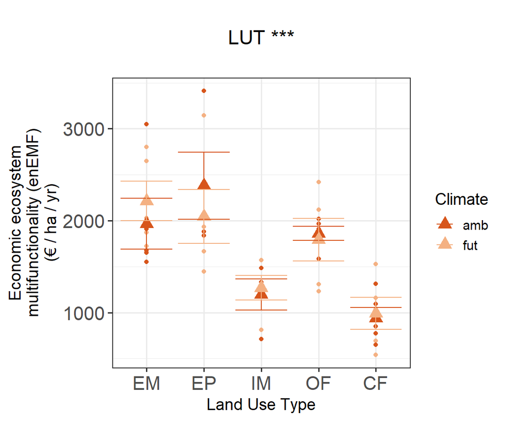

```r
Fig_enEMF_treatments
```

```r
Fig_enEMF_Groundwater_treatments <- ggplot(aes(x=LUT, y=enEMF_Groundwater, color=Climate),data=mf_data_lt)+
  geom_point()+
  scale_colour_manual(values=c("amb" = "#D7551B", "fut" = "#F4B183"))+
  stat_summary(
    geom = "point",
    fun.y = "mean",
    size = 4,
    shape = 17)+
  #ylim(500,3500)+
  stat_summary(fun.data = mean_se, geom = "errorbar")+ # add errorbar
  ylab("enEMF (alternativ price\nscnario: N leaching into\ngroundwater) (€ / ha / yr)")+
  xlab("Land Use Type")+
  ggtitle(paste(paste(ifelse(anova(lmer(enEMF_Groundwater ~ LUT * Climate + (1 | Mainplot), data = mf_data_lt))$"Pr(>F)"[3] <= 0.05, "LUT:Climate", ""),
                      ifelse(anova(lmer(enEMF_Groundwater ~ LUT * Climate + (1 | Mainplot), data = mf_data_lt))$"Pr(>F)"[3] <= 0.001, "***",
                             ifelse(anova(lmer(enEMF_Groundwater ~ LUT * Climate + (1 | Mainplot), data = mf_data_lt))$"Pr(>F)"[3] <= 0.01, "**",
                                    ifelse(anova(lmer(enEMF_Groundwater ~ LUT * Climate + (1 | Mainplot), data = mf_data_lt))$"Pr(>F)"[3] <= 0.05, "*", "")))),
                paste(ifelse(anova(lmer(enEMF_Groundwater ~ LUT * Climate + (1 | Mainplot), data = mf_data_lt))$"Pr(>F)"[1] <= 0.05, "LUT", ""),
                      ifelse(anova(lmer(enEMF_Groundwater ~ LUT * Climate + (1 | Mainplot), data = mf_data_lt))$"Pr(>F)"[1] <= 0.001, "***",
                             ifelse(anova(lmer(enEMF_Groundwater ~ LUT * Climate + (1 | Mainplot), data = mf_data_lt))$"Pr(>F)"[1] <= 0.01, "**",
                                    ifelse(anova(lmer(enEMF_Groundwater ~ LUT * Climate + (1 | Mainplot), data = mf_data_lt))$"Pr(>F)"[1] <= 0.05, "*", ""))),
                      sep=" "),paste(ifelse(anova(lmer(enEMF_Groundwater ~ LUT * Climate + (1 | Mainplot), data = mf_data_lt))$"Pr(>F)"[2] <= 0.05, "Climate", ""),
                                     ifelse(anova(lmer(enEMF_Groundwater ~ LUT * Climate + (1 | Mainplot), data = mf_data_lt))$"Pr(>F)"[2] <= 0.001, "***",
                                            ifelse(anova(lmer(enEMF_Groundwater ~ LUT * Climate + (1 | Mainplot), data = mf_data_lt))$"Pr(>F)"[2] <= 0.01, "**",
                                                   ifelse(anova(lmer(enEMF_Groundwater ~ LUT * Climate + (1 | Mainplot), data = mf_data_lt))$"Pr(>F)"[2] <= 0.05, "*", "")))), sep="\n"))+
  theme(plot.title = element_text(hjust = 0.5),
        axis.text.y = element_text(size=16),
        axis.text.x = element_text(size=16))

#ggsave("Fig_enEMF_Groundwater_treatments.pdf", Fig_enEMF_Groundwater_treatments, scale = 1, width = 5, height = 4, dpi=500, units="in")
```

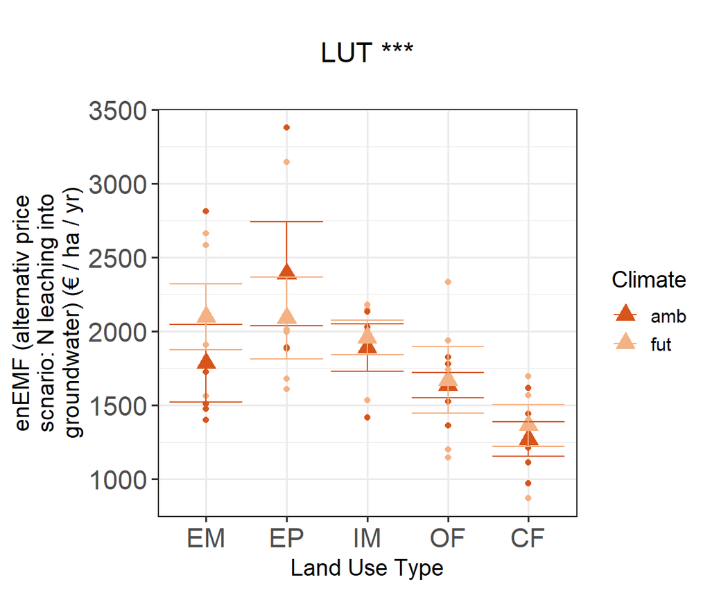

```r
Fig_enEMF_Groundwater_treatments
```

```r
Fig_enEMF_ETS_treatments <- ggplot(aes(x=LUT, y=enEMF_ETS, color=Climate),data=mf_data_lt)+
  geom_point()+
  scale_colour_manual(values=c("amb" = "#D7551B", "fut" = "#F4B183"))+
  stat_summary(
    geom = "point",
    fun.y = "mean",
    size = 4,
    shape = 17)+
  #ylim(500,3500)+
  stat_summary(fun.data = mean_se, geom = "errorbar")+ # add errorbar
  ylab("enEMF (alternative price\nscenario: EU CO2 market\nprice) (€ / ha / yr)")+
  xlab("Land Use Type")+
  ggtitle(paste(paste(ifelse(anova(lmer(enEMF_ETS ~ LUT * Climate + (1 | Mainplot), data = mf_data_lt))$"Pr(>F)"[3] <= 0.05, "LUT:Climate", ""),
                      ifelse(anova(lmer(enEMF_ETS ~ LUT * Climate + (1 | Mainplot), data = mf_data_lt))$"Pr(>F)"[3] <= 0.001, "***",
                             ifelse(anova(lmer(enEMF_ETS ~ LUT * Climate + (1 | Mainplot), data = mf_data_lt))$"Pr(>F)"[3] <= 0.01, "**",
                                    ifelse(anova(lmer(enEMF_ETS ~ LUT * Climate + (1 | Mainplot), data = mf_data_lt))$"Pr(>F)"[3] <= 0.05, "*", "")))),
                paste(ifelse(anova(lmer(enEMF_ETS ~ LUT * Climate + (1 | Mainplot), data = mf_data_lt))$"Pr(>F)"[1] <= 0.05, "LUT", ""),
                      ifelse(anova(lmer(enEMF_ETS ~ LUT * Climate + (1 | Mainplot), data = mf_data_lt))$"Pr(>F)"[1] <= 0.001, "***",
                             ifelse(anova(lmer(enEMF_ETS ~ LUT * Climate + (1 | Mainplot), data = mf_data_lt))$"Pr(>F)"[1] <= 0.01, "**",
                                    ifelse(anova(lmer(enEMF_ETS ~ LUT * Climate + (1 | Mainplot), data = mf_data_lt))$"Pr(>F)"[1] <= 0.05, "*", ""))),
                      sep=" "),paste(ifelse(anova(lmer(enEMF_ETS ~ LUT * Climate + (1 | Mainplot), data = mf_data_lt))$"Pr(>F)"[2] <= 0.05, "Climate", ""),
                                     ifelse(anova(lmer(enEMF_ETS ~ LUT * Climate + (1 | Mainplot), data = mf_data_lt))$"Pr(>F)"[2] <= 0.001, "***",
                                            ifelse(anova(lmer(enEMF_ETS ~ LUT * Climate + (1 | Mainplot), data = mf_data_lt))$"Pr(>F)"[2] <= 0.01, "**",
                                                   ifelse(anova(lmer(enEMF_ETS ~ LUT * Climate + (1 | Mainplot), data = mf_data_lt))$"Pr(>F)"[2] <= 0.05, "*", "")))), sep="\n"))+
  theme(plot.title = element_text(hjust = 0.5),
        axis.text.y = element_text(size=16),
        axis.text.x = element_text(size=16))

#ggsave("Fig_enEMF_ETS_treatments.pdf", Fig_enEMF_ETS_treatments, scale = 1, width = 5, height = 4, dpi=500, units="in")
```

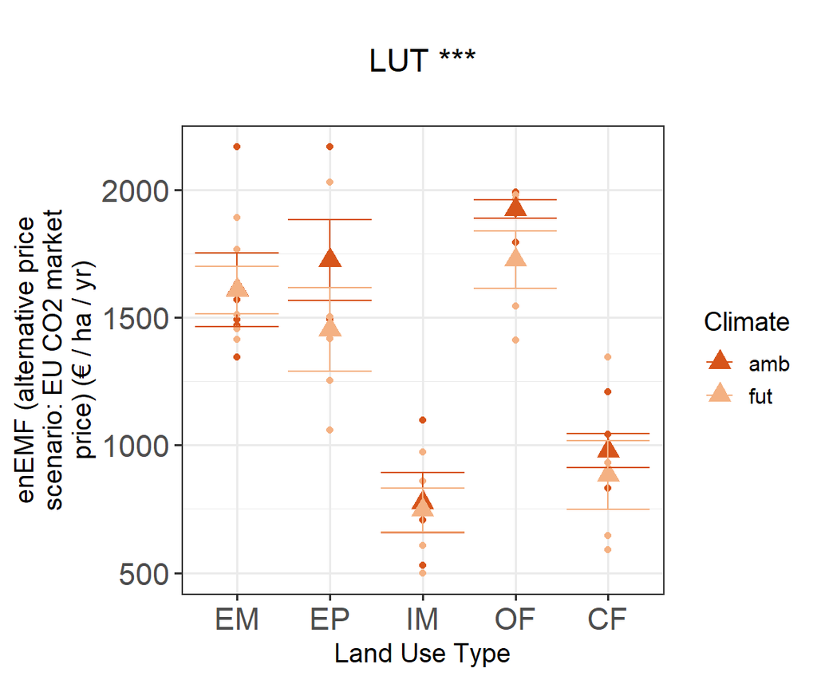

```r
Fig_enEMF_ETS_treatments
```

```r
Fig_enEMF_Kikstra_treatments <- ggplot(aes(x=LUT, y=enEMF_Kikstra, color=Climate),data=mf_data_lt)+
  geom_point()+
  scale_colour_manual(values=c("amb" = "#D7551B", "fut" = "#F4B183"))+
  stat_summary(
    geom = "point",
    fun.y = "mean",
    size = 4,
    shape = 17)+
  #ylim(500,3500)+
  stat_summary(fun.data = mean_se, geom = "errorbar")+ # add errorbar
  ylab("enEMF (alternativ price\nscnario: emission cost of\n280 €/tCO2eq) (€ / ha / yr)")+
  xlab("Land Use Type")+
  ggtitle(paste(paste(ifelse(anova(lmer(enEMF_Kikstra ~ LUT * Climate + (1 | Mainplot), data = mf_data_lt))$"Pr(>F)"[3] <= 0.05, "LUT:Climate", ""),
                      ifelse(anova(lmer(enEMF_Kikstra ~ LUT * Climate + (1 | Mainplot), data = mf_data_lt))$"Pr(>F)"[3] <= 0.001, "***",
                             ifelse(anova(lmer(enEMF_Kikstra ~ LUT * Climate + (1 | Mainplot), data = mf_data_lt))$"Pr(>F)"[3] <= 0.01, "**",
                                    ifelse(anova(lmer(enEMF_Kikstra ~ LUT * Climate + (1 | Mainplot), data = mf_data_lt))$"Pr(>F)"[3] <= 0.05, "*", "")))),
                paste(ifelse(anova(lmer(enEMF_Kikstra ~ LUT * Climate + (1 | Mainplot), data = mf_data_lt))$"Pr(>F)"[1] <= 0.05, "LUT", ""),
                      ifelse(anova(lmer(enEMF_Kikstra ~ LUT * Climate + (1 | Mainplot), data = mf_data_lt))$"Pr(>F)"[1] <= 0.001, "***",
                             ifelse(anova(lmer(enEMF_Kikstra ~ LUT * Climate + (1 | Mainplot), data = mf_data_lt))$"Pr(>F)"[1] <= 0.01, "**",
                                    ifelse(anova(lmer(enEMF_Kikstra ~ LUT * Climate + (1 | Mainplot), data = mf_data_lt))$"Pr(>F)"[1] <= 0.05, "*", ""))),
                      sep=" "),paste(ifelse(anova(lmer(enEMF_Kikstra ~ LUT * Climate + (1 | Mainplot), data = mf_data_lt))$"Pr(>F)"[2] <= 0.05, "Climate", ""),
                                     ifelse(anova(lmer(enEMF_Kikstra ~ LUT * Climate + (1 | Mainplot), data = mf_data_lt))$"Pr(>F)"[2] <= 0.001, "***",
                                            ifelse(anova(lmer(enEMF_Kikstra ~ LUT * Climate + (1 | Mainplot), data = mf_data_lt))$"Pr(>F)"[2] <= 0.01, "**",
                                                   ifelse(anova(lmer(enEMF_Kikstra ~ LUT * Climate + (1 | Mainplot), data = mf_data_lt))$"Pr(>F)"[2] <= 0.05, "*", "")))), sep="\n"))+
  theme(plot.title = element_text(hjust = 0.5),
        axis.text.y = element_text(size=16),
        axis.text.x = element_text(size=16))

#ggsave("Fig_enEMF_Kikstra_treatments.pdf", Fig_enEMF_Kikstra_treatments, scale = 1, width = 5, height = 4, dpi=500, units="in")
```

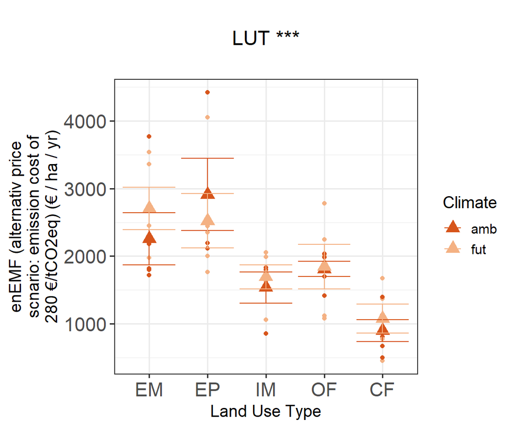

```r
Fig_enEMF_Kikstra_treatments
```

```r
Fig_enEMF_High_Yield_Cost_treatments <- ggplot(aes(x=LUT, y=enEMF_High_Yield_Cost, color=Climate),data=mf_data_lt)+
  geom_point()+
  scale_colour_manual(values=c("amb" = "#D7551B", "fut" = "#F4B183"))+
  stat_summary(
    geom = "point",
    fun.y = "mean",
    size = 4,
    shape = 17)+
  #ylim(500,3500)+
  stat_summary(fun.data = mean_se, geom = "errorbar")+ # add errorbar
  ylab("enEMF (alternative price\nscenario: 40% increase of\ncrop prices) (€ / ha / yr)")+
  xlab("Land Use Type")+
  ggtitle(paste(paste(ifelse(anova(lmer(enEMF_High_Yield_Cost ~ LUT * Climate + (1 | Mainplot), data = mf_data_lt))$"Pr(>F)"[3] <= 0.05, "LUT:Climate", ""),
                      ifelse(anova(lmer(enEMF_High_Yield_Cost ~ LUT * Climate + (1 | Mainplot), data = mf_data_lt))$"Pr(>F)"[3] <= 0.001, "***",
                             ifelse(anova(lmer(enEMF_High_Yield_Cost ~ LUT * Climate + (1 | Mainplot), data = mf_data_lt))$"Pr(>F)"[3] <= 0.01, "**",
                                    ifelse(anova(lmer(enEMF_High_Yield_Cost ~ LUT * Climate + (1 | Mainplot), data = mf_data_lt))$"Pr(>F)"[3] <= 0.05, "*", "")))),
                paste(ifelse(anova(lmer(enEMF_High_Yield_Cost ~ LUT * Climate + (1 | Mainplot), data = mf_data_lt))$"Pr(>F)"[1] <= 0.05, "LUT", ""),
                      ifelse(anova(lmer(enEMF_High_Yield_Cost ~ LUT * Climate + (1 | Mainplot), data = mf_data_lt))$"Pr(>F)"[1] <= 0.001, "***",
                             ifelse(anova(lmer(enEMF_High_Yield_Cost ~ LUT * Climate + (1 | Mainplot), data = mf_data_lt))$"Pr(>F)"[1] <= 0.01, "**",
                                    ifelse(anova(lmer(enEMF_High_Yield_Cost ~ LUT * Climate + (1 | Mainplot), data = mf_data_lt))$"Pr(>F)"[1] <= 0.05, "*", ""))),
                      sep=" "),paste(ifelse(anova(lmer(enEMF_High_Yield_Cost ~ LUT * Climate + (1 | Mainplot), data = mf_data_lt))$"Pr(>F)"[2] <= 0.05, "Climate", ""),
                                     ifelse(anova(lmer(enEMF_High_Yield_Cost ~ LUT * Climate + (1 | Mainplot), data = mf_data_lt))$"Pr(>F)"[2] <= 0.001, "***",
                                            ifelse(anova(lmer(enEMF_High_Yield_Cost ~ LUT * Climate + (1 | Mainplot), data = mf_data_lt))$"Pr(>F)"[2] <= 0.01, "**",
                                                   ifelse(anova(lmer(enEMF_High_Yield_Cost ~ LUT * Climate + (1 | Mainplot), data = mf_data_lt))$"Pr(>F)"[2] <= 0.05, "*", "")))), sep="\n"))+
  theme(plot.title = element_text(hjust = 0.5),
        axis.text.y = element_text(size=16),
        axis.text.x = element_text(size=16))

#ggsave("Fig_enEMF_High_Yield_Cost_treatments.pdf", Fig_enEMF_High_Yield_Cost_treatments, scale = 1, width = 5, height = 4, dpi=500, units="in")

Fig_enEMF_Alternative <- ggarrange(Fig_enEMF_Groundwater_treatments, Fig_enEMF_ETS_treatments, Fig_enEMF_Kikstra_treatments, Fig_enEMF_High_Yield_Cost_treatments, ncol = 2, nrow = 2, labels = "auto", font.label = list(size = 24), common.legend = TRUE, legend = "bottom")

ggsave("Figure_S3_enEMF_Alternative.pdf", Fig_enEMF_Alternative, scale = 1, width = 8, height = 8, dpi=500, units="in")
```

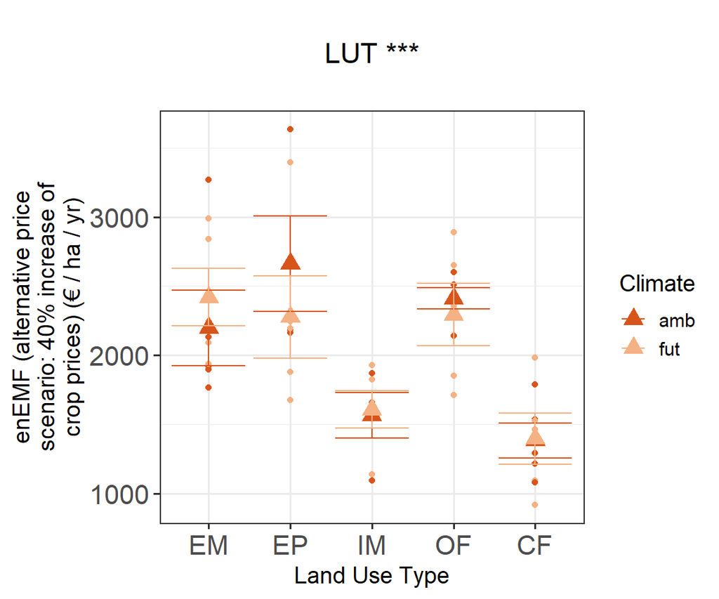

```r
Fig_enEMF_High_Yield_Cost_treatments
```

```r
Fig_enEMF_Farmers_treatments <- ggplot(aes(x=LUT, y=enEMF_Farmers, color=Climate),data=mf_data_lt)+
  geom_point()+
  scale_colour_manual(values=c("amb" = "#D7551B", "fut" = "#F4B183"))+
  stat_summary(
    geom = "point",
    fun.y = "mean",
    size = 4,
    shape = 17)+
  #ylim(500,3500)+
  stat_summary(fun.data = mean_se, geom = "errorbar")+ # add errorbar
  ylab("enEMF (farmers)\n(€ / ha / yr)")+
  xlab("Land Use Type")+
  ggtitle(paste(paste(ifelse(anova(lmer(enEMF_Farmers ~ LUT * Climate + (1 | Mainplot), data = mf_data_lt))$"Pr(>F)"[3] <= 0.05, "LUT:Climate", ""),
                      ifelse(anova(lmer(enEMF_Farmers ~ LUT * Climate + (1 | Mainplot), data = mf_data_lt))$"Pr(>F)"[3] <= 0.001, "***",
                             ifelse(anova(lmer(enEMF_Farmers ~ LUT * Climate + (1 | Mainplot), data = mf_data_lt))$"Pr(>F)"[3] <= 0.01, "**",
                                    ifelse(anova(lmer(enEMF_Farmers ~ LUT * Climate + (1 | Mainplot), data = mf_data_lt))$"Pr(>F)"[3] <= 0.05, "*", "")))),
                paste(ifelse(anova(lmer(enEMF_Farmers ~ LUT * Climate + (1 | Mainplot), data = mf_data_lt))$"Pr(>F)"[1] <= 0.05, "LUT", ""),
                      ifelse(anova(lmer(enEMF_Farmers ~ LUT * Climate + (1 | Mainplot), data = mf_data_lt))$"Pr(>F)"[1] <= 0.001, "***",
                             ifelse(anova(lmer(enEMF_Farmers ~ LUT * Climate + (1 | Mainplot), data = mf_data_lt))$"Pr(>F)"[1] <= 0.01, "**",
                                    ifelse(anova(lmer(enEMF_Farmers ~ LUT * Climate + (1 | Mainplot), data = mf_data_lt))$"Pr(>F)"[1] <= 0.05, "*", ""))),
                      sep=" "),paste(ifelse(anova(lmer(enEMF_Farmers ~ LUT * Climate + (1 | Mainplot), data = mf_data_lt))$"Pr(>F)"[2] <= 0.05, "Climate", ""),
                                     ifelse(anova(lmer(enEMF_Farmers ~ LUT * Climate + (1 | Mainplot), data = mf_data_lt))$"Pr(>F)"[2] <= 0.001, "***",
                                            ifelse(anova(lmer(enEMF_Farmers ~ LUT * Climate + (1 | Mainplot), data = mf_data_lt))$"Pr(>F)"[2] <= 0.01, "**",
                                                   ifelse(anova(lmer(enEMF_Farmers ~ LUT * Climate + (1 | Mainplot), data = mf_data_lt))$"Pr(>F)"[2] <= 0.05, "*", "")))), sep="\n"))+
  theme(plot.title = element_text(hjust = 0.5),
        axis.text.y = element_text(size=16),
        axis.text.x = element_text(size=16))

#ggsave("Fig_enEMF_Farmers_treatments.pdf", Fig_enEMF_Farmers_treatments, scale = 1, width = 5, height = 4, dpi=500, units="in")


Figure_5_enEMF_enEMF_Farmers <- ggarrange(Fig_enEMF_treatments, Fig_enEMF_Farmers_treatments, ncol = 2, nrow = 1, labels = "auto", font.label = list(size = 24), common.legend = TRUE, legend = "bottom")

ggsave("Figure_5_enEMF_enEMF_Farmers.pdf", Figure_5_enEMF_enEMF_Farmers, scale = 1, width = 7.5, height = 4, dpi=500, units="in")
```

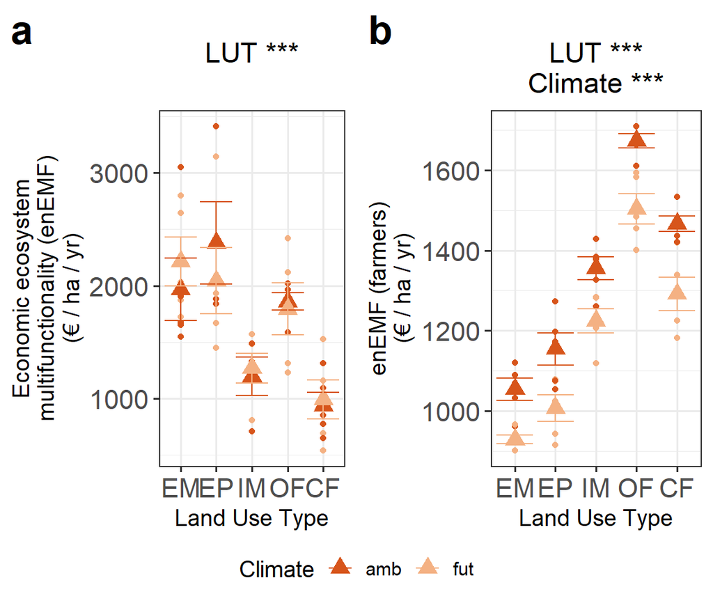

```r
Figure_5_enEMF_enEMF_Farmers
```

Calculate contribution of individual ecosystem services to enEMF:

```r
new <- data.frame(matrix(nrow=25, ncol=6))
colnames(new) <- c("LUT", "Service", "Value", "Value_Percent", "enEMF", "Land_rent")
new$LUT <- rep(c("EM", "EP", "IM", "OF", "CF"), each=5)
new$LUT <- factor(new$LUT, levels=LUTs)
new$Service <-  rep(c("Food", "Climate_reg", "Water", "Soil_Health", "Biodiversity"))

#Land_rent <- c()
#348 € / ha / yr for grassland, 574 € / ha / yr for farmland in 2019) (MULE 2020
for (i in 1:25){
  new$Value[i] <- ifelse(new$Service[i] == "Food", mean(mf_data_lt$Yield[mf_data_lt$LUT==new$LUT[i]], na.rm=TRUE),
                         ifelse(new$Service[i] == "Climate_reg", mean(mf_data_lt$TOC_Euro[mf_data_lt$LUT==new$LUT[i]], na.rm=TRUE),
                                ifelse(new$Service[i] == "Water", mean(mf_data_lt$Nmin_Surplus_Euro[mf_data_lt$LUT==new$LUT[i]], na.rm=TRUE),
                                       ifelse(new$Service[i] == "Soil_Health", mean(mf_data_lt$IS[mf_data_lt$LUT==new$LUT[i]], na.rm=TRUE),
                                              mean(mf_data_lt$IB[mf_data_lt$LUT==new$LUT[i]], na.rm=TRUE)))))
}




for (i in 1:25){
  new$Value_Percent[i] <- abs(new$Value[i]) / sum(abs(new$Value[new$LUT==new$LUT[i]]))
  new$enEMF[i] <- ifelse(i %in% c(2,3,4,5,7,8,9,10,12,13,14,15,17,18,19,20,22,23,24,25), NA, sum(new$Value[new$LUT==new$LUT[i]]))
  new$enEMF_Farmers[i] <- ifelse(i %in% c(2,3,4,5,7,8,9,10,12,13,14,15,17,18,19,20,22,23,24,25), NA, sum(new$Value[new$LUT==new$LUT[i] & new$Service=="Food" | new$LUT==new$LUT[i] & new$Service=="Soil_Health" | new$LUT==new$LUT[i] & new$Service=="Biodiversity"]))
  new$Land_rent[i] <- ifelse((new$LUT[i] == "EM" | new$LUT[i] == "IM" | new$LUT[i] == "EP"), 348, 574)
  new$Land_rent[i] <- ifelse(i %in% c(2,3,4,5,7,8,9,10,12,13,14,15,17,18,19,20,22,23,24,25), NA, new$Land_rent[i])
}


Figure_4_enEMF_Stacked <- ggplot(aes(x=LUT, y=Value, fill=Service), data=new)+
  geom_bar(position="stack", stat="identity")+
  scale_fill_manual(values=c("Food" = "#f9e26e"  , "Climate_reg" = "#bde2ea", "Water" = "#a1ccee", "Soil_Health" = "#d8bb75", "Biodiversity" = "#c3d984"))+
  geom_text(aes(label = paste0(round(Value,0), "\n(", 100*round(Value_Percent,3), "%)")),
            position = position_stack(vjust = 0.5), size = 2.5)+
  geom_text(aes(label = round(enEMF, 0), angle=45,
                y = enEMF+100),
            col="#387880", size=3.8, hjust=0)+
  #geom_text(aes(label = Land_rent, angle=45, y = Land_rent+100),col="red", size=3.8, hjust=0)+ # information regarding land rent not necessary
  xlab("LUT")+
  ylab("Ecosystem service value\n(€ / ha / yr)")+
  geom_errorbar(aes(y=enEMF, ymin=enEMF, ymax=enEMF), size=2.2, color="#387880")+
  geom_text(aes(label = round(enEMF_Farmers, 0), angle=45,
                y = enEMF_Farmers+100),
            col="#8a5b41", size=3.8, hjust=0)+
  geom_errorbar(aes(y=enEMF_Farmers, ymin=enEMF_Farmers, ymax=enEMF_Farmers), size=2.2, color="#8a5b41")+
  #geom_errorbar(aes(y=Land_rent, ymin=Land_rent, ymax=Land_rent), size=2.2, color="red") # information regarding land rent not necessary

write.csv(new,"enEMF_Overview.csv")
```

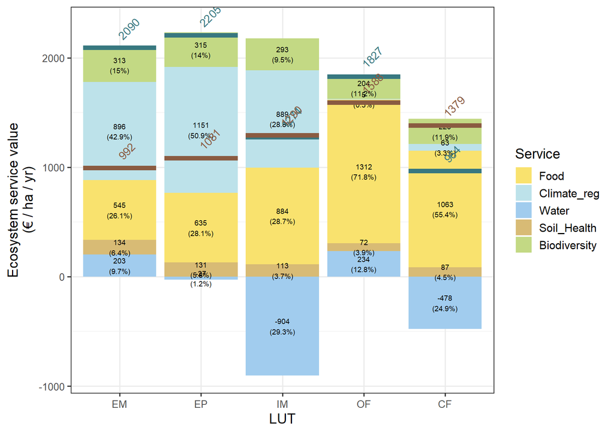

```r
Figure_4_enEMF_Stacked
```

```r
# Blue bars indicate enEMF, brown bars indicate enEMF for farmers.
```

```r
Reg_table_enEMF <- c(round(anova(lmer(enEMF ~ LUT * Climate + (1 | Mainplot), data = mf_data_lt))$"F value"[1], digits=3),
                        round(anova(lmer(enEMF ~ LUT * Climate + (1 | Mainplot), data = mf_data_lt))$"Pr(>F)"[1], digits=3),
                        ifelse(anova(lmer(enEMF ~ LUT * Climate + (1 | Mainplot), data = mf_data_lt))$"Pr(>F)"[1] <= 0.001, "***",
                               ifelse(anova(lmer(enEMF ~ LUT * Climate + (1 | Mainplot), data = mf_data_lt))$"Pr(>F)"[1] <= 0.01, "**",
                                      ifelse(anova(lmer(enEMF ~ LUT * Climate + (1 | Mainplot), data = mf_data_lt))$"Pr(>F)"[1] <= 0.05, "*", ""))),
                        round(anova(lmer(enEMF ~ LUT * Climate + (1 | Mainplot), data = mf_data_lt))$"F value"[2], digits=3),
                        round(anova(lmer(enEMF ~ LUT * Climate + (1 | Mainplot), data = mf_data_lt))$"Pr(>F)"[2],digits = 3),
                        ifelse(anova(lmer(enEMF ~ LUT * Climate + (1 | Mainplot), data = mf_data_lt))$"Pr(>F)"[2] <= 0.001, "***",
                               ifelse(anova(lmer(enEMF ~ LUT * Climate + (1 | Mainplot), data = mf_data_lt))$"Pr(>F)"[2] <= 0.01, "**",
                                      ifelse(anova(lmer(enEMF ~ LUT * Climate + (1 | Mainplot), data = mf_data_lt))$"Pr(>F)"[2] <= 0.05, "*", ""))),
                        round(anova(lmer(enEMF ~ LUT * Climate + (1 | Mainplot), data = mf_data_lt))$"F value"[3],digits = 3),
                        round(anova(lmer(enEMF ~ LUT * Climate + (1 | Mainplot), data = mf_data_lt))$"Pr(>F)"[3],digits=3),
                        ifelse(anova(lmer(enEMF ~ LUT * Climate + (1 | Mainplot), data = mf_data_lt))$"Pr(>F)"[3] <= 0.001, "***",
                               ifelse(anova(lmer(enEMF ~ LUT * Climate + (1 | Mainplot), data = mf_data_lt))$"Pr(>F)"[3] <= 0.01, "**",
                                      ifelse(anova(lmer(enEMF ~ LUT * Climate + (1 | Mainplot), data = mf_data_lt))$"Pr(>F)"[3] <= 0.05, "*", ""))))


Reg_table_enEMF_Farmers <- c(round(anova(lmer(enEMF_Farmers ~ LUT * Climate + (1 | Mainplot), data = mf_data_lt))$"F value"[1], digits=3),
                   round(anova(lmer(enEMF_Farmers ~ LUT * Climate + (1 | Mainplot), data = mf_data_lt))$"Pr(>F)"[1], digits=3),
                   ifelse(anova(lmer(enEMF_Farmers ~ LUT * Climate + (1 | Mainplot), data = mf_data_lt))$"Pr(>F)"[1] <= 0.001, "***",
                          ifelse(anova(lmer(enEMF_Farmers ~ LUT * Climate + (1 | Mainplot), data = mf_data_lt))$"Pr(>F)"[1] <= 0.01, "**",
                                 ifelse(anova(lmer(enEMF_Farmers ~ LUT * Climate + (1 | Mainplot), data = mf_data_lt))$"Pr(>F)"[1] <= 0.05, "*", ""))),
                   round(anova(lmer(enEMF_Farmers ~ LUT * Climate + (1 | Mainplot), data = mf_data_lt))$"F value"[2], digits=3),
                   round(anova(lmer(enEMF_Farmers ~ LUT * Climate + (1 | Mainplot), data = mf_data_lt))$"Pr(>F)"[2],digits = 3),
                   ifelse(anova(lmer(enEMF_Farmers ~ LUT * Climate + (1 | Mainplot), data = mf_data_lt))$"Pr(>F)"[2] <= 0.001, "***",
                          ifelse(anova(lmer(enEMF_Farmers ~ LUT * Climate + (1 | Mainplot), data = mf_data_lt))$"Pr(>F)"[2] <= 0.01, "**",
                                 ifelse(anova(lmer(enEMF_Farmers ~ LUT * Climate + (1 | Mainplot), data = mf_data_lt))$"Pr(>F)"[2] <= 0.05, "*", ""))),
                   round(anova(lmer(enEMF_Farmers ~ LUT * Climate + (1 | Mainplot), data = mf_data_lt))$"F value"[3],digits = 3),
                   round(anova(lmer(enEMF_Farmers ~ LUT * Climate + (1 | Mainplot), data = mf_data_lt))$"Pr(>F)"[3],digits=3),
                   ifelse(anova(lmer(enEMF_Farmers ~ LUT * Climate + (1 | Mainplot), data = mf_data_lt))$"Pr(>F)"[3] <= 0.001, "***",
                          ifelse(anova(lmer(enEMF_Farmers ~ LUT * Climate + (1 | Mainplot), data = mf_data_lt))$"Pr(>F)"[3] <= 0.01, "**",
                                 ifelse(anova(lmer(enEMF_Farmers ~ LUT * Climate + (1 | Mainplot), data = mf_data_lt))$"Pr(>F)"[3] <= 0.05, "*", ""))))

Reg_table_enEMF_enEMF_Farmers <- data.frame(matrix(nrow=2, ncol=10))
colnames(Reg_table_enEMF_enEMF_Farmers) <- c("Scenario", "LUT F value", "LUT p value", "LUT sig", "Climate F value", "Climate p value", "Climate sig", "LUT:Climate F value", "LUT:Climate p value", "LUT:Climate sig")
Reg_table_enEMF_enEMF_Farmers[1,2:10] <- Reg_table_enEMF
Reg_table_enEMF_enEMF_Farmers[2,2:10] <- Reg_table_enEMF_Farmers
Reg_table_enEMF_enEMF_Farmers$Scenario <- c("enEMF", "enEMF_Farmers")

write.csv(Reg_table_enEMF_enEMF_Farmers, "Table_S6_Regression_table_enEMF_enEMF_Farmers.csv")
Reg_table_enEMF_enEMF_Farmers
```

```
##        Scenario LUT F value LUT p value LUT sig Climate F value Climate p value
## 1         enEMF      14.937           0     ***               0           0.997
## 2 enEMF_Farmers     153.029           0     ***          34.559               0
##   Climate sig LUT:Climate F value LUT:Climate p value LUT:Climate sig
## 1                           0.564               0.691
## 2         ***               0.329               0.856
```

Linear mixed-effects regression tables for annex:

```r
# alternative CO2 price (ETS)
Reg_table_enEMF_ETS <- c(round(anova(lmer(enEMF_ETS ~ LUT * Climate + (1 | Mainplot), data = mf_data_lt))$"F value"[1], digits=3),
                   round(anova(lmer(enEMF_ETS ~ LUT * Climate + (1 | Mainplot), data = mf_data_lt))$"Pr(>F)"[1], digits=3),
                   ifelse(anova(lmer(enEMF_ETS ~ LUT * Climate + (1 | Mainplot), data = mf_data_lt))$"Pr(>F)"[1] <= 0.001, "***",
                          ifelse(anova(lmer(enEMF_ETS ~ LUT * Climate + (1 | Mainplot), data = mf_data_lt))$"Pr(>F)"[1] <= 0.01, "**",
                                 ifelse(anova(lmer(enEMF_ETS ~ LUT * Climate + (1 | Mainplot), data = mf_data_lt))$"Pr(>F)"[1] <= 0.05, "*", ""))),
                   round(anova(lmer(enEMF_ETS ~ LUT * Climate + (1 | Mainplot), data = mf_data_lt))$"F value"[2], digits=3),
                   round(anova(lmer(enEMF_ETS ~ LUT * Climate + (1 | Mainplot), data = mf_data_lt))$"Pr(>F)"[2],digits = 3),
                   ifelse(anova(lmer(enEMF_ETS ~ LUT * Climate + (1 | Mainplot), data = mf_data_lt))$"Pr(>F)"[2] <= 0.001, "***",
                          ifelse(anova(lmer(enEMF_ETS ~ LUT * Climate + (1 | Mainplot), data = mf_data_lt))$"Pr(>F)"[2] <= 0.01, "**",
                                 ifelse(anova(lmer(enEMF_ETS ~ LUT * Climate + (1 | Mainplot), data = mf_data_lt))$"Pr(>F)"[2] <= 0.05, "*", ""))),
                   round(anova(lmer(enEMF_ETS ~ LUT * Climate + (1 | Mainplot), data = mf_data_lt))$"F value"[3],digits = 3),
                   round(anova(lmer(enEMF_ETS ~ LUT * Climate + (1 | Mainplot), data = mf_data_lt))$"Pr(>F)"[3],digits=3),
                   ifelse(anova(lmer(enEMF_ETS ~ LUT * Climate + (1 | Mainplot), data = mf_data_lt))$"Pr(>F)"[3] <= 0.001, "***",
                          ifelse(anova(lmer(enEMF_ETS ~ LUT * Climate + (1 | Mainplot), data = mf_data_lt))$"Pr(>F)"[3] <= 0.01, "**",
                                 ifelse(anova(lmer(enEMF_ETS ~ LUT * Climate + (1 | Mainplot), data = mf_data_lt))$"Pr(>F)"[3] <= 0.05, "*", ""))))




# alternative nitrogen leaching price (1.9 €/t)

Reg_table_enEMF_Groundwater <- c(round(anova(lmer(enEMF_Groundwater ~ LUT * Climate + (1 | Mainplot), data = mf_data_lt))$"F value"[1], digits=3),
                   round(anova(lmer(enEMF_Groundwater ~ LUT * Climate + (1 | Mainplot), data = mf_data_lt))$"Pr(>F)"[1], digits=3),
                   ifelse(anova(lmer(enEMF_Groundwater ~ LUT * Climate + (1 | Mainplot), data = mf_data_lt))$"Pr(>F)"[1] <= 0.001, "***",
                          ifelse(anova(lmer(enEMF_Groundwater ~ LUT * Climate + (1 | Mainplot), data = mf_data_lt))$"Pr(>F)"[1] <= 0.01, "**",
                                 ifelse(anova(lmer(enEMF_Groundwater ~ LUT * Climate + (1 | Mainplot), data = mf_data_lt))$"Pr(>F)"[1] <= 0.05, "*", ""))),
                   round(anova(lmer(enEMF_Groundwater ~ LUT * Climate + (1 | Mainplot), data = mf_data_lt))$"F value"[2], digits=3),
                   round(anova(lmer(enEMF_Groundwater ~ LUT * Climate + (1 | Mainplot), data = mf_data_lt))$"Pr(>F)"[2],digits = 3),
                   ifelse(anova(lmer(enEMF_Groundwater ~ LUT * Climate + (1 | Mainplot), data = mf_data_lt))$"Pr(>F)"[2] <= 0.001, "***",
                          ifelse(anova(lmer(enEMF_Groundwater ~ LUT * Climate + (1 | Mainplot), data = mf_data_lt))$"Pr(>F)"[2] <= 0.01, "**",
                                 ifelse(anova(lmer(enEMF_Groundwater ~ LUT * Climate + (1 | Mainplot), data = mf_data_lt))$"Pr(>F)"[2] <= 0.05, "*", ""))),
                   round(anova(lmer(enEMF_Groundwater ~ LUT * Climate + (1 | Mainplot), data = mf_data_lt))$"F value"[3],digits = 3),
                   round(anova(lmer(enEMF_Groundwater ~ LUT * Climate + (1 | Mainplot), data = mf_data_lt))$"Pr(>F)"[3],digits=3),
                   ifelse(anova(lmer(enEMF_Groundwater ~ LUT * Climate + (1 | Mainplot), data = mf_data_lt))$"Pr(>F)"[3] <= 0.001, "***",
                          ifelse(anova(lmer(enEMF_Groundwater ~ LUT * Climate + (1 | Mainplot), data = mf_data_lt))$"Pr(>F)"[3] <= 0.01, "**",
                                 ifelse(anova(lmer(enEMF_Groundwater ~ LUT * Climate + (1 | Mainplot), data = mf_data_lt))$"Pr(>F)"[3] <= 0.05, "*", ""))))


# alternative co2 price (Kikstra)

Reg_table_enEMF_Kikstra <- c(round(anova(lmer(enEMF_Kikstra ~ LUT * Climate + (1 | Mainplot), data = mf_data_lt))$"F value"[1], digits=3),
                   round(anova(lmer(enEMF_Kikstra ~ LUT * Climate + (1 | Mainplot), data = mf_data_lt))$"Pr(>F)"[1], digits=3),
                   ifelse(anova(lmer(enEMF_Kikstra ~ LUT * Climate + (1 | Mainplot), data = mf_data_lt))$"Pr(>F)"[1] <= 0.001, "***",
                          ifelse(anova(lmer(enEMF_Kikstra ~ LUT * Climate + (1 | Mainplot), data = mf_data_lt))$"Pr(>F)"[1] <= 0.01, "**",
                                 ifelse(anova(lmer(enEMF_Kikstra ~ LUT * Climate + (1 | Mainplot), data = mf_data_lt))$"Pr(>F)"[1] <= 0.05, "*", ""))),
                   round(anova(lmer(enEMF_Kikstra ~ LUT * Climate + (1 | Mainplot), data = mf_data_lt))$"F value"[2], digits=3),
                   round(anova(lmer(enEMF_Kikstra ~ LUT * Climate + (1 | Mainplot), data = mf_data_lt))$"Pr(>F)"[2],digits = 3),
                   ifelse(anova(lmer(enEMF_Kikstra ~ LUT * Climate + (1 | Mainplot), data = mf_data_lt))$"Pr(>F)"[2] <= 0.001, "***",
                          ifelse(anova(lmer(enEMF_Kikstra ~ LUT * Climate + (1 | Mainplot), data = mf_data_lt))$"Pr(>F)"[2] <= 0.01, "**",
                                 ifelse(anova(lmer(enEMF_Kikstra ~ LUT * Climate + (1 | Mainplot), data = mf_data_lt))$"Pr(>F)"[2] <= 0.05, "*", ""))),
                   round(anova(lmer(enEMF_Kikstra ~ LUT * Climate + (1 | Mainplot), data = mf_data_lt))$"F value"[3],digits = 3),
                   round(anova(lmer(enEMF_Kikstra ~ LUT * Climate + (1 | Mainplot), data = mf_data_lt))$"Pr(>F)"[3],digits=3),
                   ifelse(anova(lmer(enEMF_Kikstra ~ LUT * Climate + (1 | Mainplot), data = mf_data_lt))$"Pr(>F)"[3] <= 0.001, "***",
                          ifelse(anova(lmer(enEMF_Kikstra ~ LUT * Climate + (1 | Mainplot), data = mf_data_lt))$"Pr(>F)"[3] <= 0.01, "**",
                                 ifelse(anova(lmer(enEMF_Kikstra ~ LUT * Climate + (1 | Mainplot), data = mf_data_lt))$"Pr(>F)"[3] <= 0.05, "*", ""))))

# higher yield prices (40%)


Reg_table_enEMF_High_Yield_Cost <- c(round(anova(lmer(enEMF_High_Yield_Cost ~ LUT * Climate + (1 | Mainplot), data = mf_data_lt))$"F value"[1], digits=3),
                   round(anova(lmer(enEMF_High_Yield_Cost ~ LUT * Climate + (1 | Mainplot), data = mf_data_lt))$"Pr(>F)"[1], digits=3),
                   ifelse(anova(lmer(enEMF_High_Yield_Cost ~ LUT * Climate + (1 | Mainplot), data = mf_data_lt))$"Pr(>F)"[1] <= 0.001, "***",
                          ifelse(anova(lmer(enEMF_High_Yield_Cost ~ LUT * Climate + (1 | Mainplot), data = mf_data_lt))$"Pr(>F)"[1] <= 0.01, "**",
                                 ifelse(anova(lmer(enEMF_High_Yield_Cost ~ LUT * Climate + (1 | Mainplot), data = mf_data_lt))$"Pr(>F)"[1] <= 0.05, "*", ""))),
                   round(anova(lmer(enEMF_High_Yield_Cost ~ LUT * Climate + (1 | Mainplot), data = mf_data_lt))$"F value"[2], digits=3),
                   round(anova(lmer(enEMF_High_Yield_Cost ~ LUT * Climate + (1 | Mainplot), data = mf_data_lt))$"Pr(>F)"[2],digits = 3),
                   ifelse(anova(lmer(enEMF_High_Yield_Cost ~ LUT * Climate + (1 | Mainplot), data = mf_data_lt))$"Pr(>F)"[2] <= 0.001, "***",
                          ifelse(anova(lmer(enEMF_High_Yield_Cost ~ LUT * Climate + (1 | Mainplot), data = mf_data_lt))$"Pr(>F)"[2] <= 0.01, "**",
                                 ifelse(anova(lmer(enEMF_High_Yield_Cost ~ LUT * Climate + (1 | Mainplot), data = mf_data_lt))$"Pr(>F)"[2] <= 0.05, "*", ""))),
                   round(anova(lmer(enEMF_High_Yield_Cost ~ LUT * Climate + (1 | Mainplot), data = mf_data_lt))$"F value"[3],digits = 3),
                   round(anova(lmer(enEMF_High_Yield_Cost ~ LUT * Climate + (1 | Mainplot), data = mf_data_lt))$"Pr(>F)"[3],digits=3),
                   ifelse(anova(lmer(enEMF_High_Yield_Cost ~ LUT * Climate + (1 | Mainplot), data = mf_data_lt))$"Pr(>F)"[3] <= 0.001, "***",
                          ifelse(anova(lmer(enEMF_High_Yield_Cost ~ LUT * Climate + (1 | Mainplot), data = mf_data_lt))$"Pr(>F)"[3] <= 0.01, "**",
                                 ifelse(anova(lmer(enEMF_High_Yield_Cost ~ LUT * Climate + (1 | Mainplot), data = mf_data_lt))$"Pr(>F)"[3] <= 0.05, "*", ""))))

Regression_table_enEMF_alternative_price_Scenarios <- data.frame(matrix(nrow=1, ncol=10))
colnames(Regression_table_enEMF_alternative_price_Scenarios) <- c("Scenario", "LUT F value", "LUT p value", "LUT sig", "Climate F value", "Climate p value", "Climate sig", "LUT:Climate F value", "LUT:Climate p value", "LUT:Climate sig")
Regression_table_enEMF_alternative_price_Scenarios[1,2:10] <- Reg_table_enEMF_ETS
Regression_table_enEMF_alternative_price_Scenarios[2,2:10] <- Reg_table_enEMF_Groundwater
Regression_table_enEMF_alternative_price_Scenarios[3,2:10] <- Reg_table_enEMF_Kikstra
Regression_table_enEMF_alternative_price_Scenarios[4,2:10] <- Reg_table_enEMF_High_Yield_Cost
Regression_table_enEMF_alternative_price_Scenarios$Scenario <- c("enEMF_ETC", "enEMF_Groundwater", "enEMF_Kikstra", "enEMF_High_Yield_Cost")


write.csv(Regression_table_enEMF_alternative_price_Scenarios, "Table_S9_Regression_table_enEMF_alternative_price_Scenarios.csv")
Regression_table_enEMF_alternative_price_Scenarios
```

```
##                Scenario LUT F value LUT p value LUT sig Climate F value
## 1             enEMF_ETC      37.589           0     ***           1.548
## 2     enEMF_Groundwater       6.385       0.001     ***           0.083
## 3         enEMF_Kikstra      12.376           0     ***           0.152
## 4 enEMF_High_Yield_Cost      12.348           0     ***           0.052
##   Climate p value Climate sig LUT:Climate F value LUT:Climate p value
## 1           0.248                           0.545               0.704
## 2            0.78                           0.619               0.652
## 3           0.707                           0.574               0.684
## 4           0.825                           0.615               0.655
##   LUT:Climate sig
## 1
## 2
## 3
## 4
```

```r
ggsave("Figure_4_enEMF_Stacked.pdf", Figure_4_enEMF_Stacked, scale = 1, width = 8.5, height = 6, dpi=500, units="in")
```

Conduct a sensitivity analysis for the dependency of the insurance value of soil health / biodiversity on the value for risk aversion r: The insurance value IV of soil health SH at the level i SH(i) was calculated as the RP at SH(0) and M(i) minus the RP at SH(i) and M(i). For biodiversity, vice versa. IV(SH[i]) <- RP(SH=0, M[i]) - RP(SH[i], M[i]) AND IV(M[i]) <- RP(SH[i], M=0) - RP(SH[i], M[i])

```r
sensitivity_to_r <- data.frame(matrix(nrow=16, ncol=3))
colnames(sensitivity_to_r) <- c("r", "mean_IB", "mean_IS")
sensitivity_to_r$r <- seq(0,1.5,by=0.1)

for (i in 1:16){
  for (j in 1:50){
    mf_data_lt$RP[j] <- mf_data_lt$Yield[j] - mf_data_lt$Yield[j] * (((1 + (cv(mf_data_big$Yield[mf_data_big$Plot==mf_data_lt$Plot[j]])))^2)^(-(sensitivity_to_r$r[i])/2))
  }
  screening <-lm(RP ~ Soil_Health+Multidiv, data = mf_data_lt)
  centcomp <- lm(RP ~ Soil_Health*Multidiv + I(Soil_Health^2) + I(Multidiv^2), data = mf_data_lt)
  centcomp_results = data.frame(mf_data_lt$RP, centcomp$fitted.values, mf_data_lt$RP - centcomp$fitted.values)
  colnames(centcomp_results) = c("expt RP", "pred RP", "residual error")
  x1_axis <- seq(0.1,0.7,0.012) # based on min and max values of soil health
  x2_axis <- seq(0.4,0.9,0.01) # based on min and max values of biodiversity
  response = function(x,y){coef(centcomp)[1] + coef(centcomp)[2]*x + coef(centcomp)[3]*y + coef(centcomp)[4]*x^2 + coef(centcomp)[5]*y^2 + coef(centcomp)[6]*x*y}
  for (j in 1:50){
    mf_data_lt$IB[j] <- (coef(centcomp)[1] + coef(centcomp)[2]*mf_data_lt$Soil_Health[j] + coef(centcomp)[3]*0 + coef(centcomp)[4]*mf_data_lt$Soil_Health[j]^2 + coef(centcomp)[5]*0^2 + coef(centcomp)[6]*mf_data_lt$Soil_Health[j]*0) - (coef(centcomp)[1] + coef(centcomp)[2]*mf_data_lt$Soil_Health[j] + coef(centcomp)[3]*mf_data_lt$Multidiv[j] + coef(centcomp)[4]*mf_data_lt$Soil_Health[j]^2 + coef(centcomp)[5]*mf_data_lt$Multidiv[j]^2 + coef(centcomp)[6]*mf_data_lt$Soil_Health[j]*mf_data_lt$Multidiv[j])
    mf_data_lt$IS[j] <- (coef(centcomp)[1] + coef(centcomp)[2]*0 + coef(centcomp)[3]*mf_data_lt$Multidiv[j] + coef(centcomp)[4]*0^2 + coef(centcomp)[5]*mf_data_lt$Multidiv[j]^2 + coef(centcomp)[6]*0*mf_data_lt$Multidiv[j]) - (coef(centcomp)[1] + coef(centcomp)[2]*mf_data_lt$Soil_Health[j] + coef(centcomp)[3]*mf_data_lt$Multidiv[j] + coef(centcomp)[4]*mf_data_lt$Soil_Health[j]^2 + coef(centcomp)[5]*mf_data_lt$Multidiv[j]^2 + coef(centcomp)[6]*mf_data_lt$Soil_Health[j]*mf_data_lt$Multidiv[j])
  }
  sensitivity_to_r$mean_IB[i] <- mean(mf_data_lt$IB)
  sensitivity_to_r$mean_IS[i] <- mean(mf_data_lt$IS)
}

sensitivity_to_r.2 <- data.frame(matrix(nrow=nrow(sensitivity_to_r)*2, ncol=3))
colnames(sensitivity_to_r.2) <- c("r", "Service_Insurance", "Mean_Insurance_Value")
sensitivity_to_r.2$r <- sensitivity_to_r$r
sensitivity_to_r.2$Service_Insurance <- rep(c("Multidiversity", "Soil_Health"), each=nrow(sensitivity_to_r))

sensitivity_to_r.2$Mean_Insurance_Value[sensitivity_to_r.2$Service_Insurance=="Multidiversity"] <- sensitivity_to_r$mean_IB

sensitivity_to_r.2$Mean_Insurance_Value[sensitivity_to_r.2$Service_Insurance=="Soil_Health"] <- sensitivity_to_r$mean_IS

Insurance_Sensitivity <- ggplot(sensitivity_to_r.2, aes(x=r, y=Mean_Insurance_Value, color=Service_Insurance))+
  geom_smooth(span=0.5)+
  ylab("Insurance value (€ / ha / yr)\n(mean of all plots)")+
  xlab("Risk aversion r")+
  geom_vline(xintercept = 0.28, linetype="solid", color = "black", size=0.5)

ggsave("Figure_S5_Insurance_Sensitivity.pdf", Insurance_Sensitivity, scale = 1, width = 7, height = 4, dpi=500, units="in")
```

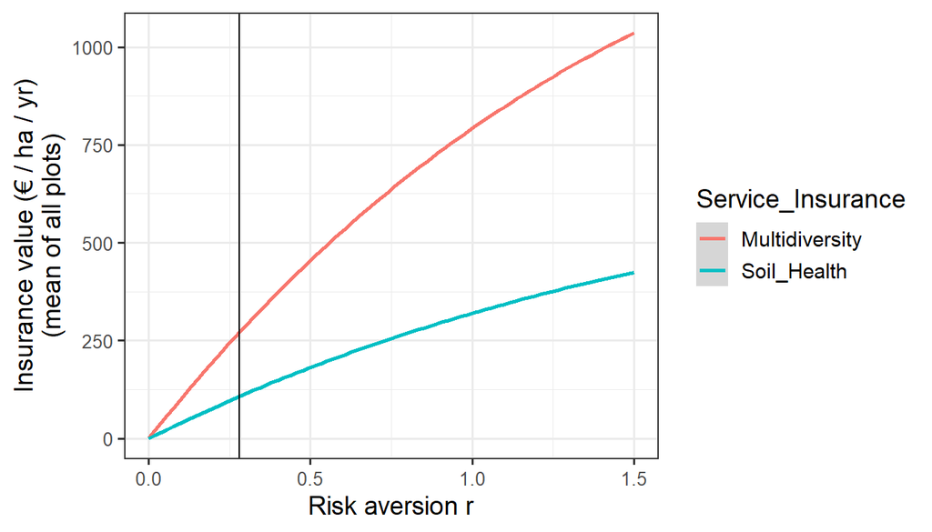

```r
Insurance_Sensitivity
```

```r
#write.csv(mf_data_lt, "Complete_dataset.csv")
```

Create correlation matrix with p values

```r
cor_variables <- c("Yield", "TOC", "Nmin_Surplus", "Mic_Bio", "CEL", "NAG", "PHO", "Decomp_Below",
                   "Decomp_Above_Fine", "Decomp_Above_Coarse", "Biodiv_Meso", "Biodiv_Macro",
                   "Biodiv_Nematode", "Percentage_FlowCov", "Multidiv", "Soil_Health", "egEMF_Farmers", "egEMF_Locals", "egEMF_Env", "egEMF_Tourism","enEMF", "enEMF_Farmers", "egEMF_Func", "egEMF_Serv")



cor_matrix <- matrix(NA, ncol = length(cor_variables), nrow = length(cor_variables))
p_values <- matrix(NA, ncol = length(cor_variables), nrow = length(cor_variables))

for (i in 1:length(cor_variables)) {
  for (j in 1:length(cor_variables)) {
    result <- cor.test(mf_data_lt[[cor_variables[i]]], mf_data_lt[[cor_variables[j]]])
    cor_matrix[i, j] <- result$estimate
    p_values[i, j] <- result$p.value
  }
}

colnames(cor_matrix) <- cor_variables
rownames(cor_matrix) <- cor_variables

colnames(p_values) <- cor_variables
rownames(p_values) <- cor_variables

p_values
```

```
##                            Yield          TOC Nmin_Surplus      Mic_Bio
## Yield               0.000000e+00 1.730236e-08 7.800144e-01 1.547984e-08
## TOC                 1.730236e-08 0.000000e+00 5.312424e-01 4.780776e-06
## Nmin_Surplus        7.800144e-01 5.312424e-01 0.000000e+00 2.571544e-02
## Mic_Bio             1.547984e-08 4.780776e-06 2.571544e-02 0.000000e+00
## CEL                 6.553802e-01 5.217907e-02 1.247933e-01 7.869542e-02
## NAG                 5.501997e-05 1.692712e-05 3.554881e-01 6.407511e-07
## PHO                 2.094541e-01 1.406755e-02 4.731209e-03 6.937788e-02
## Decomp_Below        6.592314e-02 4.065743e-01 8.104409e-04 7.031902e-01
## Decomp_Above_Fine   1.335401e-01 7.713815e-01 1.233284e-01 5.313980e-02
## Decomp_Above_Coarse 3.257279e-03 5.783263e-03 6.875705e-01 8.961447e-03
## Biodiv_Meso         8.716144e-03 1.726491e-01 1.944462e-01 7.133264e-03
## Biodiv_Macro        3.016214e-13 3.411139e-05 3.382282e-01 7.287722e-08
## Biodiv_Nematode     2.261141e-01 7.506511e-01 2.222849e-09 1.183638e-01
## Percentage_FlowCov  1.534482e-06 4.460984e-04 5.626544e-05 1.791762e-04
## Multidiv            1.114371e-10 6.094682e-04 9.877397e-02 3.956861e-05
## Soil_Health         3.514454e-06 2.909676e-05 3.928487e-02 1.335895e-13
## egEMF_Farmers       1.061822e-18 1.713646e-05 4.824216e-02 1.736888e-06
## egEMF_Locals        1.087358e-06 1.285634e-02 2.057026e-05 1.106354e-03
## egEMF_Env           6.480673e-01 3.668877e-01 3.653488e-09 8.161853e-01
## egEMF_Tourism       2.281325e-02 4.108573e-01 1.149142e-08 9.662105e-02
## enEMF               1.242360e-02 1.479399e-04 3.547125e-06 1.209887e-01
## enEMF_Farmers       7.157756e-33 1.353983e-07 7.260274e-01 3.011050e-06
## egEMF_Func          4.571522e-03 3.149296e-03 6.209501e-03 1.124761e-02
## egEMF_Serv          9.985689e-02 9.249621e-01 7.652649e-12 7.461948e-02
##                              CEL          NAG          PHO Decomp_Below
## Yield               6.553802e-01 5.501997e-05 2.094541e-01 0.0659231423
## TOC                 5.217907e-02 1.692712e-05 1.406755e-02 0.4065743146
## Nmin_Surplus        1.247933e-01 3.554881e-01 4.731209e-03 0.0008104409
## Mic_Bio             7.869542e-02 6.407511e-07 6.937788e-02 0.7031901730
## CEL                 0.000000e+00 4.934097e-08 3.444115e-09 0.8208651696
## NAG                 4.934097e-08 0.000000e+00 2.926254e-07 0.6448220727
## PHO                 3.444115e-09 2.926254e-07 0.000000e+00 0.4430467365
## Decomp_Below        8.208652e-01 6.448221e-01 4.430467e-01 0.0000000000
## Decomp_Above_Fine   9.781628e-01 1.381436e-01 1.321503e-01 0.3549681481
## Decomp_Above_Coarse 8.334318e-01 2.240812e-02 1.924989e-01 0.0945220098
## Biodiv_Meso         1.487848e-01 1.368501e-03 5.916272e-03 0.8691527361
## Biodiv_Macro        2.124386e-01 3.463474e-06 1.276719e-01 0.1581850311
## Biodiv_Nematode     3.010306e-01 2.598069e-01 3.920371e-02 0.0004978736
## Percentage_FlowCov  1.045608e-01 3.129847e-02 1.625307e-02 0.6603910677
```

[output cut: 120 more lines]

```
## Decomp_Above_Coarse 9.819570e-01 6.163268e-01
## Biodiv_Meso         5.018828e-03 3.394022e-01
## Biodiv_Macro        1.126973e-06 9.306606e-01
## Biodiv_Nematode     5.080562e-03 2.994418e-04
## Percentage_FlowCov  9.655647e-01 1.289854e-10
## Multidiv            6.487213e-09 4.886993e-01
## Soil_Health         6.215406e-08 2.998551e-01
## egEMF_Farmers       8.223361e-01 1.227618e-06
## egEMF_Locals        5.330820e-02 1.600371e-17
## egEMF_Env           2.158373e-09 7.751287e-28
## egEMF_Tourism       1.895910e-04 1.139012e-31
## enEMF               3.178064e-06 9.476417e-08
## enEMF_Farmers       1.338791e-01 4.022597e-02
## egEMF_Func          0.000000e+00 9.035023e-05
## egEMF_Serv          9.035023e-05 0.000000e+00
```

```r
cor_matrix
```

```
##                           Yield         TOC Nmin_Surplus     Mic_Bio
## Yield                1.00000000 -0.69824326   0.04050736 -0.69990570
## TOC                 -0.69824326  1.00000000   0.09065573  0.59678530
## Nmin_Surplus         0.04050736  0.09065573   1.00000000  0.31531827
## Mic_Bio             -0.69990570  0.59678530   0.31531827  1.00000000
## CEL                 -0.06468636  0.27620941   0.21997152  0.25101267
## NAG                 -0.53841544  0.56796442   0.13346262  0.63748825
## PHO                 -0.18059755  0.34524596   0.39320107  0.25896368
## Decomp_Below        -0.26212806  0.11998065  -0.45857343 -0.05524003
## Decomp_Above_Fine   -0.21512076  0.04214016   0.22080880  0.27513348
## Decomp_Above_Coarse  0.40814745 -0.38487354  -0.05829934 -0.36594584
## Biodiv_Meso         -0.36717817  0.19594258   0.18660267  0.37594197
## Biodiv_Macro        -0.82056656  0.55073836  -0.13828066  0.67571292
## Biodiv_Nematode     -0.17427485  0.04608270  -0.72718617 -0.22370347
## Percentage_FlowCov   0.62050318 -0.47806117  -0.53782646 -0.50576196
## Multidiv            -0.76371084  0.46801973  -0.23612009  0.54696444
## Soil_Health         -0.60339965  0.55473192   0.29248585  0.82712136
## egEMF_Farmers        0.89762029 -0.56767038  -0.28079359 -0.61800922
## egEMF_Locals         0.62732431 -0.34948493  -0.56326777 -0.44793850
## egEMF_Env            0.06615405  0.13035856  -0.72049605 -0.03371744
## egEMF_Tourism        0.32148467 -0.11889679  -0.70430104 -0.23759732
## enEMF               -0.35820661  0.52075360  -0.61348603  0.22686584
## enEMF_Farmers        0.97465544 -0.66536426   0.05080922 -0.60666745
## egEMF_Func          -0.39460432  0.40946473  -0.38187316  0.35567905
## egEMF_Serv           0.23538643  0.01366479  -0.79166786 -0.25439378
##                              CEL         NAG           PHO Decomp_Below
## Yield               -0.064686355 -0.53841544 -0.1805975473  -0.26212806
## TOC                  0.276209415  0.56796442  0.3452459636   0.11998065
## Nmin_Surplus         0.219971524  0.13346262  0.3932010650  -0.45857343
## Mic_Bio              0.251012674  0.63748825  0.2589636848  -0.05524003
## CEL                  1.000000000  0.68202391  0.7213008108  -0.03284447
## NAG                  0.682023912  1.00000000  0.6518998833   0.06680746
## PHO                  0.721300811  0.65189988  1.0000000000  -0.11094912
## Decomp_Below        -0.032844470  0.06680746 -0.1109491243   1.00000000
## Decomp_Above_Fine    0.003971464  0.21266297  0.2158752397   0.13360564
## Decomp_Above_Coarse -0.030505887 -0.32239724 -0.1874056442   0.23906234
## Biodiv_Meso          0.207206723  0.44047097  0.3839171220  -0.02389815
## Biodiv_Macro         0.179439726  0.60371008  0.2183476574   0.20262202
## Biodiv_Nematode     -0.149214885 -0.16240729 -0.2926013808   0.47456256
## Percentage_FlowCov  -0.232269097 -0.30493565 -0.3383293830  -0.06368439
```

[output cut: 120 more lines]

```
## Decomp_Above_Coarse  0.07260372
## Biodiv_Meso         -0.13794820
## Biodiv_Macro         0.01262442
## Biodiv_Nematode      0.49045685
## Percentage_FlowCov   0.76206458
## Multidiv             0.10020478
## Soil_Health         -0.14957413
## egEMF_Farmers        0.62494021
## egEMF_Locals         0.88464582
## egEMF_Env            0.95860806
## egEMF_Tourism        0.97151654
## enEMF                0.68191275
## enEMF_Farmers        0.29116029
## egEMF_Func           0.52510146
## egEMF_Serv           1.00000000
```

```r
write.csv(cor_matrix, "cor_matrix.csv")
write.csv(p_values, "cor_matrix_p_values.csv")
```